# **项目：化妆品电商用户行为分析**

## **1. 项目背景**

1. **数据来源**：项目数据来自公开数据集【 https://www.kaggle.com/datasets/mkechinov/ecommerce-events-history-in-cosmetics-shop/data 】
2. **数据背景**：数据来源于一家海外中型化妆品网店，包含5个月的用户行为数据共20692840条（2019年10月至2020年2月）
3. **分析目标**：运用探索性数据分析（EDA）方法，深入挖掘用户行为特征，精准识别数据异常模式，应用数据分析方法验证异常根因及其关联关系，并基于分析结果为网店运营优化提供数据支持与策略建议

## **2. 字段详解**

1. `event_time`：用户行为的发生时间（UTC 时间）
2. `event_type`：用户行为分类
   1. `view`：浏览产品
   2. `cart`：将产品添加到购物车
   3. `remove_from_cart`：从购物车中移除产品
   4. `purchase`：购买产品
3. `product_id`：产品 ID
4. `category_id`：产品类别 ID
5. `category_code`：产品类别
6. `brand`：品牌名称缩写
7. `price`：产品价格
8. `user_id`：用户ID
9. `user_session`：用户的临时会话ID（同一会话 ID 相同）

## **3. 总结与建议**

1. 用户倾向于关注14.61美元以内的低价产品，整体产品最高价格达到327.78美元，但价格分布上界仅14.61美元，建议网店将核心资源与运营精力聚焦于14.61美元以下的产品，以精准匹配用户需求，并将低价产品与相关的中、高价产品捆绑推荐，引导用户关注更高价格产品，从而提升客单价
2. 产品类别及品牌均表现出显著的头部集聚效应，产品类别受关注度与品牌受关注度均呈“三级阶梯+平滑长尾”的分布形态，上架新产品时建议优先上架头部品牌与头部类别产品
   1. 头部类别：1487580007675986893、1487580005092295511、1487580005595612013、1487580005671109489、1602943681873052386、1487580006317032337
   2. 头部品牌：runail、irisk、grattol、masura
3. 跨年前后一周用户行为总量跌入谷底，建议降低该时段推广投入以避免预算浪费，同时利用低峰期完成产品页面维护与更新，从而减少正常运营时段的维护成本
4. 大型活动开启前一个月适合开展预热活动，“2019年10月1日-12日”的加购行为能显著促进用户在“2019年11月20日-12月1日”的购买转化（2019年感恩节为11月28日、黑色星期五为11月29日）
5. 网店产品购物车移出率普遍偏高，主要归因于“用户批量清除购物车”与“受竞品影响放弃原产品”两大核心因素。针对前者，建议增加“批量删除”的二次确认或撤销功能，以降低误操作风险；针对后者，建议在用户加购时，智能展示产品的核心卖点或推送限时优惠，通过强化产品优势来增强用户快速购买意愿
6. 鉴于不同用户群体的关注点与需求存在显著差异，为精准触达用户并有效提升购买转化率，建议针对各类客户群体推荐最优产品。建议推荐清单如下：
   1. 没有过购买行为的客户：5809910、5700037、5802432、5809912、5854897
   2. 重要价值客户：5809910、5700037、5809912、5854897、5802432
   3. 一般价值客户：5809910、5700037、5802432、5854897、5815662
   4. 重要发展客户：5809910、5751422、5877454、5751383、5809912
   5. 一般发展客户：5809910、5809912、5790689、5700037、5809911
   6. 重要保持客户：5809910、5700037、5809912、5802432、5854897
   7. 一般保持客户：5809910、5802432、5700037、5815662、5854897
   8. 重要挽留客户：5809910、5877454、5751422、5856186、5751383
   9. 一般挽留客户：5809910、5809912、5809911、5751383、5649236

## **4. 分析思路**

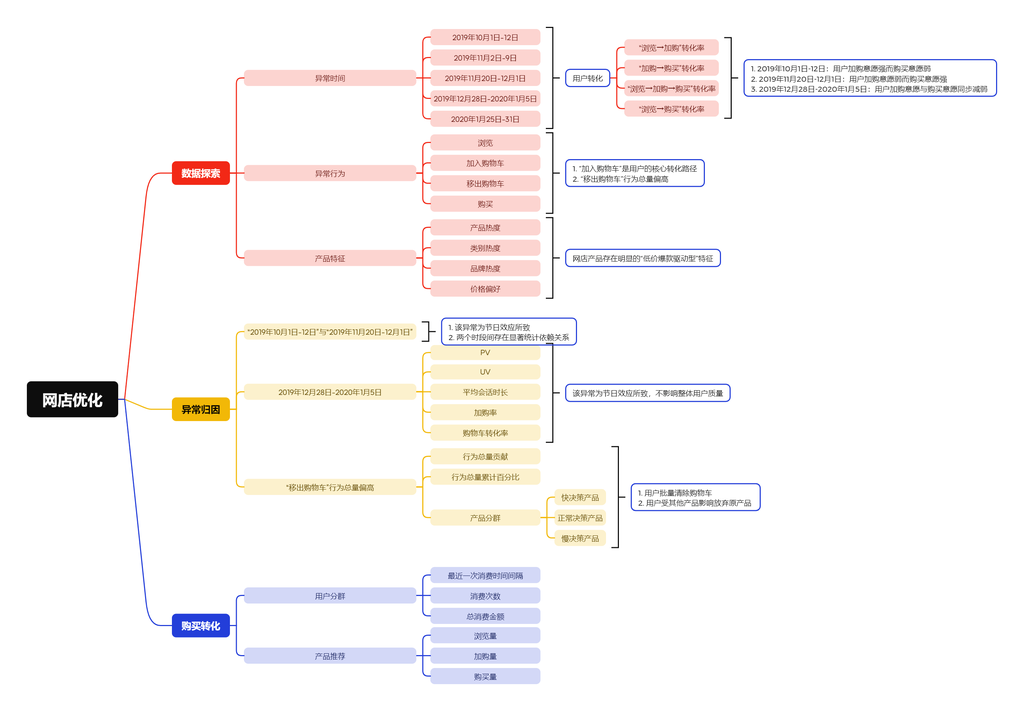

## **5. 数据预处理**

### **5.1 数据读取与整合**

```python
import numpy as np  # 用于计算
import pandas as pd  # 用于制表
import seaborn as sns  # 用于画图
import matplotlib.pyplot as plt  # 用于画图
from statsmodels.stats.proportion import proportions_ztest  # 用于z检验
```

```python
"""读取所有用户数据"""
data_2019_10 = pd.read_csv('2019-Oct.csv')  # 2019年10月-用户数据
data_2019_11 = pd.read_csv('2019-Nov.csv')  # 2019年11月-用户数据
data_2019_12 = pd.read_csv('2019-Dec.csv')  # 2019年12月-用户数据
data_2020_01 = pd.read_csv('2020-Jan.csv')  # 2020年1月-用户数据
data_2020_02 = pd.read_csv('2020-Feb.csv')  # 2020年2月-用户数据
"""将用户数据纵向拼接到一起"""
data_all = pd.concat([data_2019_10, data_2019_11, data_2019_12, data_2020_01, data_2020_02], axis=0, ignore_index=True)
data_all.tail()
```

|  | event_time | event_type | product_id | category_id | category_code | brand | price | user_id | user_session |
| --- | --- | --- | --- | --- | --- | --- | --- | --- | --- |
| 20692835 | 2020-02-29 23:59:32 UTC | view | 5885416 | 1487580005092295511 | NaN | grattol | 6.27 | 622082947 | fb29909b-6ef5-4662-b4ee-288e73e5dc10 |
| 20692836 | 2020-02-29 23:59:39 UTC | cart | 5550686 | 1487580008145748965 | NaN | NaN | 1.11 | 459705611 | 05d2add3-01f7-47ee-8364-27341673227f |
| 20692837 | 2020-02-29 23:59:45 UTC | view | 5850628 | 1602943681873052386 | NaN | grattol | 5.24 | 622090043 | ab7d349f-db5d-4790-8ab1-31e5c894459d |
| 20692838 | 2020-02-29 23:59:54 UTC | view | 5716351 | 1487580010872045658 | NaN | irisk | 0.79 | 619841242 | 18af673b-7fb9-4202-a66d-5c855bc0fd2d |
| 20692839 | 2020-02-29 23:59:59 UTC | view | 5927709 | 1487580013950664926 | NaN | de.lux | 3.17 | 621669991 | daa3c677-5360-4327-847e-d29658716b99 |

### **5.2 数据评估与清洗**

#### **5.2.1 数据整洁度探索与处理**

```python
"""备份数据"""
data_clean = data_all.copy()
"""数据总览"""
data_clean.info()
```

```
<class 'pandas.DataFrame'>
RangeIndex: 20692840 entries, 0 to 20692839
Data columns (total 9 columns):
 #   Column         Dtype
---  ------         -----
 0   event_time     str
 1   event_type     str
 2   product_id     int64
 3   category_id    int64
 4   category_code  str
 5   brand          str
 6   price          float64
 7   user_id        int64
 8   user_session   str
dtypes: float64(1), int64(3), str(5)
memory usage: 1.4 GB
```

**小结**：此数据集各字段数据类型存在问题，需更正数据类型

- `event_time`：
  - 现象：数据为字符串类型，且为`UTC`时间【如：2019-10-18 16:52:19 UTC】
  - 策略：更正数据类型，将该字段转换为`UTC`时间戳类型
- `event_type`：
  - 现象：数据为字符串类型
  - 策略：更正数据类型，将该字段转换为 category 类型
- `product_id`、`category_id`、`user_id`：
  - 现象：这几个字段为整数类型
  - 策略：这几个字段都是唯一标识符，不参与计算，所以将这些字段都转换为字符串类型

```python
"""更正数据类型"""
data_clean['event_time'] = pd.to_datetime(data_clean['event_time'], errors='coerce', utc=True)  #更改 event_time
data_clean['event_type'] = data_clean['event_type'].astype('category')  # 更改 event_type
data_clean['product_id'] = data_clean['product_id'].astype('str')  # 更改 product_id
data_clean['category_id'] = data_clean['category_id'].astype('str')  # 更改 category_id
data_clean['user_id'] = data_clean['user_id'].astype('str')  # 更改 category_id
data_clean.info()
```

```
<class 'pandas.DataFrame'>
RangeIndex: 20692840 entries, 0 to 20692839
Data columns (total 9 columns):
 #   Column         Dtype
---  ------         -----
 0   event_time     datetime64[us, UTC]
 1   event_type     category
 2   product_id     str
 3   category_id    str
 4   category_code  str
 5   brand          str
 6   price          float64
 7   user_id        str
 8   user_session   str
dtypes: category(1), datetime64[us, UTC](1), float64(1), str(6)
memory usage: 1.3 GB
```

#### **5.2.2 数据干净度探索与处理**

##### **5.2.2.1 数据总览**

```python
"""查看数据表数值列统计信息"""
data_clean.describe()
```

|  | price |
| --- | --- |
| count | 2.069284e+07 |
| mean | 8.534735e+00 |
| std | 1.938142e+01 |
| min | -7.937000e+01 |
| 25% | 2.060000e+00 |
| 50% | 4.050000e+00 |
| 75% | 7.060000e+00 |
| max | 3.277800e+02 |

**小结**：

1. 现象：价格列最小值为负值
2. 策略：考虑到电商场景中不可能存在价格为0的产品供用户选购，因此判断其为异常数据，将所在行剔除

```python
"""剔除小于等于0的异常值"""
data_clean = data_clean[data_clean['price'] > 0]
data_clean.describe()
```

|  | price |
| --- | --- |
| count | 2.058855e+07 |
| mean | 8.578162e+00 |
| std | 1.942060e+01 |
| min | 5.000000e-02 |
| 25% | 2.060000e+00 |
| 50% | 4.110000e+00 |
| 75% | 7.140000e+00 |
| max | 3.277800e+02 |

##### **5.2.2.2 检查字段丢失情况**

```python
"""检查各字段数据丢失情况"""
print('event_time 字段丢失数据数：', data_clean['event_time'].isnull().sum())
print('event_type 字段丢失数据数：', data_clean['event_type'].isnull().sum())
print('product_id 字段丢失数据数：', data_clean['product_id'].isnull().sum())
print('category_id 字段丢失数据数：', data_clean['category_id'].isnull().sum())
print('category_code 字段丢失数据数：', data_clean['category_code'].isnull().sum())
print('brand 字段丢失数据数：', data_clean['brand'].isnull().sum())
print('price 字段丢失数据数：', data_clean['price'].isnull().sum())
print('user_id 字段丢失数据数：', data_clean['user_id'].isnull().sum())
print('user_session 字段丢失数据数：', data_clean['user_session'].isnull().sum())
```

```
event_time 字段丢失数据数： 0
event_type 字段丢失数据数： 0
product_id 字段丢失数据数： 0
category_id 字段丢失数据数： 0
category_code 字段丢失数据数： 20236422
brand 字段丢失数据数： 8652850
price 字段丢失数据数： 0
user_id 字段丢失数据数： 0
user_session 字段丢失数据数： 4597
```

**小结**：

```python
"""处理缺失数据"""
data_clean = data_clean.drop('category_code', axis=1)  # 删除 category_code 字段
data_clean['brand'] = data_clean['brand'].fillna('unknown')  # 为 brand 字段中的空值填充 unknown
data_clean = data_clean.dropna(subset=["user_session"])  # 删除缺失 user_session 字段的行
data_clean.isnull().sum()
```

```
event_time      0
event_type      0
product_id      0
category_id     0
brand           0
price           0
user_id         0
user_session    0
dtype: int64
```

##### **5.2.2.3 检查重复行**

```python
"""检查数据中是否存在重复行"""
data_clean.duplicated(subset=["event_time","event_type","product_id","category_id","brand","price","user_id","user_session"]).sum()
```

```
np.int64(1090747)
```

**小结**：

- 现象：该数据集中存在重复行的行数为 1090747
- 策略：删除多次重复的行

```python
"""删除重复行"""
data_clean = data_clean.drop_duplicates()
data_clean.duplicated(subset=["event_time","event_type","product_id","category_id","brand","price","user_id","user_session"]).sum()
```

```
np.int64(0)
```

### **5.3 特征扩展**

为方便后续分析，从 event_time 字段扩展出‘年、月、日、周’四大特征

```python
"""特征扩展"""
data_clean['year'] = data_clean['event_time'].dt.year  # 年
data_clean['month'] = data_clean['event_time'].dt.month # 月
data_clean['day'] = data_clean['event_time'].dt.day  # 日
data_clean['week'] = data_clean['event_time'].dt.isocalendar().week  # 周【一年中的第几个周】
data_clean.head()
```

|  | event_time | event_type | product_id | category_id | brand | price | user_id | user_session | year | month | day | week |
| --- | --- | --- | --- | --- | --- | --- | --- | --- | --- | --- | --- | --- |
| 0 | 2019-10-01 00:00:00+00:00 | cart | 5773203 | 1487580005134238553 | runail | 2.62 | 463240011 | 26dd6e6e-4dac-4778-8d2c-92e149dab885 | 2019 | 10 | 1 | 40 |
| 1 | 2019-10-01 00:00:03+00:00 | cart | 5773353 | 1487580005134238553 | runail | 2.62 | 463240011 | 26dd6e6e-4dac-4778-8d2c-92e149dab885 | 2019 | 10 | 1 | 40 |
| 2 | 2019-10-01 00:00:07+00:00 | cart | 5881589 | 2151191071051219817 | lovely | 13.48 | 429681830 | 49e8d843-adf3-428b-a2c3-fe8bc6a307c9 | 2019 | 10 | 1 | 40 |
| 3 | 2019-10-01 00:00:07+00:00 | cart | 5723490 | 1487580005134238553 | runail | 2.62 | 463240011 | 26dd6e6e-4dac-4778-8d2c-92e149dab885 | 2019 | 10 | 1 | 40 |
| 4 | 2019-10-01 00:00:15+00:00 | cart | 5881449 | 1487580013522845895 | lovely | 0.56 | 429681830 | 49e8d843-adf3-428b-a2c3-fe8bc6a307c9 | 2019 | 10 | 1 | 40 |

## **6 数据探索**

### **6.1 数据备份与图表格式设定**

```python
"""定义图表格式"""
plt.rcParams['font.sans-serif'] = ['SimHei']  # 黑体
plt.rcParams['axes.unicode_minus'] = False
```

```python
"""备份清洗后的数据"""
data_explore = data_clean.copy()
data_explore.head()
```

|  | event_time | event_type | product_id | category_id | brand | price | user_id | user_session | year | month | day | week |
| --- | --- | --- | --- | --- | --- | --- | --- | --- | --- | --- | --- | --- |
| 0 | 2019-10-01 00:00:00+00:00 | cart | 5773203 | 1487580005134238553 | runail | 2.62 | 463240011 | 26dd6e6e-4dac-4778-8d2c-92e149dab885 | 2019 | 10 | 1 | 40 |
| 1 | 2019-10-01 00:00:03+00:00 | cart | 5773353 | 1487580005134238553 | runail | 2.62 | 463240011 | 26dd6e6e-4dac-4778-8d2c-92e149dab885 | 2019 | 10 | 1 | 40 |
| 2 | 2019-10-01 00:00:07+00:00 | cart | 5881589 | 2151191071051219817 | lovely | 13.48 | 429681830 | 49e8d843-adf3-428b-a2c3-fe8bc6a307c9 | 2019 | 10 | 1 | 40 |
| 3 | 2019-10-01 00:00:07+00:00 | cart | 5723490 | 1487580005134238553 | runail | 2.62 | 463240011 | 26dd6e6e-4dac-4778-8d2c-92e149dab885 | 2019 | 10 | 1 | 40 |
| 4 | 2019-10-01 00:00:15+00:00 | cart | 5881449 | 1487580013522845895 | lovely | 0.56 | 429681830 | 49e8d843-adf3-428b-a2c3-fe8bc6a307c9 | 2019 | 10 | 1 | 40 |

### **6.2 event_time**：统计不同时间段内用户行为总量变化，定位行为总量异常时段

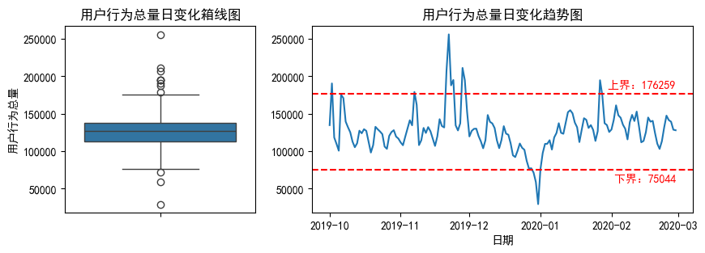

|  | 异常日期 | 行为总量 |
| --- | --- | --- |
| 1 | 2019-10-02 | 190394 |
| 37 | 2019-11-07 | 179027 |
| 51 | 2019-11-21 | 206923 |
| 52 | 2019-11-22 | 255819 |
| 53 | 2019-11-23 | 187847 |
| 54 | 2019-11-24 | 194971 |
| 58 | 2019-11-28 | 211062 |
| 59 | 2019-11-29 | 194763 |
| 89 | 2019-12-29 | 71500 |
| 90 | 2019-12-30 | 58878 |
| 91 | 2019-12-31 | 29426 |
| 118 | 2020-01-27 | 194647 |

```python
"""日行为总量"""
day_event = data_explore.groupby(["year", "month", "day"])["event_time"].count()  # 每日行为总量
day_event = day_event.reset_index()  # 重置索引，得到“年+月+日”
day_event["date"] = day_event["year"].astype('str').str.cat(day_event[["month", "day"]].astype('str'), sep="-")  # 合并“年+月+日”，得到日期字符串
day_event["date"] = day_event["date"].astype("datetime64[ns]")  # 将日期字符串构造成日期类型
"""计算日行为总量的上界和下界"""
day_event_q1 = day_event["event_time"].quantile(0.25)  # 第一四分位数
day_event_q3 = day_event["event_time"].quantile(0.75)  # 第三四分位数
day_event_iqr = day_event_q3 - day_event_q1  # 四分位距
day_event_upper = day_event_q3 + 1.5 * day_event_iqr  # 上界
day_event_lower = day_event_q1 - 1.5 * day_event_iqr  # 下界

"""图表绘制"""
fig, axes = plt.subplots(1, 2, figsize=(10,3), gridspec_kw={"width_ratios":[1,2]}) # 子图图框
sns.boxplot(day_event, y='event_time', ax=axes[0])  # 日行为总量箱线图
day_event_axes = sns.lineplot(day_event, x='date', y='event_time', ax=axes[1])  # 日行为总量折线图
"""绘制日行为总量界限"""
day_event_axes.axhline(y=day_event_upper, linestyle='--', color='red')  # 绘制上界
day_event_axes.axhline(y=day_event_lower, linestyle='--', color='red')  # 绘制下界
day_event_axes.text(day_event["date"].iloc[-1], day_event_upper+8000, f" 上界：{day_event_upper:.0f}", color='red', ha='right')  # 上界线标注
day_event_axes.text(day_event["date"].iloc[-1], day_event_lower-16000, f" 下界：{day_event_lower:.0f}", color='red', ha='right')  # 下界线标注
"""图表标签设置"""
axes[0].set_title("用户行为总量日变化箱线图")
axes[0].set_xlabel("")
axes[0].set_ylabel("用户行为总量")
axes[1].set_title("用户行为总量日变化趋势图")
axes[1].set_xlabel("日期")
axes[1].set_ylabel("")
plt.show()
"""用户行为总量日变化异常数据定位"""
day_event[(day_event["event_time"] > day_event_upper) | (day_event["event_time"] < day_event_lower)][["date", "event_time"]].rename(columns={"date":"异常日期","event_time":"行为总量"})
```

**小结**：

1. **2019年10月1日-12日**：用户行为总量波动较大，总体呈双峰分布形态，其中“10月2日”用户行为总量突破正常区间上界
2. **2019年11月2日-9日**：用户行为总量异常增大，总体呈单峰分布形态，其中“11月7日”用户行为总量突破正常区间上界
3. **2019年11月20日-12月1日**：用户行为总量波动较大，总体呈双峰分布形态，其中“2019年11月21日-24日”与“2019年11月28日-29日”期间用户行为总量突破正常区间上界
4. **2019年12月28日-2020年1月5日**：用户行为总量异常降低，总体呈U形分布形态，其中“2019年12月29日-31日”用户行为总量突破正常区间下界，“2019年12月31日”达到用户行为总量最低谷
5. **2020年1月25日-31日**：用户行为总量异常增大，总体呈单峰分布形态，其中“1月27日”用户行为总量突破正常区间上界

### **6.3 event_type**：统计不同行为的总量占比，定位异常行为

```python
"""计算各种用户行为占比的函数"""
def view_cart_remove_purchase_rate(event_data):
    """
    输入数据：
        event_data：用户行为数据
    输出数据：
        event_counts：每个行为的总数据量
        view_rate：浏览行为占比
        cart_rate：加入购物车行为占比
        remove_from_cart_rate：移出购物车行为占比
        purchase_rate：购买行为占比
    """
    event_counts = event_data["event_type"].value_counts()  # 统计每个行为类别的总数据量
    all_counts = event_counts.sum()  # 统计所有行为的总数据量
    view_rate = event_counts.loc["view"] / all_counts * 100  # 浏览行为占比
    cart_rate = event_counts.loc["cart"] / all_counts * 100  # 加入购物车行为占比
    remove_from_cart_rate = event_counts.loc["remove_from_cart"] / all_counts * 100  # 移出购物车行为占比
    purchase_rate = event_counts.loc["purchase"] / all_counts * 100  # 购买行为占比
    return event_counts, view_rate, cart_rate, remove_from_cart_rate, purchase_rate
```

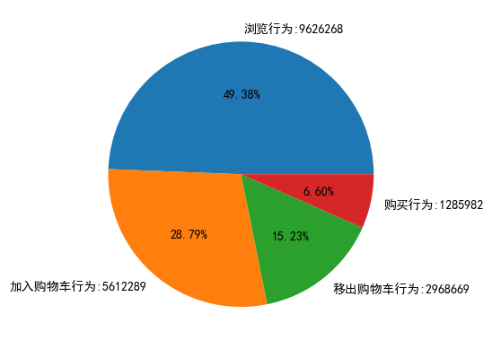

```python
"""每个行为类别的占比"""
event_counts, view_rate, cart_rate, remove_from_cart_rate, purchase_rate = view_cart_remove_purchase_rate(data_explore)  # 计算每种用户行为的占比
plt.pie([view_rate, cart_rate, remove_from_cart_rate, purchase_rate], labels=[f"浏览行为:{event_counts.loc['view']}",f"加入购物车行为:{event_counts.loc['cart']}",f"移出购物车行为:{event_counts.loc['remove_from_cart']}",f"购买行为:{event_counts.loc['purchase']}"], autopct="%.2f%%")
plt.show()
```

**小结**：

1. 加入购物车占比偏高，浏览行为总量9626268，加入购物车行为总量5612289，浏览行为与加入购物车行为比值为1.72:1
2. 移出购物车行为总量占比偏高，加入购物车行为总量5612289，移出购物车行为总量2968669，加入购物车行为与移出购物车行为的比值为1.89:1

### **6.4 product_id**：统计产品ID的行为频次，探索产品受关注度

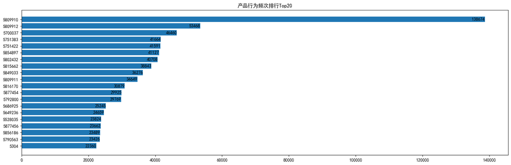

```python
"""用户对各产品ID的行为频次"""
product_count = data_explore["product_id"].value_counts()  # 各产品ID的行为频次
product_count = product_count.reset_index()  # 重置索引，拆出产品ID
"""绘制箱型图"""
"""取行为频次最高的前20个产品绘制横向条形图"""
fig, axes = plt.subplots(1,1, figsize=(20,6))
axes.barh(product_count.iloc[:20]["product_id"][::-1], product_count.iloc[:20]["count"][::-1])
axes.set_title("产品行为频次排行Top20")
for i,j in zip(product_count.iloc[:20]["product_id"], product_count.iloc[:20]["count"]):
    axes.text(j, i, str(j), va='center', ha='right')
plt.show()
```

**小结**：产品头部效应显著，行为频次最高的产品为“5809910”（频次为“138674”），该产品行为频次为排行第二的产品“5809912”（频次为“53468”）的2.59倍

### **6.5 category_id**：统计产品类别ID的行为频次，探索产品类别受关注度

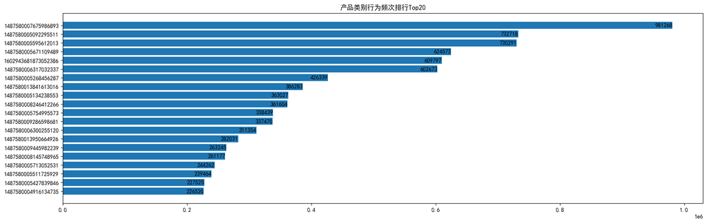

```python
"""用户对各产品类别ID的行为频次"""
category_count = data_explore["category_id"].value_counts()  # 各产品类别ID的行为频次
category_count = category_count.reset_index()  # 重置索引，拆出产品类别ID
"""取行为频次最高的前20个产品类别横向条形图"""
fig, axes = plt.subplots(1,1, figsize=(20,6))
axes.barh(category_count.iloc[:20]["category_id"][::-1], category_count.iloc[:20]["count"][::-1])
axes.set_title("产品类别行为频次排行Top20")
for i,j in zip(category_count.iloc[:20]["category_id"], category_count.iloc[:20]["count"]):
    axes.text(j, i, str(j), va='center', ha='right')
plt.show()
```

**小结**：产品类别行为频次呈“三级阶梯+平滑长尾”的分布形态，其中三级阶梯之间落差显著、各自独立成层：

1. 一级阶梯包含“1487580007675986893（行为频次981268）”，其行为频次是二级阶梯最高频次（732718）的1.34倍
2. 二级阶梯包含“1487580005092295511（行为频次732718）”、“1487580005595612013（行为频次730291）”，最低频次是三级阶梯最高频次（624573）的1.17倍
3. 三级阶梯包含“1487580005671109489（行为频次624573）”、“1602943681873052386（行为频次609797）”、“1487580006317032337（行为频次602673）”，最低频次是剩余数据最高频次（426339）的1.41倍

### **6.6 brand**：统计品牌的行为频次，探索品牌受关注度【unknown为未知品牌配件总和，不计入频次排行】

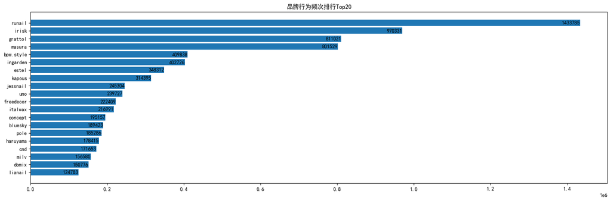

```python
"""用户对各品牌产品的行为频次"""
brand_count = data_explore["brand"].value_counts()  # 各品牌的行为频次
brand_count = brand_count.reset_index()  # 重置索引，拆出品牌
brand_count = brand_count.drop(0)  # 删除未知品牌“unknown”
"""取行为频次最高的前20个品牌绘制横向条形图"""
fig, axes = plt.subplots(1,1, figsize=(20,6))
axes.barh(brand_count.iloc[:20]["brand"][::-1], brand_count.iloc[:20]["count"][::-1])
axes.set_title("品牌行为频次排行Top20")
for i,j in zip(brand_count.iloc[:20]["brand"], brand_count.iloc[:20]["count"]):
    axes.text(j, i, str(j), va='center', ha='right')
plt.show()
```

**小结**：品牌行为频次也呈“三级阶梯+平滑长尾”的分布形态，三级阶梯之间落差显著、各自独立成层：

1. 一级阶梯仅包含“runail（行为频次1433785）”一个品牌，其频次是二级阶梯最高频次（970331）的1.48倍
2. 二级阶梯也仅包含“irisk（行为频次970331）”一个品牌，其频次是三级阶梯最高频次（811021）的1.20倍
3. 三级阶梯包含“grattol（行为频次811021）”、“masura（行为频次801529）”两个品牌，其中最低频次仍是剩余数据最高频次（409838）的1.96倍

### **6.7 price**：统计价格信息，探索用户价格偏好

```python
"""查看所有行为涉及价格的统计数据"""
data_explore["price"].describe()
```

```
count    1.949321e+07
mean     8.779015e+00
std      1.979928e+01
min      5.000000e-02
25%      2.160000e+00
50%      4.130000e+00
75%      7.140000e+00
max      3.277800e+02
Name: price, dtype: float64
```

```python
"""计算‘上界’"""
# 上界
price_upper = data_explore["price"].describe().loc["75%"] + 1.5 * (data_explore["price"].describe().loc["75%"] - data_explore["price"].describe().loc["25%"])
```

[output not shown]

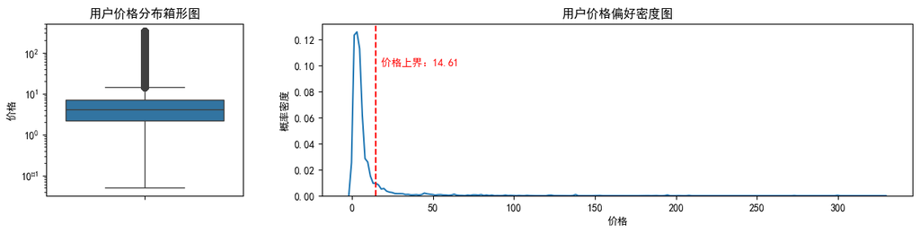

```python
"""绘制密度图，直观展示用户价格偏好"""
fig, axes = plt.subplots(1,2,figsize=(15,3),gridspec_kw={'width_ratios':[1, 3]})  # 子图图框
sns.boxplot(data_explore["price"], ax=axes[0])  # 箱形图
axes[0].set_yscale("log")  # 将箱形图的刻度改成对数形式
axes[0].set_title("用户价格分布箱形图")
axes[0].set_ylabel("价格")
sns.kdeplot(data_explore["price"], ax=axes[1])  # 密度图
axes[1].axvline(x=price_upper, linestyle='--', color='red', linewidth=1.5)  # 绘制上界竖线
axes[1].set_xlabel("价格")
axes[1].set_ylabel("概率密度")
axes[1].set_title("用户价格偏好密度图")
axes[1].text(price_upper, 0.10, f" 价格上界：{price_upper}", color='red')
plt.show()
```

**小结**：价格分布严重右偏，最高价格达到327.78美元，但价格分布上界仅14.61美元，意味着更多用户关注小于14.61美元的低价产品

### **6.8 event_time+user_id+event_type**：查看不同时段用户转化情况，定位核心异常区间

#### **6.8.1 “浏览→加购”转化率**

```python
"""根据传入的用户行为数据，自动计算“浏览→加购”转化率"""
def view_cart_rate_def(users_event):
    """
    输入数据：
        users_event：用户行为数据
    输出数据：
        view_users_sum：总浏览用户数
        first_cart_df_index：每个用户对每个产品的第一次加入购物车时间
        view_cart_users：存在对单个产品先‘浏览’后‘加购’行为的用户
        view_cart_users_sum：存在对单个产品先‘浏览’后‘加购’行为的用户总数
        view_cart_rate：‘浏览→加购’转化率
    """
    # 所有‘浏览’事件
    view_event = users_event[users_event['event_type'] == 'view']
    # 所有‘加购’事件
    cart_event = users_event[users_event['event_type'] == 'cart']
    # 总浏览用户数
    view_users_sum = view_event['user_id'].nunique()
    # 同一用户对同一产品的第一次浏览时间
    first_view = view_event.groupby(["user_id", "product_id"])["event_time"].min()  # 按‘用户ID+产品ID’联合分组，拿到每个用户对每个产品的第一次浏览时间
    first_view_df = first_view.reset_index()  # 重置 first_view 索引，拆出用户ID和产品ID
    first_view_df = first_view_df.rename(columns={"event_time":"first_view_time"})  # 更正列索引
    # 同一用户对同一产品的第一次加入购物车时间
    first_cart = cart_event.groupby(["user_id", "product_id"])["event_time"].min()  # 按‘用户ID+产品ID’联合分组，拿到每个用户对每个产品的第一次加入购物车时间
    first_cart_df = first_cart.reset_index()  # 重置 first_cart 索引，拆出用户ID和产品ID
    first_cart_df = first_cart_df.rename(columns={"event_time":"first_cart_time"})  # 更正列索引
    # 存在对单个产品先‘浏览’后‘加购’行为的用户总数
    first_view_df_index = first_view_df.set_index(['user_id','product_id'])  # 设置'用户ID'与'产品ID'两列为 first_view_df 的索引
    first_cart_df_index = first_cart_df.set_index(['user_id','product_id'])  # 设置'用户ID'与'产品ID'两列为 first_cart_df 的索引
    view_cart_event = first_view_df_index.join(first_cart_df_index, how='inner')  # 内连接，将‘第一次浏览’与‘第一次加入购物车’的行为合并到一起
    view_cart_event = view_cart_event.reset_index()  # 重置 view_cart_event 索引，拆出用户ID和产品ID
    view_cart_event = view_cart_event[view_cart_event["first_view_time"] < view_cart_event["first_cart_time"]]  # 筛选出所有先浏览后加购的行为
    view_cart_users = view_cart_event["user_id"].unique()  # 存在对单个产品先‘浏览’后‘加购’行为的用户
    view_cart_users_sum = len(view_cart_users)  # 存在对单个产品先‘浏览’后‘加购’行为的用户总数
    # ‘浏览→加购’转化率 = 存在先浏览后加购行为的用户数 / 总浏览用户数 * 100%
    view_cart_rate = view_cart_users_sum / view_users_sum * 100
    # 返回计算结果
    return view_users_sum, first_cart_df_index, view_cart_users, view_cart_users_sum, view_cart_rate
```

#### **6.8.2 “加购→购买”转化率**“”

```python
"""根据传入的用户行为数据，自动计算“加购→购买”转化率"""
def cart_purchase_rate_def(users_event, first_cart_df_index, view_cart_users):
    """
    输入数据：
        users_event：用户行为数据
        first_cart_df_index：每个用户对每个产品的第一次加入购物车时间
        view_cart_users：拥有过‘先浏览后加购’行为的用户的用户ID
    输出数据：
        cart_purchase_users：存在对单个产品先‘加购’后‘购买’行为的用户
        cart_purchase_users_sum：存在对单个产品先‘加购’后‘购买’行为的用户总数
        cart_purchase_rate：‘加购→购买’转化率
    """
    # 所有‘购买’事件
    purchase_event = users_event[users_event['event_type'] == 'purchase']
    # 有过‘浏览后加购’行为的用户的所有购买行为
    view_cart_purchase_event = purchase_event[purchase_event["user_id"].isin(view_cart_users)]
    # 有过‘浏览后加购’行为的用户的第一次购买时间
    first_purchase = view_cart_purchase_event.groupby(["user_id", "product_id"])["event_time"].min()  # 按‘用户ID+产品ID’联合分组，拿到每个用户对每个产品的第一次购买时间
    first_purchase_df = first_purchase.reset_index()  # 重置 first_purchase 索引，拆出用户ID和产品ID
    first_purchase_df = first_purchase_df.rename(columns={"event_time":"first_purchase_time"})  # 更正列索引
    # 存在对单个产品先‘加购’后‘购买’行为的用户总数
    first_purchase_df_index = first_purchase_df.set_index(['user_id','product_id'])  # 设置'用户ID'与'产品ID'两列为 first_purchase_df 的索引
    cart_purchase_event = first_cart_df_index.join(first_purchase_df_index, how='inner')  # 内连接，将‘第一次加入购物车’与‘第一次购买’的行为合并到一起
    cart_purchase_event = cart_purchase_event.reset_index()  # 重置 cart_purchase_event 索引，拆出用户ID和产品ID
    cart_purchase_event = cart_purchase_event[cart_purchase_event["first_cart_time"] < cart_purchase_event["first_purchase_time"]]  # 筛选出所有先加购后购买的行为
    cart_purchase_users = cart_purchase_event["user_id"].unique()  # 存在对单个产品先‘加购’后‘购买’行为的用户
    cart_purchase_users_sum = len(cart_purchase_users)  # 存在对单个产品先‘加购’后‘购买’行为的用户总数
    # ‘加购→购买’转化率 = 加购后购买用户数 / 浏览后加购用户数 * 100%
    cart_purchase_rate = cart_purchase_users_sum / len(view_cart_users) * 100
    # 返回计算结果
    return cart_purchase_users, cart_purchase_users_sum, cart_purchase_rate
```

#### **6.8.3 “浏览→加购→购买”转化率**

```python
"""传入“对单个产品存在先浏览后加购最终购买的行为的用户数”和“总浏览用户数”，自动计算“浏览→加购→购买”转化率"""
def view_cart_purchase_rate_def(cart_purchase_users_sum, view_users_sum):
    """
    输入数据：
        cart_purchase_users_sum：存在对单个产品先‘浏览’后‘加购’最后‘购买’行为的用户总数
        view_users_sum：总浏览用户数
    输出数据：
        view_cart_purchase_rate：“浏览→加购→购买”转化率
    """
    # “浏览→加购→购买”转化率 = 存在对单个产品先‘浏览’后‘加购’最后‘购买’行为的用户总数 / 总浏览用户数 * 100%
    view_cart_purchase_rate = cart_purchase_users_sum / view_users_sum * 100
    # 返回计算结果
    return view_cart_purchase_rate
```

#### **6.8.4 “浏览→购买”转化率**

```python
"""根据传入的用户行为数据，自动计算“浏览→购买”转化率"""
def view_purchase_rate_def(users_event, cart_purchase_users):
    """
    输入数据：
        users_event：用户行为数据
        cart_purchase_users：存在对单个产品先‘加购’后‘购买’行为的用户
    输出数据：
        view_purchase_users_sum：存在对单个产品先‘浏览’后直接‘购买’行为的用户总数
        view_purchase_rate：‘浏览→购买’转化率
    """
    # 所有‘浏览’事件
    view_event = users_event[users_event['event_type'] == 'view']
    # 所有‘购买’事件
    purchase_event = users_event[users_event['event_type'] == 'purchase']
    # 全部有‘浏览’行为的用户总数
    view_users_sum = view_event['user_id'].nunique()
    # 有购买行为的用户中，没有‘加购后购买’行为的用户的所有购买行为数据
    not_cart_purchase_users_event = purchase_event[~purchase_event["user_id"].isin(cart_purchase_users)]
    # 非‘加购后购买’的有‘购买’行为的用户对每个产品的的第一次购买时间
    first_purchase = not_cart_purchase_users_event.groupby(["user_id", "product_id"])["event_time"].min()  # 按‘用户ID+产品ID’联合分组，非‘浏览后购买’的有‘购买’行为的用户对每个产品的第一次购买时间
    first_purchase_df = first_purchase.reset_index()  # 重置 first_view_purchase 索引，拆出用户ID和产品ID
    first_purchase_df = first_purchase_df.rename(columns={"event_time":"first_purchase_time"})  # 更正列索引
    # 有购买行为的用户中，没有‘加购后购买’行为的用户【直接购买，不加购物车的用户】
    not_cart_purchase_users = not_cart_purchase_users_event["user_id"].unique()
    # 非‘加购后购买’的有‘购买’行为的用户的所有浏览行为数据
    not_cart_purchase_users_view = view_event[view_event["user_id"].isin(not_cart_purchase_users)]
    # 非‘加购后购买’的有‘购买’行为的用户的第一次浏览时间
    first_view = not_cart_purchase_users_view.groupby(["user_id", "product_id"])["event_time"].min()  # 按‘用户ID+产品ID’联合分组，非‘浏览后加购’的有‘加购’行为的用户对每个产品的第一次浏览时间
    first_view_df = first_view.reset_index()  # 重置 first_purchase 索引，拆出用户ID和产品ID
    first_view_df = first_view_df.rename(columns={"event_time":"first_view_time"})  # 更正列索引
    # 存在对单个产品先‘浏览’后直接‘购买’行为的用户总数
    first_purchase_df_index = first_purchase_df.set_index(['user_id','product_id'])  # 设置'用户ID'与'产品ID'两列为 first_purchase_df 的索引
    first_view_df_index = first_view_df.set_index(['user_id','product_id'])  # 设置'用户ID'与'产品ID'两列为 first_view_df 的索引
    view_purchase_event = first_view_df_index.join(first_purchase_df_index, how='inner')  # 内连接，将‘第一次浏览’与‘第一次购买’的行为合并到一起
    view_purchase_event = view_purchase_event.reset_index()  # 重置 view_purchase_event 索引，拆出用户ID和产品ID
    view_purchase_event = view_purchase_event[view_purchase_event["first_view_time"] < view_purchase_event["first_purchase_time"]]  # 筛选出所有浏览后直接购买的行为
    view_purchase_users = view_purchase_event["user_id"].unique()  # 拥有过‘浏览后直接购买’行为的用户
    view_purchase_users_sum = len(view_purchase_users)  # 拥有过‘浏览后直接购买’行为的用户总数
    # ‘浏览→购买’转化率 = 浏览后直接购买的用户数 / 总浏览用户数 * 100%
    view_purchase_rate = view_purchase_users_sum / view_users_sum * 100
    # 返回计算结果
    return view_purchase_users_sum, view_purchase_rate
```

#### **6.8.5 用户转化率计算**

```python
"""总体用户转化率计算"""
# 【data_explore：全部用户行为数据】
view_users_sum_all, first_cart_df_index_all, view_cart_users_all, view_cart_users_sum_all, view_cart_rate_all = view_cart_rate_def(data_explore)
cart_purchase_users_all, cart_purchase_users_sum_all, cart_purchase_rate_all = cart_purchase_rate_def(data_explore, first_cart_df_index_all, view_cart_users_all)
view_cart_purchase_rate_all = view_cart_purchase_rate_def(cart_purchase_users_sum_all, view_users_sum_all)
view_purchase_users_sum_all, view_purchase_rate_all = view_purchase_rate_def(data_explore, cart_purchase_users_all)
print(
f"""浏览人数：{view_users_sum_all}，加购人数：{view_cart_users_sum_all}，购买人数：{cart_purchase_users_sum_all}
“浏览→加购”转化率：{view_cart_rate_all:.2f}%
“加购→购买”转化率：{cart_purchase_rate_all:.2f}%
“浏览→加购→购买”转化率：{view_cart_purchase_rate_all:.2f}%
“浏览→购买”转化率：{view_purchase_rate_all:.2f}%"""
)
```

```
浏览人数：1596359，加购人数：274651，购买人数：91084
“浏览→加购”转化率：17.20%
“加购→购买”转化率：33.16%
“浏览→加购→购买”转化率：5.71%
“浏览→购买”转化率：0.43%
```

```python
"""2019年10月1日-12日所有用户行为"""
users_event_10_1_12 = data_explore[(data_explore["event_time"] >= pd.to_datetime("2019-10-1", utc=True)) & (data_explore["event_time"] < pd.to_datetime("2019-10-13", utc=True))]  # 所有用户行为
"""2019年10月1日-12日用户转化率计算"""
view_users_sum_10_1_12, first_cart_df_index_10_1_12, view_cart_users_10_1_12, view_cart_users_sum_10_1_12, view_cart_rate_10_1_12 = view_cart_rate_def(users_event_10_1_12)
cart_purchase_users_10_1_12, cart_purchase_users_sum_10_1_12, cart_purchase_rate_10_1_12 = cart_purchase_rate_def(users_event_10_1_12, first_cart_df_index_10_1_12, view_cart_users_10_1_12)
view_cart_purchase_rate_10_1_12 = view_cart_purchase_rate_def(cart_purchase_users_sum_10_1_12, view_users_sum_10_1_12)
view_purchase_users_sum_10_1_12, view_purchase_rate_10_1_12 = view_purchase_rate_def(users_event_10_1_12, cart_purchase_users_10_1_12)
print(
f"""浏览人数：{view_users_sum_10_1_12}，加购人数：{view_cart_users_sum_10_1_12}，购买人数：{cart_purchase_users_sum_10_1_12}
“浏览→加购”转化率：{view_cart_rate_10_1_12:.2f}%
“加购→购买”转化率：{cart_purchase_rate_10_1_12:.2f}%
“浏览→加购→购买”转化率：{view_cart_purchase_rate_10_1_12:.2f}%
“浏览→购买”转化率：{view_purchase_rate_10_1_12:.2f}%"""
)
```

```
浏览人数：193413，加购人数：72077，购买人数：8003
“浏览→加购”转化率：37.27%
“加购→购买”转化率：11.10%
“浏览→加购→购买”转化率：4.14%
“浏览→购买”转化率：0.53%
```

```python
"""2019年11月2日-9日所有用户行为"""
users_event_11_2_9 = data_explore[(data_explore["event_time"] >= pd.to_datetime("2019-11-2", utc=True)) & (data_explore["event_time"] < pd.to_datetime("2019-11-10", utc=True))]  # 所有用户行为
"""2019年11月2日-9日用户转化率计算"""
view_users_sum_11_2_9, first_cart_df_index_11_2_9, view_cart_users_11_2_9, view_cart_users_sum_11_2_9, view_cart_rate_11_2_9 = view_cart_rate_def(users_event_11_2_9)
cart_purchase_users_11_2_9, cart_purchase_users_sum_11_2_9, cart_purchase_rate_11_2_9 = cart_purchase_rate_def(users_event_11_2_9, first_cart_df_index_11_2_9, view_cart_users_11_2_9)
view_cart_purchase_rate_11_2_9 = view_cart_purchase_rate_def(cart_purchase_users_sum_11_2_9, view_users_sum_11_2_9)
view_purchase_users_sum_11_2_9, view_purchase_rate_11_2_9 = view_purchase_rate_def(users_event_11_2_9, cart_purchase_users_11_2_9)
print(
f"""浏览人数：{view_users_sum_11_2_9}，加购人数：{view_cart_users_sum_11_2_9}，购买人数：{cart_purchase_users_sum_11_2_9}
“浏览→加购”转化率：{view_cart_rate_11_2_9:.2f}%
“加购→购买”转化率：{cart_purchase_rate_11_2_9:.2f}%
“浏览→加购→购买”转化率：{view_cart_purchase_rate_11_2_9:.2f}%
“浏览→购买”转化率：{view_purchase_rate_11_2_9:.2f}%"""
)
```

```
浏览人数：104830，加购人数：17674，购买人数：6089
“浏览→加购”转化率：16.86%
“加购→购买”转化率：34.45%
“浏览→加购→购买”转化率：5.81%
“浏览→购买”转化率：0.77%
```

```python
"""2019年11月20日-12月1日所有用户行为"""
users_event_11_20_1 = data_explore[(data_explore["event_time"] >= pd.to_datetime("2019-11-20", utc=True)) & (data_explore["event_time"] < pd.to_datetime("2019-12-2", utc=True))]  # 所有用户行为
"""2019年11月20日-12月1日用户转化率计算"""
view_users_sum_11_20_1, first_cart_df_index_11_20_1, view_cart_users_11_20_1, view_cart_users_sum_11_20_1, view_cart_rate_11_20_1 = view_cart_rate_def(users_event_11_20_1)
cart_purchase_users_11_20_1, cart_purchase_users_sum_11_20_1, cart_purchase_rate_11_20_1 = cart_purchase_rate_def(users_event_11_20_1, first_cart_df_index_11_20_1, view_cart_users_11_20_1)
view_cart_purchase_rate_11_20_1 = view_cart_purchase_rate_def(cart_purchase_users_sum_11_20_1, view_users_sum_11_20_1)
view_purchase_users_sum_11_20_1, view_purchase_rate_11_20_1 = view_purchase_rate_def(users_event_11_20_1, cart_purchase_users_11_20_1)
print(
f"""浏览人数：{view_users_sum_11_20_1}，加购人数：{view_cart_users_sum_11_20_1}，购买人数：{cart_purchase_users_sum_11_20_1}
“浏览→加购”转化率：{view_cart_rate_11_20_1:.2f}%
“加购→购买”转化率：{cart_purchase_rate_11_20_1:.2f}%
“浏览→加购→购买”转化率：{view_cart_purchase_rate_11_20_1:.2f}%
“浏览→购买”转化率：{view_purchase_rate_11_20_1:.2f}%"""
)
```

```
浏览人数：173902，加购人数：31602，购买人数：12593
“浏览→加购”转化率：18.17%
“加购→购买”转化率：39.85%
“浏览→加购→购买”转化率：7.24%
“浏览→购买”转化率：0.93%
```

```python
"""2019年12月28日-2020年1月5日所有用户行为"""
users_event_12_28_5 = data_explore[(data_explore["event_time"] >= pd.to_datetime("2019-12-28", utc=True)) & (data_explore["event_time"] < pd.to_datetime("2020-1-6", utc=True))]  # 所有用户行为
"""2019年12月28日-2020年1月5日用户转化率计算"""
view_users_sum_12_28_5, first_cart_df_index_12_28_5, view_cart_users_12_28_5, view_cart_users_sum_12_28_5, view_cart_rate_12_28_5 = view_cart_rate_def(users_event_12_28_5)
cart_purchase_users_12_28_5, cart_purchase_users_sum_12_28_5, cart_purchase_rate_12_28_5 = cart_purchase_rate_def(users_event_12_28_5, first_cart_df_index_12_28_5, view_cart_users_12_28_5)
view_cart_purchase_rate_12_28_5 = view_cart_purchase_rate_def(cart_purchase_users_sum_12_28_5, view_users_sum_12_28_5)
view_purchase_users_sum_12_28_5, view_purchase_rate_12_28_5 = view_purchase_rate_def(users_event_12_28_5, cart_purchase_users_12_28_5)
print(
f"""浏览人数：{view_users_sum_12_28_5}，加购人数：{view_cart_users_sum_12_28_5}，购买人数：{cart_purchase_users_sum_12_28_5}
“浏览→加购”转化率：{view_cart_rate_12_28_5:.2f}%
“加购→购买”转化率：{cart_purchase_rate_12_28_5:.2f}%
“浏览→加购→购买”转化率：{view_cart_purchase_rate_12_28_5:.2f}%
“浏览→购买”转化率：{view_purchase_rate_12_28_5:.2f}%"""
)
```

```
浏览人数：101030，加购人数：12592，购买人数：3649
“浏览→加购”转化率：12.46%
“加购→购买”转化率：28.98%
“浏览→加购→购买”转化率：3.61%
“浏览→购买”转化率：0.44%
```

```python
"""2020年1月25日-31日所有用户行为"""
users_event_1_25_31 = data_explore[(data_explore["event_time"] >= pd.to_datetime("2020-1-25", utc=True)) & (data_explore["event_time"] < pd.to_datetime("2020-2-1", utc=True))]  # 所有用户行为
"""2020年1月25日-31日用户转化率计算"""
view_users_sum_1_25_31, first_cart_df_index_1_25_31, view_cart_users_1_25_31, view_cart_users_sum_1_25_31, view_cart_rate_1_25_31 = view_cart_rate_def(users_event_1_25_31)
cart_purchase_users_1_25_31, cart_purchase_users_sum_1_25_31, cart_purchase_rate_1_25_31 = cart_purchase_rate_def(users_event_1_25_31, first_cart_df_index_1_25_31, view_cart_users_1_25_31)
view_cart_purchase_rate_1_25_31 = view_cart_purchase_rate_def(cart_purchase_users_sum_1_25_31, view_users_sum_1_25_31)
view_purchase_users_sum_1_25_31, view_purchase_rate_1_25_31 = view_purchase_rate_def(users_event_1_25_31, cart_purchase_users_1_25_31)
print(
f"""浏览人数：{view_users_sum_1_25_31}，加购人数：{view_cart_users_sum_1_25_31}，购买人数：{cart_purchase_users_sum_1_25_31}
“浏览→加购”转化率：{view_cart_rate_1_25_31:.2f}%
“加购→购买”转化率：{cart_purchase_rate_1_25_31:.2f}%
“浏览→加购→购买”转化率：{view_cart_purchase_rate_1_25_31:.2f}%
“浏览→购买”转化率：{view_purchase_rate_1_25_31:.2f}%"""
)
```

```
浏览人数：112742，加购人数：17750，购买人数：6180
“浏览→加购”转化率：15.74%
“加购→购买”转化率：34.82%
“浏览→加购→购买”转化率：5.48%
“浏览→购买”转化率：0.69%
```

#### **6.8.6 用户转化漏斗**

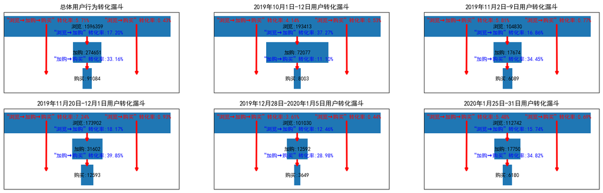

```python
"""子图图框"""
fig, axes = plt.subplots(2,3,figsize=(20, 6))

"""y轴标签"""
y = ['购买', '加购', '浏览']

"""总体用户转化漏斗"""
# x轴数据
x_all = [cart_purchase_users_sum_all, view_cart_users_sum_all, view_users_sum_all]  # x 轴数据【加购后购买用户数 / 浏览后加购用户数 / 全部浏览用户数】
# 计算每个条柱的左边距
max_x_all = max(x_all)  # 最大的条柱的数值
left_list_all = []  # 定义列表，用于存放每个条柱的左边距
# 循环添加每一个条柱的左边距
for i in x_all:
    if i < max_x_all:
        left = (max_x_all - i) / 2
        left_list_all.append(left)
    else:
        left_list_all.append(0)
# 绘制漏斗图
axes[0,0].barh(y, x_all, left=left_list_all)
# 给漏斗图添加必要数值说明
axes[0,0].set_title('总体用户行为转化漏斗')
axes[0,0].set_xticks([])
axes[0,0].set_yticks([])
axes[0,0].text(max_x_all/2,y[0],f'购买:{cart_purchase_users_sum_all}', va='center', ha='center')
axes[0,0].text(max_x_all/2,y[1],f'加购:{view_cart_users_sum_all}', va='center', ha='center')
axes[0,0].text(max_x_all/2,y[2],f'浏览:{view_users_sum_all}', va='center', ha='center')
axes[0,0].annotate(f'“浏览→加购→购买”转化率:{view_cart_purchase_rate_all:.2f}%', xy=(0.242,0.2), xytext=(0,0.88), xycoords='axes fraction', color='red', arrowprops={'arrowstyle':'->', 'color':'red', 'linewidth':3})
axes[0,0].annotate(f'“浏览→购买”转化率:{view_purchase_rate_all:.2f}%', xy=(0.759,0.2), xytext=(0.56,0.88), xycoords='axes fraction', color='red', arrowprops={'arrowstyle':'->', 'color':'red', 'linewidth':3})
axes[0,0].annotate(f'“浏览→加购”转化率:{view_cart_rate_all:.2f}%', xy=(0.475,0.57), xytext=(0.27,0.73), xycoords='axes fraction', color='blue', arrowprops={'arrowstyle':'->', 'color':'red', 'linewidth':3})
axes[0,0].annotate(f'“加购→购买”转化率:{cart_purchase_rate_all:.2f}%', xy=(0.475,0.26), xytext=(0.27,0.4), xycoords='axes fraction', color='blue', arrowprops={'arrowstyle':'->', 'color':'red', 'linewidth':3})

"""2019年10月1日-12日用户转化漏斗"""
# x轴数据
x_10_1_12 = [cart_purchase_users_sum_10_1_12, view_cart_users_sum_10_1_12, view_users_sum_10_1_12]  # x 轴数据【加购后购买用户数 / 浏览后加购用户数 / 全部浏览用户数】
# 计算每个条柱的左边距
max_x_10_1_12 = max(x_10_1_12)  # 最大的条柱的数值
left_list_10_1_12 = []  # 定义列表，用于存放每个条柱的左边距
# 循环添加每一个条柱的左边距
for i in x_10_1_12:
    if i < max_x_10_1_12:
        left = (max_x_10_1_12 - i) / 2
        left_list_10_1_12.append(left)
    else:
        left_list_10_1_12.append(0)
# 绘制漏斗图
axes[0,1].barh(y, x_10_1_12, left=left_list_10_1_12)
# 给漏斗图添加必要数值说明
axes[0,1].set_title('2019年10月1日-12日用户转化漏斗')
axes[0,1].set_xticks([])
axes[0,1].set_yticks([])
axes[0,1].text(max_x_10_1_12/2,y[0],f'购买:{cart_purchase_users_sum_10_1_12}', va='center', ha='center')
axes[0,1].text(max_x_10_1_12/2,y[1],f'加购:{view_cart_users_sum_10_1_12}', va='center', ha='center')
axes[0,1].text(max_x_10_1_12/2,y[2],f'浏览:{view_users_sum_10_1_12}', va='center', ha='center')
axes[0,1].annotate(f'“浏览→加购→购买”转化率:{view_cart_purchase_rate_10_1_12:.2f}%', xy=(0.242,0.2), xytext=(0,0.88), xycoords='axes fraction', color='red', arrowprops={'arrowstyle':'->', 'color':'red', 'linewidth':3})
axes[0,1].annotate(f'“浏览→购买”转化率:{view_purchase_rate_10_1_12:.2f}%', xy=(0.759,0.2), xytext=(0.56,0.88), xycoords='axes fraction', color='red', arrowprops={'arrowstyle':'->', 'color':'red', 'linewidth':3})
axes[0,1].annotate(f'“浏览→加购”转化率:{view_cart_rate_10_1_12:.2f}%', xy=(0.475,0.57), xytext=(0.27,0.73), xycoords='axes fraction', color='blue', arrowprops={'arrowstyle':'->', 'color':'red', 'linewidth':3})
axes[0,1].annotate(f'“加购→购买”转化率:{cart_purchase_rate_10_1_12:.2f}%', xy=(0.475,0.26), xytext=(0.27,0.4), xycoords='axes fraction', color='blue', arrowprops={'arrowstyle':'->', 'color':'red', 'linewidth':3})

"""2019年11月2日-9日用户转化漏斗"""
# x轴数据
x_11_2_9 = [cart_purchase_users_sum_11_2_9, view_cart_users_sum_11_2_9, view_users_sum_11_2_9]  # x 轴数据【加购后购买用户数 / 浏览后加购用户数 / 全部浏览用户数】
# 计算每个条柱的左边距
max_x_11_2_9 = max(x_11_2_9)  # 最大的条柱的数值
left_list_11_2_9 = []  # 定义列表，用于存放每个条柱的左边距
# 循环添加每一个条柱的左边距
for i in x_11_2_9:
    if i < max_x_11_2_9:
        left = (max_x_11_2_9 - i) / 2
        left_list_11_2_9.append(left)
    else:
        left_list_11_2_9.append(0)
# 绘制漏斗图
axes[0,2].barh(y, x_11_2_9, left=left_list_11_2_9)
# 给漏斗图添加必要数值说明
axes[0,2].set_title('2019年11月2日-9日用户转化漏斗')
axes[0,2].set_xticks([])
axes[0,2].set_yticks([])
axes[0,2].text(max_x_11_2_9/2,y[0],f'购买:{cart_purchase_users_sum_11_2_9}', va='center', ha='center')
axes[0,2].text(max_x_11_2_9/2,y[1],f'加购:{view_cart_users_sum_11_2_9}', va='center', ha='center')
axes[0,2].text(max_x_11_2_9/2,y[2],f'浏览:{view_users_sum_11_2_9}', va='center', ha='center')
axes[0,2].annotate(f'“浏览→加购→购买”转化率:{view_cart_purchase_rate_11_2_9:.2f}%', xy=(0.242,0.2), xytext=(0,0.88), xycoords='axes fraction', color='red', arrowprops={'arrowstyle':'->', 'color':'red', 'linewidth':3})
axes[0,2].annotate(f'“浏览→购买”转化率:{view_purchase_rate_11_2_9:.2f}%', xy=(0.759,0.2), xytext=(0.56,0.88), xycoords='axes fraction', color='red', arrowprops={'arrowstyle':'->', 'color':'red', 'linewidth':3})
axes[0,2].annotate(f'“浏览→加购”转化率:{view_cart_rate_11_2_9:.2f}%', xy=(0.475,0.57), xytext=(0.27,0.73), xycoords='axes fraction', color='blue', arrowprops={'arrowstyle':'->', 'color':'red', 'linewidth':3})
axes[0,2].annotate(f'“加购→购买”转化率:{cart_purchase_rate_11_2_9:.2f}%', xy=(0.475,0.26), xytext=(0.27,0.4), xycoords='axes fraction', color='blue', arrowprops={'arrowstyle':'->', 'color':'red', 'linewidth':3})

"""2019年11月20日-12月1日用户转化漏斗"""
# x轴数据
x_11_20_1 = [cart_purchase_users_sum_11_20_1, view_cart_users_sum_11_20_1, view_users_sum_11_20_1]  # x 轴数据【加购后购买用户数 / 浏览后加购用户数 / 全部浏览用户数】
# 计算每个条柱的左边距
max_x_11_20_1 = max(x_11_20_1)  # 最大的条柱的数值
left_list_11_20_1 = []  # 定义列表，用于存放每个条柱的左边距
# 循环添加每一个条柱的左边距
for i in x_11_20_1:
    if i < max_x_11_20_1:
        left = (max_x_11_20_1 - i) / 2
        left_list_11_20_1.append(left)
    else:
        left_list_11_20_1.append(0)
# 绘制漏斗图
axes[1,0].barh(y, x_11_20_1, left=left_list_11_20_1)
# 给漏斗图添加必要数值说明
axes[1,0].set_title('2019年11月20日-12月1日用户转化漏斗')
axes[1,0].set_xticks([])
axes[1,0].set_yticks([])
axes[1,0].text(max_x_11_20_1/2,y[0],f'购买:{cart_purchase_users_sum_11_20_1}', va='center', ha='center')
axes[1,0].text(max_x_11_20_1/2,y[1],f'加购:{view_cart_users_sum_11_20_1}', va='center', ha='center')
axes[1,0].text(max_x_11_20_1/2,y[2],f'浏览:{view_users_sum_11_20_1}', va='center', ha='center')
axes[1,0].annotate(f'“浏览→加购→购买”转化率:{view_cart_purchase_rate_11_20_1:.2f}%', xy=(0.242,0.2), xytext=(0,0.88), xycoords='axes fraction', color='red', arrowprops={'arrowstyle':'->', 'color':'red', 'linewidth':3})
axes[1,0].annotate(f'“浏览→购买”转化率:{view_purchase_rate_11_20_1:.2f}%', xy=(0.759,0.2), xytext=(0.56,0.88), xycoords='axes fraction', color='red', arrowprops={'arrowstyle':'->', 'color':'red', 'linewidth':3})
axes[1,0].annotate(f'“浏览→加购”转化率:{view_cart_rate_11_20_1:.2f}%', xy=(0.475,0.57), xytext=(0.27,0.73), xycoords='axes fraction', color='blue', arrowprops={'arrowstyle':'->', 'color':'red', 'linewidth':3})
axes[1,0].annotate(f'“加购→购买”转化率:{cart_purchase_rate_11_20_1:.2f}%', xy=(0.475,0.26), xytext=(0.27,0.4), xycoords='axes fraction', color='blue', arrowprops={'arrowstyle':'->', 'color':'red', 'linewidth':3})

"""2019年12月28日-2020年1月5日用户转化漏斗"""
# x轴数据
x_12_28_5 = [cart_purchase_users_sum_12_28_5, view_cart_users_sum_12_28_5, view_users_sum_12_28_5]  # x 轴数据【加购后购买用户数 / 浏览后加购用户数 / 全部浏览用户数】
# 计算每个条柱的左边距
max_x_12_28_5 = max(x_12_28_5)  # 最大的条柱的数值
left_list_12_28_5 = []  # 定义列表，用于存放每个条柱的左边距
# 循环添加每一个条柱的左边距
for i in x_12_28_5:
    if i < max_x_12_28_5:
        left = (max_x_12_28_5 - i) / 2
        left_list_12_28_5.append(left)
    else:
        left_list_12_28_5.append(0)
# 绘制漏斗图
axes[1,1].barh(y, x_12_28_5, left=left_list_12_28_5)
# 给漏斗图添加必要数值说明
axes[1,1].set_title('2019年12月28日-2020年1月5日用户转化漏斗')
axes[1,1].set_xticks([])
axes[1,1].set_yticks([])
axes[1,1].text(max_x_12_28_5/2,y[0],f'购买:{cart_purchase_users_sum_12_28_5}', va='center', ha='center')
axes[1,1].text(max_x_12_28_5/2,y[1],f'加购:{view_cart_users_sum_12_28_5}', va='center', ha='center')
axes[1,1].text(max_x_12_28_5/2,y[2],f'浏览:{view_users_sum_12_28_5}', va='center', ha='center')
axes[1,1].annotate(f'“浏览→加购→购买”转化率:{view_cart_purchase_rate_12_28_5:.2f}%', xy=(0.242,0.2), xytext=(0,0.88), xycoords='axes fraction', color='red', arrowprops={'arrowstyle':'->', 'color':'red', 'linewidth':3})
axes[1,1].annotate(f'“浏览→购买”转化率:{view_purchase_rate_12_28_5:.2f}%', xy=(0.759,0.2), xytext=(0.56,0.88), xycoords='axes fraction', color='red', arrowprops={'arrowstyle':'->', 'color':'red', 'linewidth':3})
axes[1,1].annotate(f'“浏览→加购”转化率:{view_cart_rate_12_28_5:.2f}%', xy=(0.475,0.57), xytext=(0.27,0.73), xycoords='axes fraction', color='blue', arrowprops={'arrowstyle':'->', 'color':'red', 'linewidth':3})
axes[1,1].annotate(f'“加购→购买”转化率:{cart_purchase_rate_12_28_5:.2f}%', xy=(0.475,0.26), xytext=(0.27,0.4), xycoords='axes fraction', color='blue', arrowprops={'arrowstyle':'->', 'color':'red', 'linewidth':3})

"""2020年1月25日-31日用户转化漏斗"""
# x轴数据
x_1_25_31 = [cart_purchase_users_sum_1_25_31, view_cart_users_sum_1_25_31, view_users_sum_1_25_31]  # x 轴数据【加购后购买用户数 / 浏览后加购用户数 / 全部浏览用户数】
# 计算每个条柱的左边距
max_x_1_25_31 = max(x_1_25_31)  # 最大的条柱的数值
left_list_1_25_31 = []  # 定义列表，用于存放每个条柱的左边距
# 循环添加每一个条柱的左边距
for i in x_1_25_31:
    if i < max_x_1_25_31:
        left = (max_x_1_25_31 - i) / 2
        left_list_1_25_31.append(left)
    else:
        left_list_1_25_31.append(0)
# 绘制漏斗图
axes[1,2].barh(y, x_1_25_31, left=left_list_1_25_31)
# 给漏斗图添加必要数值说明
axes[1,2].set_title('2020年1月25日-31日用户转化漏斗')
axes[1,2].set_xticks([])
axes[1,2].set_yticks([])
axes[1,2].text(max_x_1_25_31/2,y[0],f'购买:{cart_purchase_users_sum_1_25_31}', va='center', ha='center')
axes[1,2].text(max_x_1_25_31/2,y[1],f'加购:{view_cart_users_sum_1_25_31}', va='center', ha='center')
axes[1,2].text(max_x_1_25_31/2,y[2],f'浏览:{view_users_sum_1_25_31}', va='center', ha='center')
axes[1,2].annotate(f'“浏览→加购→购买”转化率:{view_cart_purchase_rate_1_25_31:.2f}%', xy=(0.242,0.2), xytext=(0,0.88), xycoords='axes fraction', color='red', arrowprops={'arrowstyle':'->', 'color':'red', 'linewidth':3})
axes[1,2].annotate(f'“浏览→购买”转化率:{view_purchase_rate_1_25_31:.2f}%', xy=(0.759,0.2), xytext=(0.56,0.88), xycoords='axes fraction', color='red', arrowprops={'arrowstyle':'->', 'color':'red', 'linewidth':3})
axes[1,2].annotate(f'“浏览→加购”转化率:{view_cart_rate_1_25_31:.2f}%', xy=(0.475,0.57), xytext=(0.27,0.73), xycoords='axes fraction', color='blue', arrowprops={'arrowstyle':'->', 'color':'red', 'linewidth':3})
axes[1,2].annotate(f'“加购→购买”转化率:{cart_purchase_rate_1_25_31:.2f}%', xy=(0.475,0.26), xytext=(0.27,0.4), xycoords='axes fraction', color='blue', arrowprops={'arrowstyle':'->', 'color':'red', 'linewidth':3})

"""展示图表"""
plt.show()
```

##### **小结**

1. **整体转化**：
   1. 整体“浏览→加购→购买”转化率为5.71%，“浏览→购买”转化率为0.43%，说明“加入购物车”是网店用户的核心转化路径
   2. 整体“浏览→加购”转化率为17.20%，高于行业平均水平（5.53%-6.96%），说明用户“浏览→加购”环节转化正常
      1. 数据来源：https://marketing.dynamicyield.com/benchmarks/add-to-cart-rate/
   3. 整体“加购→购买”转化率仅33.16%，超2/3的用户把产品加入购物车后未完成购买
2. **2019年10月1日-12日**：
   1. 异常：阶段“浏览→加购”转化率（37.27%）远高于整体“浏览→加购”转化率（17.20%），但阶段“加购→购买”转化率（11.10%）却远低于整体“加购→购买”转化率（33.16%）
   2. 用户特征：加购意愿强烈，但加购用户购买意愿较低
3. **2019年11月2日-9日**：用户转化率均接近整体，无明显异常
4. **2019年11月20日-12月1日**：
   1. 异常：阶段“浏览→加购”转化率仅18.17%，“加购→购买”转化率高达39.85%，且阶段“浏览→加购→购买”转化率达到全异常时段最高值（7.24%）
   2. 用户特征：加购意愿较低，但加购用户购买意愿较高
5. **2019年12月28日-2020年1月5日**：
   1. 异常：阶段“浏览→购买”转化率（0.44%）与整体“浏览→购买”转化率（0.43%）相近，但其他阶段转化率均显著低于整体转化率，且该阶段内总浏览人数（101030）与阶段“浏览→加购”转化率（12.46%）均为全异常阶段最低值
   2. 用户特征：用户浏览、加购意愿均较低，且加购用户购买意愿也较低
6. **2020年1月25日-31日**：用户转化率均接近整体，无明显异常

## **7 异常归因**

### **7.1 表格汉化**

```python
"""为方便分析，将列索引与用户行为分类重置为中文"""
# 重置列索引
data_analysis = data_explore.rename(columns={"event_time":"行为时间", "event_type":"行为分类", "product_id":"产品ID", "category_id":"产品类别ID", "brand":"品牌", "price":"产品价格", "user_id":"用户ID", "user_session":"会话ID", "year":"年", "month":"月", "day":"日", "week":"周"})
# 重置用户行为类别
data_analysis['行为分类'] = data_analysis['行为分类'].astype("str")  # 将该列转成字符串类型
data_analysis['行为分类'] = data_analysis['行为分类'].replace({"view":"浏览", "cart":"加入购物车", "remove_from_cart":"移出购物车", "purchase":"购买"})  # 更改该列数据值
data_analysis['行为分类'] = data_analysis['行为分类'].astype("category")  # 将该列转回分类类型
# 查看转换后的情况
data_analysis.sample(n=5)
```

|  | 行为时间 | 行为分类 | 产品ID | 产品类别ID | 品牌 | 产品价格 | 用户ID | 会话ID | 年 | 月 | 日 | 周 |
| --- | --- | --- | --- | --- | --- | --- | --- | --- | --- | --- | --- | --- |
| 14744310 | 2020-01-19 21:52:54+00:00 | 移出购物车 | 5723505 | 1487580005134238553 | runail | 2.62 | 231677786 | 722207db-0e52-43ab-b232-6ff97d58626b | 2020 | 1 | 19 | 3 |
| 16474478 | 2020-01-31 13:39:45+00:00 | 购买 | 5759993 | 1487580011652186237 | unknown | 10.71 | 596723316 | 384dcb53-086c-48cd-9353-a0975bf32849 | 2020 | 1 | 31 | 5 |
| 11519039 | 2019-12-23 03:33:53+00:00 | 浏览 | 5824196 | 1487580006551913373 | domix | 2.44 | 571834024 | f56821ff-f13a-41ba-8726-7caf1fe6b680 | 2019 | 12 | 23 | 52 |
| 12872189 | 2020-01-06 16:15:24+00:00 | 购买 | 5803082 | 1487580013858390233 | kapous | 3.49 | 590354623 | 18fd4596-97e3-4a48-9e45-cc91216b2162 | 2020 | 1 | 6 | 2 |
| 20371050 | 2020-02-27 16:37:37+00:00 | 浏览 | 5861279 | 1487580006317032337 | unknown | 30.95 | 621135637 | 6a81eba2-305e-49a2-bdfa-c9e1ec758a75 | 2020 | 2 | 27 | 9 |

### **7.2 异常时段：“2019年10月1日-12日”与“2019年11月20日-12月1日”**

**原假设**：“2019年10月1日-12日”的加购行为不能显著促进用户在“2019年11月20日-12月1日”的购买转化

**备择假设**：“2019年10月1日-12日”的加购行为能显著促进用户在“2019年11月20日-12月1日”的购买转化

```python
"""提取两个时段用户的行为数据"""
# 2019年10月1日-12日所有用户行为
users_event_10_1_12 = data_analysis[(data_analysis["行为时间"] >= pd.to_datetime("2019-10-1", utc=True)) & (data_analysis["行为时间"] < pd.to_datetime("2019-10-13", utc=True))]
# 2019年11月20日-12月1日所有用户行为
users_event_11_20_1 = data_analysis[(data_analysis["行为时间"] >= pd.to_datetime("2019-11-20", utc=True)) & (data_analysis["行为时间"] < pd.to_datetime("2019-12-2", utc=True))]
```

```python
"""第一次浏览时间、最后一次加购时间"""
# 2019年10月1日-12日的所有“浏览”行为
view_event_10_1_12 = users_event_10_1_12[users_event_10_1_12["行为分类"]=="浏览"]
# 2019年10月1日-12日的所有“加购”行为
cart_event_10_1_12 = users_event_10_1_12[users_event_10_1_12["行为分类"]=="加入购物车"]
# 有“浏览”行为的用户的第一次浏览时间
first_view_10_1_12 = view_event_10_1_12.groupby("用户ID")["行为时间"].min()  # 用户第一次浏览时间
first_view_10_1_12 = first_view_10_1_12.reset_index()  # 重置索引，拆出用户ID
first_view_10_1_12 = first_view_10_1_12.rename(columns={"行为时间":"第一次浏览时间"})  # 更正列名
# 有“加购”行为的用户的最后一次加购时间
last_cart_10_1_12 = cart_event_10_1_12.groupby("用户ID")["行为时间"].max()  # 用户最后一次加购时间
last_cart_10_1_12 = last_cart_10_1_12.reset_index()  # 重置索引，拆出用户ID
last_cart_10_1_12 = last_cart_10_1_12.rename(columns={"行为时间":"最后一次加购时间"})  # 更正列名
```

```python
"""样本1：“2019年10月1日-12日”浏览后有加购行为的用户"""
# 内连接，得到同时存在浏览和加购行为的用户的第一次浏览和最后一次加购数据
first_view_last_cart_10_1_12 = pd.merge(first_view_10_1_12, last_cart_10_1_12, how='inner', on="用户ID")
# 条件筛选，得到存在先浏览后加购行为的用户第一次浏览和最后一次加购数据
S_1_view_cart = first_view_last_cart_10_1_12[first_view_last_cart_10_1_12["第一次浏览时间"] < first_view_last_cart_10_1_12["最后一次加购时间"]]
# 2019年10月1日-12日所有存在先“浏览”后“加购”行为的用户
S_1 = S_1_view_cart["用户ID"].unique()
S_1
```

```
<StringArray>
['100787781', '105118203', '109256370', '109382483', '110478711', '112845609',
 '113487654', '113529092', '113651965', '114199003',
 ...
  '81670055',  '84386997',  '85993766',  '88211255',   '8846226',  '95758554',
   '9794320',  '99293243',  '99678913',  '99848331']
Length: 79552, dtype: str
```

```python
"""样本2：“2019年10月1日-12日”浏览后无加购行为的用户的行为数据"""
# 左连接，得到用户第一次浏览时间和最后一次加购时间，并保留“有浏览无加购行为用户”
first_view_last_cart_other_10_1_12 = pd.merge(first_view_10_1_12, last_cart_10_1_12, how='left', on="用户ID")
# 条件筛选，得到浏览后无加购行为的用户第一次浏览和最后一次加购数据
S_2_view_null = first_view_last_cart_other_10_1_12[(first_view_last_cart_other_10_1_12["最后一次加购时间"].isnull()) | (first_view_last_cart_other_10_1_12["最后一次加购时间"] < first_view_last_cart_other_10_1_12["第一次浏览时间"])]
# 2019年10月1日-12日所有“浏览”后无“加购”行为的用户
S_2 = S_2_view_null["用户ID"].unique()
S_2
```

```
<StringArray>
['100015010', '103566871', '103932882', '104368191', '104808268', '105075440',
 '106051933', '106073757', '107078286', '107804408',
 ...
  '92281780',  '92381432',  '92854689',  '93788478',  '93827472',  '94830979',
  '95681006',  '96873136',  '97726982',  '98079173']
Length: 113845, dtype: str
```

```python
"""成功数1：S_1用户中，在“2019年11月20日-12月1日”存在购买行为的用户数"""
# S_1用户在“2019年11月20日-12月1日”期间的所有行为
S_1_event_11_20_1 = users_event_11_20_1[users_event_11_20_1["用户ID"].isin(S_1)]
# S_1用户在“2019年11月20日-12月1日”期间的所有购买行为
S_1_purchase_11_20_1 = S_1_event_11_20_1[S_1_event_11_20_1["行为分类"] == "购买"]
# S_1用户中，在“2019年11月20日-12月1日”存在购买行为的用户
S_1_purchase_users_11_20_1 = S_1_purchase_11_20_1["用户ID"].unique()
# S_1用户中，在“2019年11月20日-12月1日”存在购买行为的用户数
X_A = len(S_1_purchase_users_11_20_1)
X_A
```

```
2328
```

```python
"""成功数2：S_2用户中，在“2019年11月20日-12月1日”存在购买行为的用户数"""
# S_2用户在“2019年11月20日-12月1日”期间的所有行为
S_2_event_11_20_1 = users_event_11_20_1[users_event_11_20_1["用户ID"].isin(S_2)]
# S_2用户在“2019年11月20日-12月1日”期间的所有购买行为
S_2_purchase_11_20_1 = S_2_event_11_20_1[S_2_event_11_20_1["行为分类"] == "购买"]
# S_2用户中，在“2019年11月20日-12月1日”存在购买行为的用户
S_2_purchase_users_11_20_1 = S_2_purchase_11_20_1["用户ID"].unique()
# S_2用户中，在“2019年11月20日-12月1日”存在购买行为的用户数
X_B = len(S_2_purchase_users_11_20_1)
X_B
```

```
1012
```

```python
z_stat, p_value = proportions_ztest([X_A, X_B], [len(S_1), len(S_2)], alternative='larger')  # 对两个样本进行 z 检验
print(f"z值：{z_stat}\np值：{p_value}")  # 输出检验结果
```

```
z值：33.84396896311441
p值：2.2259198745457525e-251
```

**小结**：

1. z检验结果中，p值约为$2.23*10^{-251}$，远小于显著性水平0.05，说明“2019年10月1日-12日”的加购行为能显著促进用户在“2019年11月20日-12月1日”的购买转化，即：两个时段的行为之间存在显著的统计依赖关系，前期加购对后期购买具有明显的正向指示作用
2. 经查阅日历资料，2019年感恩节为11月28日、黑色星期五为11月29日，结合探索性数据分析发现（“2019年11月20日—12月1日”期间用户行为总量与转化率出现了明显异常高峰），这一时段恰好覆盖感恩节与黑色星期五，因此可以确认该异常主要由购物节日效应所致

### **7.3 异常时段：2019年12月28日-2020年1月5日**

#### **7.3.1 “PV、UV、平均会话时长、加购率、购物车转化率”计算函数**

```python
"""“PV、UV、平均会话时长、加购率、购物车转化率”计算函数"""
def pv_uv_session_cart(users_event):
    """
    输入参数：
        users_event：用户行为数据DataFrame
    输出参数：
        event_data：PV、UV、平均会话时长、加购率、购物车转化率
    """
    # PV
    pv = users_event[users_event["行为分类"]=="浏览"].groupby(["年","月","日"])["行为分类"].count()  # 每日PV
    pv = pv.reset_index()  # 重置索引，拿到时间
    pv = pv.rename(columns={"行为分类":"PV"})  # 更正列名
    # UV
    uv = users_event[users_event["行为分类"]=="浏览"].groupby(["年","月","日"])["用户ID"].nunique()  # 每日PV
    uv = uv.reset_index()  # 重置索引，拿到时间
    uv = uv.rename(columns={"用户ID":"UV"})  # 更正列名
    # 平均会话时长 = 总会话时长 / 总会话数
    session = users_event.groupby(["年","月","日"])["会话ID"].nunique()  # 每日总会话数
    session = session.reset_index()  # 重置索引，拿到时间
    session = session.rename(columns={"会话ID":"总会话数"})  # 更正列名
    session_min = users_event.groupby(["年","月","日","会话ID"])["行为时间"].min()  # 会话起始时间
    session_max = users_event.groupby(["年","月","日","会话ID"])["行为时间"].max()  # 会话结束时间
    session_duration = (session_max-session_min).dt.total_seconds().reset_index().rename(columns={"行为时间":"会话时长"})  # 单会话时长
    session["总会话时长（秒）"] = session_duration.groupby(["年","月","日"])["会话时长"].sum().reset_index()["会话时长"]  # 每日总会话时长
    session["平均会话时长（秒）"] = session["总会话时长（秒）"] / session["总会话数"]  # 每日平均会话时长
    # 加购率 = 加购人数 / UV * 100
    cart_rate = users_event[users_event["行为分类"]=="加入购物车"].groupby(["年","月","日"])["用户ID"].nunique()  # 每日总加购用户数
    cart_rate = cart_rate.reset_index()  # 重置索引，拿到时间
    cart_rate = cart_rate.rename(columns={"用户ID":"加购用户数"})  # 更正列名
    cart_rate["加购率（%）"] = cart_rate["加购用户数"] / uv["UV"] * 100  # 每日加购率
    # 购物车转化率 = 购买人数 / 加购人数
    cart_purchase = users_event[users_event["行为分类"]=="购买"].groupby(["年","月","日"])["用户ID"].nunique()  # 每日总购买用户数
    cart_purchase = cart_purchase.reset_index()  # 重置索引，拿到时间
    cart_purchase = cart_purchase.rename(columns={"用户ID":"购买用户数"})  # 更正列名
    cart_purchase["购物车转化率（%）"] = cart_purchase["购买用户数"] / cart_rate["加购用户数"] * 100  # 每日购物车转化率
    # 将数据组合到一起
    event_data = pd.DataFrame({"PV":pv["PV"], "UV":uv["UV"], "平均会话时长（秒）":session["平均会话时长（秒）"], "加购率（%）":cart_rate["加购率（%）"], "购物车转化率（%）":cart_purchase["购物车转化率（%）"]})
    return event_data
```

#### **7.3.2 2019年10月28日-2019年11月5日用户行为数据**

```python
"""2019年10月28日-2019年11月5日用户行为数据"""
data_analysis_10_28_5 = data_analysis[(data_analysis["行为时间"] >= pd.to_datetime('2019-10-28',utc=True)) & (data_analysis["行为时间"] < pd.to_datetime('2019-11-06',utc=True))]
event_data_10_28_5 = pv_uv_session_cart(data_analysis_10_28_5)  # 计算：PV、UV、平均会话时长、加购率、购物车转化率
event_data_10_28_5
```

|  | PV | UV | 平均会话时长（秒） | 加购率（%） | 购物车转化率（%） |
| --- | --- | --- | --- | --- | --- |
| 0 | 63009 | 16524 | 577.646471 | 27.045510 | 22.309241 |
| 1 | 63768 | 16499 | 527.649842 | 27.292563 | 20.630691 |
| 2 | 59462 | 16118 | 516.280540 | 26.547959 | 20.939472 |
| 3 | 57401 | 15334 | 541.747789 | 27.233599 | 22.365900 |
| 4 | 52561 | 14117 | 516.322428 | 27.562513 | 23.464405 |
| 5 | 52428 | 13915 | 537.740351 | 26.956522 | 21.807518 |
| 6 | 57730 | 14845 | 549.727683 | 27.248232 | 21.953028 |
| 7 | 62158 | 15376 | 576.820112 | 28.290843 | 21.724138 |
| 8 | 68824 | 17632 | 536.878670 | 27.342332 | 21.178179 |

#### **7.3.3 2019年12月28日-2020年1月5日用户行为数据**

```python
"""2019年12月28日-2020年1月5日用户行为数据"""
data_analysis_12_28_5 = data_analysis[(data_analysis["行为时间"] >= pd.to_datetime('2019-12-28',utc=True)) & (data_analysis["行为时间"] < pd.to_datetime('2020-01-06',utc=True))]
event_data_12_28_5 = pv_uv_session_cart(data_analysis_12_28_5)  # 计算：PV、UV、平均会话时长、加购率、购物车转化率
event_data_12_28_5
```

|  | PV | UV | 平均会话时长（秒） | 加购率（%） | 购物车转化率（%） |
| --- | --- | --- | --- | --- | --- |
| 0 | 41419 | 13915 | 436.033211 | 21.710384 | 22.277392 |
| 1 | 40573 | 13757 | 436.352928 | 20.266046 | 19.906743 |
| 2 | 34107 | 12677 | 416.491057 | 18.214089 | 15.461239 |
| 3 | 17180 | 7135 | 471.197278 | 15.276804 | 16.788991 |
| 4 | 39560 | 11756 | 505.793709 | 22.465124 | 16.395305 |
| 5 | 49875 | 14026 | 502.784625 | 23.969770 | 17.549078 |
| 6 | 55401 | 15377 | 466.046943 | 24.484620 | 19.787517 |
| 7 | 55893 | 16025 | 491.062500 | 23.968799 | 20.463421 |
| 8 | 58177 | 16490 | 534.176784 | 24.269254 | 21.389305 |

#### **7.3.4 同期环比计算**

```python
"""计算环比"""
# PV的月度环比
mom_pv = (event_data_12_28_5["PV"] - event_data_10_28_5["PV"]) / event_data_10_28_5["PV"] * 100
# UV的月度环比
mom_uv = (event_data_12_28_5["UV"] - event_data_10_28_5["UV"]) / event_data_10_28_5["UV"] * 100
# 平均会话时长的月度环比
mom_session = (event_data_12_28_5["平均会话时长（秒）"] - event_data_10_28_5["平均会话时长（秒）"]) / event_data_10_28_5["平均会话时长（秒）"] * 100
# 加购率的月度环比
mom_cart = (event_data_12_28_5["加购率（%）"] - event_data_10_28_5["加购率（%）"]) / event_data_10_28_5["加购率（%）"] * 100
# 购物车转化率的月度环比
mom_cart_purchase = (event_data_12_28_5["购物车转化率（%）"] - event_data_10_28_5["购物车转化率（%）"]) / event_data_10_28_5["购物车转化率（%）"] * 100
"""构造环比数据表"""
mom_df = pd.DataFrame({"PV环比":mom_pv, "UV环比":mom_uv, "平均会话时长环比":mom_session, "加购率环比":mom_cart, "购物车转化率环比":mom_cart_purchase})
mom_df
```

|  | PV环比 | UV环比 | 平均会话时长环比 | 加购率环比 | 购物车转化率环比 |
| --- | --- | --- | --- | --- | --- |
| 0 | -34.264946 | -15.789155 | -24.515559 | -19.726473 | -0.142765 |
| 1 | -36.374043 | -16.619189 | -17.302557 | -25.745170 | -3.509080 |
| 2 | -42.640678 | -21.348803 | -19.328539 | -31.391755 | -26.162232 |
| 3 | -70.070208 | -53.469414 | -13.022759 | -43.904569 | -24.934876 |
| 4 | -24.735070 | -16.724517 | -2.039175 | -18.493920 | -30.126910 |
| 5 | -4.869535 | 0.797700 | -6.500484 | -11.079884 | -19.527394 |
| 6 | -4.034298 | 3.583698 | -15.222217 | -10.142353 | -9.864297 |
| 7 | -10.079153 | 4.220864 | -14.867306 | -15.277184 | -5.803300 |
| 8 | -15.469894 | -6.476860 | -0.503258 | -11.239268 | 0.996906 |

#### **7.3.5 绘制两个相同时段数据对比折线图**

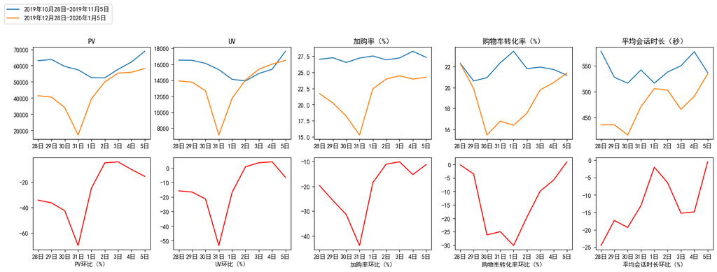

```python
x_text = ["28日", "29日", "30日", "31日", "1日", "2日", "3日", "4日", "5日"]
"""子图图框"""
fig, axes = plt.subplots(2,5,figsize=(20,6)) # 绘制图框
"""“PV”对比"""
sns.lineplot(event_data_10_28_5, x=x_text, y="PV", label="2019年10月28日-2019年11月5日", ax=axes[0,0])  # 2019年10月28日-2019年11月5日
sns.lineplot(event_data_12_28_5, x=x_text, y="PV", label="2019年12月28日-2020年1月5日", ax=axes[0,0])  # 2019年12月28日-2020年1月5日
axes[0,0].set_title("PV")
axes[0,0].set_ylabel("")
axes[0,0].legend(bbox_to_anchor=(0.7,1.5))
"""“UV”对比"""
sns.lineplot(event_data_10_28_5, x=x_text, y="UV", ax=axes[0,1])  # 2019年10月28日-2019年11月5日
sns.lineplot(event_data_12_28_5, x=x_text, y="UV", ax=axes[0,1])  # 2019年12月28日-2020年1月5日
axes[0,1].set_title("UV")
axes[0,1].set_ylabel("")
"""“加购率（%）”对比"""
sns.lineplot(event_data_10_28_5, x=x_text, y="加购率（%）", ax=axes[0,2])  # 2019年10月28日-2019年11月5日
sns.lineplot(event_data_12_28_5, x=x_text, y="加购率（%）", ax=axes[0,2])  # 2019年12月28日-2020年1月5日
axes[0,2].set_title("加购率（%）")
axes[0,2].set_ylabel("")
"""“购物车转化率（%）”对比"""
sns.lineplot(event_data_10_28_5, x=x_text, y="购物车转化率（%）", ax=axes[0,3])  # 2019年10月28日-2019年11月5日
sns.lineplot(event_data_12_28_5, x=x_text, y="购物车转化率（%）", ax=axes[0,3])  # 2019年12月28日-2020年1月5日
axes[0,3].set_title("购物车转化率（%）")
axes[0,3].set_ylabel("")
"""“平均会话时长（秒）”对比"""
sns.lineplot(event_data_10_28_5, x=x_text, y="平均会话时长（秒）", ax=axes[0,4])  # 2019年10月28日-2019年11月5日
sns.lineplot(event_data_12_28_5, x=x_text, y="平均会话时长（秒）", ax=axes[0,4])  # 2019年12月28日-2020年1月5日
axes[0,4].set_title("平均会话时长（秒）")
axes[0,4].set_ylabel("")
"""环比折线"""
# PV环比
sns.lineplot(mom_df, x=x_text, y="PV环比", color='red', ax=axes[1,0])
axes[1,0].set_xlabel("PV环比（%）")
axes[1,0].set_ylabel("")
# UV环比
sns.lineplot(mom_df, x=x_text, y="UV环比", color='red', ax=axes[1,1])
axes[1,1].set_xlabel("UV环比（%）")
axes[1,1].set_ylabel("")
# 加购率环比
sns.lineplot(mom_df, x=x_text, y="加购率环比", color='red', ax=axes[1,2])
axes[1,2].set_xlabel("加购率环比（%）")
axes[1,2].set_ylabel("")
# 购物车转化率环比
sns.lineplot(mom_df, x=x_text, y="购物车转化率环比", color='red', ax=axes[1,3])
axes[1,3].set_xlabel("购物车转化率环比（%）")
axes[1,3].set_ylabel("")
# 平均会话时长环比
sns.lineplot(mom_df, x=x_text, y="平均会话时长环比", color='red', ax=axes[1,4])
axes[1,4].set_xlabel("平均会话时长环比（%）")
axes[1,4].set_ylabel("")

"""展示图表"""
plt.show()
```

**小结**：

1. “PV、UV、加购率、购物车转化率”环比曲线均呈“V形”分布形态，且用户平均会话时长波动上升趋势，说明网店总体流量在短期内急剧下跌后迅速回升，可确认该异常为外部事件导致，并未影响网店总体用户质量
2. 经查阅日历资料，2020年1月1日为元旦，2019年12月31日为跨年夜，结合探索性数据分析发现（“2019年12月28日-2020年1月5日”用户行为总量异常偏低），该时段包含元旦与跨年夜，且用户流量在31日达到时段低谷，因此可以确认该异常主要由跨年节日效应所致

### **7.4 异常环节：加入购物车行为与移出购物车行为的比值为1.89:1**

#### **7.4.1 帕累托分析：定位异常产品**

```python
"""所有“加入购物车”和“移出购物车”行为"""
# 所有“加入购物车”行为
cart_event = data_analysis[data_analysis["行为分类"] == "加入购物车"]
# 所有“移出购物车”行为
remove_from_cart_event = data_analysis[data_analysis["行为分类"] == "移出购物车"]
```

```python
"""定位异常数据，筛选出所有在“加入购物车”行为发生后发生的“移出购物车”行为【在加入前移出的都是异常数据】"""
# 加入购物车行为第一次发生的时间
first_cart_event = cart_event.groupby(["用户ID","产品ID"])["行为时间"].min()  # 根据“用户ID+产品ID”分组，统计每个用户对每个产品在统计周期内的最早加购时间
first_cart_event = first_cart_event.reset_index()  # 重置索引，拆出用户ID和产品ID
first_cart_event = first_cart_event.rename(columns={"行为时间":"第一次加入购物车时间"})  # 更正列名
# 将第一次加购时间左连接到所有移出记录
cart_remove_event = pd.merge(remove_from_cart_event, first_cart_event, how="left", on=["用户ID", "产品ID"])
# 只保留：“移出时间 >= 最早加购时间”的数据
remove_from_cart_event_clean = cart_remove_event[cart_remove_event["行为时间"] >= cart_remove_event["第一次加入购物车时间"]]
remove_from_cart_event_clean.head()
```

|  | 行为时间 | 行为分类 | 产品ID | 产品类别ID | 品牌 | 产品价格 | 用户ID | 会话ID | 年 | 月 | 日 | 周 | 第一次加入购物车时间 |
| --- | --- | --- | --- | --- | --- | --- | --- | --- | --- | --- | --- | --- | --- |
| 4 | 2019-10-01 00:00:56+00:00 | 移出购物车 | 5881589 | 2151191071051219817 | lovely | 13.48 | 429681830 | 49e8d843-adf3-428b-a2c3-fe8bc6a307c9 | 2019 | 10 | 1 | 40 | 2019-10-01 00:00:07+00:00 |
| 8 | 2019-10-01 00:01:06+00:00 | 移出购物车 | 5857269 | 1487580005134238553 | runail | 2.62 | 430174032 | c2bbd970-a5ad-42dd-a59b-f44276330b02 | 2019 | 10 | 1 | 40 | 2019-10-01 00:00:16+00:00 |
| 20 | 2019-10-01 00:01:35+00:00 | 移出购物车 | 5881449 | 1487580013522845895 | lovely | 0.56 | 429681830 | 49e8d843-adf3-428b-a2c3-fe8bc6a307c9 | 2019 | 10 | 1 | 40 | 2019-10-01 00:00:15+00:00 |
| 26 | 2019-10-01 00:02:13+00:00 | 移出购物车 | 5820713 | 1487580006317032337 | unknown | 2.22 | 385985999 | d30965e8-1101-44ab-b45d-cc1bb9fae694 | 2019 | 10 | 1 | 40 | 2019-10-01 00:01:32+00:00 |
| 27 | 2019-10-01 00:02:16+00:00 | 移出购物车 | 5842144 | 1487580006317032337 | unknown | 1.59 | 385985999 | d30965e8-1101-44ab-b45d-cc1bb9fae694 | 2019 | 10 | 1 | 40 | 2019-10-01 00:01:29+00:00 |

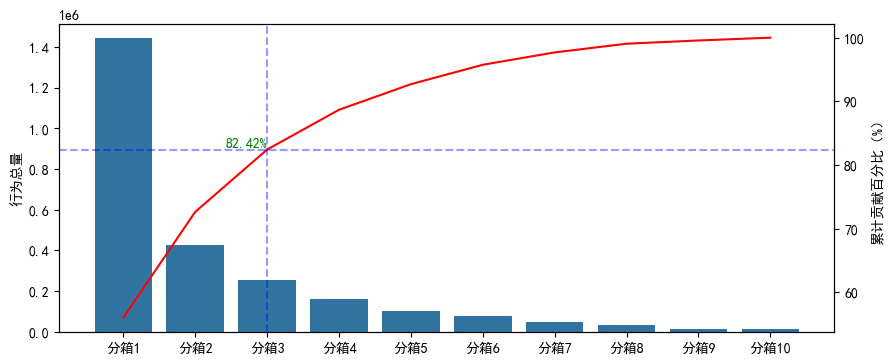

```python
"""用筛选后的“移出购物车”行为数据做帕累托分析"""
# 产品被“移出购物车”的总行为次数
product_remove_from_cart_count = remove_from_cart_event_clean.groupby("产品ID")["行为分类"].count()  # 产品被移出购物车的总行为次数
product_remove_from_cart_count = product_remove_from_cart_count.sort_values(ascending=False)  # 将产品移出购物车次数进行排序
product_remove_from_cart_count = product_remove_from_cart_count.reset_index()  # 重置索引，得到产品ID与行为总量
product_remove_from_cart_count = product_remove_from_cart_count.rename(columns={"行为分类":"行为总量"})  # 更正列名
product_remove_from_cart_count["产品分箱"] = pd.qcut(product_remove_from_cart_count["行为总量"], 10, labels=["分箱10","分箱9","分箱8","分箱7","分箱6","分箱5","分箱4","分箱3","分箱2","分箱1"])  # 等频分箱，方便绘图
# 帕累托分析
product_remove_from_cart_pareto = product_remove_from_cart_count.groupby("产品分箱")["行为总量"].sum()  # 统计每个分箱中产品的行为总量和
product_remove_from_cart_pareto = product_remove_from_cart_pareto.sort_values(ascending=False)  # 将每个分箱中产品的行为总量和进行排序
product_remove_from_cart_pareto = product_remove_from_cart_pareto.reset_index()  # 重置索引，得到产品分箱与行为总量
product_remove_from_cart_pareto["累计贡献"] = product_remove_from_cart_pareto["行为总量"].cumsum()  # 计算产品累计贡献
product_remove_from_cart_pareto["累计贡献百分比（%）"] = product_remove_from_cart_pareto["累计贡献"] / product_remove_from_cart_pareto["行为总量"].sum() * 100  # 计算产品累计贡献百分比
# 帕累托图
fig, axes_left = plt.subplots(1,1, figsize=(10,4))  # 定义子图对象
sns.barplot(product_remove_from_cart_pareto, x=["分箱1","分箱2","分箱3","分箱4","分箱5","分箱6","分箱7","分箱8","分箱9","分箱10"], y='行为总量')  # 绘制‘行为总量’柱状图
axes_left.set_ylabel('行为总量')  # 左轴标签
axes_right = axes_left.twinx()  # 指定下一个图以右轴为基准绘制在原图表上
sns.lineplot(product_remove_from_cart_pareto, x=[0,1,2,3,4,5,6,7,8,9], y='累计贡献百分比（%）', color='red')  # 绘制‘累计浏览量占比’折线图
axes_right.set_ylabel('累计贡献百分比（%）')  # 右轴标签
plt.axhline(y=product_remove_from_cart_pareto["累计贡献百分比（%）"][2], linestyle='--', color='blue', linewidth=1.5, alpha=0.4)  # 基准线【横轴】
plt.axvline(x=2, linestyle='--', color='blue', linewidth=1.5, alpha=0.4)  # 基准线【纵轴】
plt.text(2,product_remove_from_cart_pareto["累计贡献百分比（%）"][2],f"{product_remove_from_cart_pareto["累计贡献百分比（%）"][2]:.2f}%", va='bottom', ha='right', color='green')
plt.show()
```

帕累托图显示：

1. 前3个分箱的产品贡献了82.42%的“移出购物车”行为总量，即：移出行为大部分集中在前3个分箱中
2. 第1个分箱的行为总数远大于第2和第3个分箱，需再进行一次帕累托分析

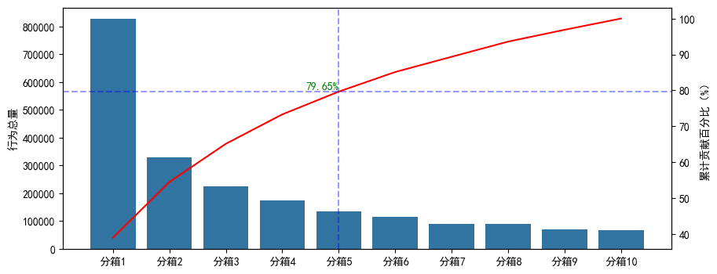

```python
"""对前3个分箱继续做帕累托分析"""
# 前3个分箱的产品的“被移出购物车的总行为次数”
product_remove_from_cart_count_1_3 = product_remove_from_cart_count[product_remove_from_cart_count["产品分箱"].isin(["分箱1","分箱2","分箱3"])]
# 重新分箱
product_remove_from_cart_count_1_3["产品分箱"] = pd.qcut(product_remove_from_cart_count_1_3["行为总量"], 10, labels=["分箱10","分箱9","分箱8","分箱7","分箱6","分箱5","分箱4","分箱3","分箱2","分箱1"])
"""帕累托分析"""
product_remove_from_cart_pareto_1_3 = product_remove_from_cart_count_1_3.groupby("产品分箱")["行为总量"].sum()  # 统计每个分箱中产品的行为总量和
product_remove_from_cart_pareto_1_3 = product_remove_from_cart_pareto_1_3.sort_values(ascending=False)  # 将每个分箱中产品的行为总量和进行排序
product_remove_from_cart_pareto_1_3 = product_remove_from_cart_pareto_1_3.reset_index()  # 重置索引，得到产品分箱与行为总量
product_remove_from_cart_pareto_1_3["累计贡献"] = product_remove_from_cart_pareto_1_3["行为总量"].cumsum()  # 计算产品累计贡献
product_remove_from_cart_pareto_1_3["累计贡献百分比（%）"] = product_remove_from_cart_pareto_1_3["累计贡献"] / product_remove_from_cart_pareto_1_3["行为总量"].sum() * 100  # 计算产品累计贡献百分比
"""帕累托图"""
fig, axes_left = plt.subplots(1,1, figsize=(10,4))  # 定义子图对象
sns.barplot(product_remove_from_cart_pareto_1_3, x=["分箱1","分箱2","分箱3","分箱4","分箱5","分箱6","分箱7","分箱8","分箱9","分箱10"], y='行为总量')  # 绘制‘行为总量’柱状图
axes_left.set_ylabel('行为总量')  # 左轴标签
axes_right = axes_left.twinx()  # 指定下一个图以右轴为基准绘制在原图表上
sns.lineplot(product_remove_from_cart_pareto_1_3, x=[0,1,2,3,4,5,6,7,8,9], y='累计贡献百分比（%）', color='red')  # 绘制‘累计浏览量占比’折线图
axes_right.set_ylabel('累计贡献百分比（%）')  # 右轴标签
plt.axhline(y=product_remove_from_cart_pareto_1_3["累计贡献百分比（%）"][4], linestyle='--', color='blue', linewidth=1.5, alpha=0.4)  # 基准线【横轴】
plt.axvline(x=4, linestyle='--', color='blue', linewidth=1.5, alpha=0.4)  # 基准线【纵轴】
plt.text(4,product_remove_from_cart_pareto_1_3["累计贡献百分比（%）"][4],f"{product_remove_from_cart_pareto_1_3["累计贡献百分比（%）"][4]:.2f}%", va='bottom', ha='right', color='green')
plt.show()
```

第二个帕累托图显示：前5个分箱的产品贡献了数据子集中79.65%的“移出购物车”行为，说明移出购物车行为总量异常主要由这5个分箱产品造成

```python
"""两次帕累托分析后聚焦到的异常产品"""
product_abnormal = product_remove_from_cart_count_1_3[product_remove_from_cart_count_1_3["产品分箱"].isin(["分箱1","分箱2","分箱3","分箱4","分箱5"])]["产品ID"].unique()
product_abnormal
```

```
<StringArray>
['5809910', '5809912', '5854897', '5700037', '5815662', '5802432', '5751422',
 '5751383', '5809911', '5849033',
 ...
 '5857314', '5794069', '5651960', '5741036', '5659921', '5659907', '5794148',
 '5830512', '5832487', '5859185']
Length: 6472, dtype: str
```

```python
"""筛选出存在异常的产品的所有“加入购物车”行为"""
product_abnormal_cart_event = cart_event[cart_event["产品ID"].isin(product_abnormal)]
product_abnormal_cart_event.head()
```

|  | 行为时间 | 行为分类 | 产品ID | 产品类别ID | 品牌 | 产品价格 | 用户ID | 会话ID | 年 | 月 | 日 | 周 |
| --- | --- | --- | --- | --- | --- | --- | --- | --- | --- | --- | --- | --- |
| 1 | 2019-10-01 00:00:03+00:00 | 加入购物车 | 5773353 | 1487580005134238553 | runail | 2.62 | 463240011 | 26dd6e6e-4dac-4778-8d2c-92e149dab885 | 2019 | 10 | 1 | 40 |
| 2 | 2019-10-01 00:00:07+00:00 | 加入购物车 | 5881589 | 2151191071051219817 | lovely | 13.48 | 429681830 | 49e8d843-adf3-428b-a2c3-fe8bc6a307c9 | 2019 | 10 | 1 | 40 |
| 3 | 2019-10-01 00:00:07+00:00 | 加入购物车 | 5723490 | 1487580005134238553 | runail | 2.62 | 463240011 | 26dd6e6e-4dac-4778-8d2c-92e149dab885 | 2019 | 10 | 1 | 40 |
| 4 | 2019-10-01 00:00:15+00:00 | 加入购物车 | 5881449 | 1487580013522845895 | lovely | 0.56 | 429681830 | 49e8d843-adf3-428b-a2c3-fe8bc6a307c9 | 2019 | 10 | 1 | 40 |
| 6 | 2019-10-01 00:00:19+00:00 | 加入购物车 | 5739055 | 1487580008246412266 | kapous | 4.75 | 377667011 | 81326ac6-daa4-4f0a-b488-fd0956a78733 | 2019 | 10 | 1 | 40 |

```python
"""筛选出存在异常的产品的所有“移出购物车”行为"""
product_abnormal_remove_from_cart_event = remove_from_cart_event_clean[remove_from_cart_event_clean["产品ID"].isin(product_abnormal)]
product_abnormal_remove_from_cart_event.head()
```

|  | 行为时间 | 行为分类 | 产品ID | 产品类别ID | 品牌 | 产品价格 | 用户ID | 会话ID | 年 | 月 | 日 | 周 | 第一次加入购物车时间 |
| --- | --- | --- | --- | --- | --- | --- | --- | --- | --- | --- | --- | --- | --- |
| 4 | 2019-10-01 00:00:56+00:00 | 移出购物车 | 5881589 | 2151191071051219817 | lovely | 13.48 | 429681830 | 49e8d843-adf3-428b-a2c3-fe8bc6a307c9 | 2019 | 10 | 1 | 40 | 2019-10-01 00:00:07+00:00 |
| 20 | 2019-10-01 00:01:35+00:00 | 移出购物车 | 5881449 | 1487580013522845895 | lovely | 0.56 | 429681830 | 49e8d843-adf3-428b-a2c3-fe8bc6a307c9 | 2019 | 10 | 1 | 40 | 2019-10-01 00:00:15+00:00 |
| 30 | 2019-10-01 00:02:41+00:00 | 移出购物车 | 5677366 | 1487580008246412266 | estel | 7.30 | 524009100 | 8bbff347-0be1-470e-8860-d9a75db965b2 | 2019 | 10 | 1 | 40 | 2019-10-01 00:01:03+00:00 |
| 37 | 2019-10-01 00:04:14+00:00 | 移出购物车 | 5881589 | 2151191071051219817 | lovely | 13.48 | 429681830 | 49e8d843-adf3-428b-a2c3-fe8bc6a307c9 | 2019 | 10 | 1 | 40 | 2019-10-01 00:00:07+00:00 |
| 44 | 2019-10-01 00:04:19+00:00 | 移出购物车 | 5836522 | 1487580013522845895 | nagaraku | 0.40 | 429681830 | 49e8d843-adf3-428b-a2c3-fe8bc6a307c9 | 2019 | 10 | 1 | 40 | 2019-10-01 00:00:42+00:00 |

#### **7.4.2 统计异常产品在每个用户购物车内的停留时长**

```python
"""异常产品在购物车内停留时长 = 最后一次移出购物车时间 - 第一次加入购物车时间"""
# 第一次加入购物车时间【product_abnormal_cart_event：存在异常的产品的所有“加入购物车”行为】
product_abnormal_first_cart = product_abnormal_cart_event.groupby(["用户ID", "产品ID"])["行为时间"].min()  # 用户对单个产品的第一次加入购物车时间
product_abnormal_first_cart = product_abnormal_first_cart.reset_index()  # 重置索引，得到用户ID和产品ID
product_abnormal_first_cart = product_abnormal_first_cart.rename(columns={"行为时间":"第一次加入购物车时间"})# 更正列名
# 最后一次移出购物车时间【product_abnormal_remove_from_cart_event：存在异常的产品的所有“移出购物车”行为】
product_abnormal_last_remove_from_cart = product_abnormal_remove_from_cart_event.groupby(["用户ID", "产品ID"])["行为时间"].max()  # 用户对单个产品的最后一次移出购物车时间
product_abnormal_last_remove_from_cart = product_abnormal_last_remove_from_cart.reset_index()  # 重置索引，得到用户ID和产品ID
product_abnormal_last_remove_from_cart = product_abnormal_last_remove_from_cart.rename(columns={"行为时间":"最后一次移出购物车时间"})# 更正列名
# 右链接，得到每个被移出购物车的产品的第一次加购时间和最后一次移除时间
product_abnormal_time_in_cart = pd.merge(product_abnormal_first_cart, product_abnormal_last_remove_from_cart, how="right", on=["用户ID", "产品ID"])  # 合并“第一次加入购物车时间”和“最后一次移出购物车时间”
# 整理数据，计算停留时长
product_abnormal_time_in_cart = product_abnormal_time_in_cart.dropna(subset=["第一次加入购物车时间"])  # 无“加入购物车时间”的数据为异常数据，不进行统计
product_abnormal_time_in_cart = product_abnormal_time_in_cart[product_abnormal_time_in_cart["最后一次移出购物车时间"] > product_abnormal_time_in_cart["第一次加入购物车时间"]]  # 最后一次移出购物车时间在第一次加入购物车时间之前的数据也为异常数据，不进行统计
product_abnormal_time_in_cart["停留时长（秒）"] = (product_abnormal_time_in_cart["最后一次移出购物车时间"] - product_abnormal_time_in_cart["第一次加入购物车时间"]).dt.total_seconds()  # 计算停留时长

product_abnormal_time_in_cart.head()
```

|  | 用户ID | 产品ID | 第一次加入购物车时间 | 最后一次移出购物车时间 | 停留时长（秒） |
| --- | --- | --- | --- | --- | --- |
| 0 | 100787781 | 5771964 | 2019-11-04 13:17:15+00:00 | 2019-11-04 13:21:17+00:00 | 242.0 |
| 1 | 100787781 | 5782126 | 2019-10-08 18:48:23+00:00 | 2019-10-08 18:58:02+00:00 | 579.0 |
| 2 | 100787781 | 5787966 | 2019-10-08 19:09:35+00:00 | 2019-10-08 19:09:47+00:00 | 12.0 |
| 3 | 100787781 | 5788438 | 2019-10-08 19:04:33+00:00 | 2019-11-04 13:22:42+00:00 | 2312289.0 |
| 4 | 100787781 | 5864810 | 2019-10-08 18:46:45+00:00 | 2019-10-08 18:58:01+00:00 | 676.0 |

#### **7.4.3 查看看停留时长数值分布情况**

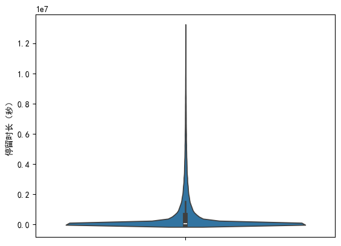

```python
sns.violinplot(product_abnormal_time_in_cart["停留时长（秒）"])
plt.show()
```

从小提琴图可以看出：用户停留时长数据极度右偏，应采用中位数反映产品在用户购物车中停留时长的真实水平

#### **7.4.4 统计每个被移除产品在各用户购物车中停留时长的中位数**

```python
# 统计每个被移除产品在不同用户购物车中停留时长的中位数
product_abnormal_time_in_cart_median = product_abnormal_time_in_cart.groupby("产品ID")["停留时长（秒）"].median()
product_abnormal_time_in_cart_median = product_abnormal_time_in_cart_median.reset_index()  # 重置索引，拆出产品ID
product_abnormal_time_in_cart_median.head()
```

|  | 产品ID | 停留时长（秒） |
| --- | --- | --- |
| 0 | 10108 | 70228.0 |
| 1 | 10115 | 75805.0 |
| 2 | 13497 | 1614.5 |
| 3 | 13552 | 2912.5 |
| 4 | 15700 | 1483.0 |

#### **7.4.5 绘制箱形图，研究停留时长分布特点**

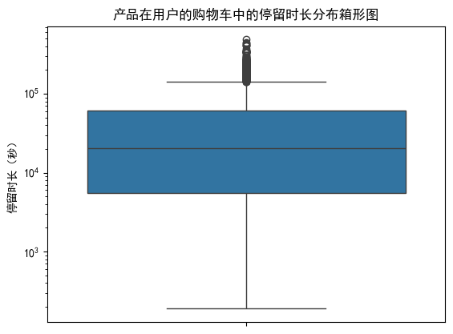

```
第一四分位数：5519.5
第三四分位数：60580.375
```

```python
"""绘制箱形图"""
ax = sns.boxplot(product_abnormal_time_in_cart_median["停留时长（秒）"])  # 绘制箱形图
ax.set_yscale('log')  # 刻度改为对数刻度，避免长尾数据影响
plt.title("产品在用户的购物车中的停留时长分布箱形图")
plt.show()
"""计算第一和第三四分位数"""
product_abnormal_time_in_cart_median_q1 = product_abnormal_time_in_cart_median["停留时长（秒）"].quantile(0.25)  # 第1四分位数
product_abnormal_time_in_cart_median_q3 = product_abnormal_time_in_cart_median["停留时长（秒）"].quantile(0.75)  # 第3四分位数
print(f"第一四分位数：{product_abnormal_time_in_cart_median_q1}\n第三四分位数：{product_abnormal_time_in_cart_median_q3}")
```

1. 25%的产品“典型决策周期”不超过1.53小时
2. 50%的产品“典型决策周期”在1.53小时到16.82小时之间
3. 25%的产品“典型决策周期”超过16.82小时

#### **7.4.6 异常产品分群**

##### **7.4.6.1 快决策产品**

```python
"""快决策产品：“典型决策周期”不超过1.53小时的产品"""
product_abnormal_class_1_time = product_abnormal_time_in_cart_median[product_abnormal_time_in_cart_median["停留时长（秒）"] <= 5648.75]
product_abnormal_class_1 = product_abnormal_class_1_time["产品ID"].unique()
product_abnormal_class_1
```

```
<StringArray>
['13497', '13552', '15700', '15708', '19162', '24330', '24336', '24388',
 '24389', '26765',
 ...
  '7789',  '8122', '82955', '84831', '86005',  '8700',  '8706', '88765',
 '88767',  '9139']
Length: 1649, dtype: str
```

##### **7.4.6.2 正常决策产品**

```python
"""正常决策产品：“典型决策周期”在1.53小时到16.82小时之间的产品"""
product_abnormal_class_2_time = product_abnormal_time_in_cart_median[(product_abnormal_time_in_cart_median["停留时长（秒）"] > 5648.75) & (product_abnormal_time_in_cart_median["停留时长（秒）"] <= 61471.875)]
product_abnormal_class_2 = product_abnormal_class_2_time["产品ID"].unique()
product_abnormal_class_2
```

```
<StringArray>
['20894', '20896', '21062', '23219', '27762', '27764', '30194', '30195',
 '30201', '34758',
 ...
  '7662',  '7681',  '7890',  '7891',  '8071',  '8098',  '8200', '86008',
 '89312', '89350']
Length: 3239, dtype: str
```

##### **7.4.6.3 慢决策产品**

```python
"""慢决策产品：“典型决策周期”超过16.82小时的产品"""
product_abnormal_class_3_time = product_abnormal_time_in_cart_median[product_abnormal_time_in_cart_median["停留时长（秒）"] > 61471.875]
product_abnormal_class_3 = product_abnormal_class_3_time["产品ID"].unique()
product_abnormal_class_3
```

```
<StringArray>
['10108', '10115', '20904', '30200', '34768', '36748', '40088', '40092',
 '40094', '40102',
 ...
  '6626',  '6642',  '6691',  '6731',  '6901',  '7701', '82253', '83872',
 '86007', '89343']
Length: 1584, dtype: str
```

#### **7.4.7 计算不同分群产品移出率，探索加入购物车行为与移出购物车行为的比值为1.89:1的主要原因**

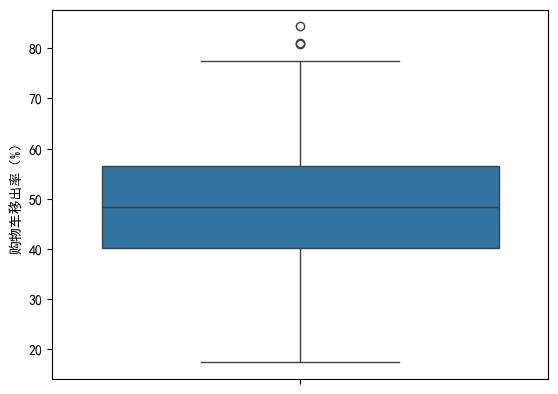

|  | 产品ID | 加入购物车行为次数 | 移出购物车行为次数 | 购物车移出率（%） |
| --- | --- | --- | --- | --- |
| 823 | 5767913 | 115 | 97 | 84.347826 |
| 693 | 5739950 | 121 | 98 | 80.991736 |
| 1000 | 5797135 | 162 | 131 | 80.864198 |

```python
"""快决策产品的购物车移出率"""
# 统计每个快决策产品的“加入购物车”行为次数【product_abnormal_cart_event：异常产品所有加入购物车行为】
abnormal_class_1_cart_event = product_abnormal_cart_event[product_abnormal_cart_event["产品ID"].isin(product_abnormal_class_1)]  # 快决策产品的所有“加入购物车”行为数据
abnormal_class_1_cart_count = abnormal_class_1_cart_event.groupby("产品ID")["行为分类"].count()  # 每个快决策产品的“加入购物车”行为次数
abnormal_class_1_cart_count = abnormal_class_1_cart_count.reset_index()  # 重置索引，拿到产品ID
abnormal_class_1_cart_count = abnormal_class_1_cart_count.rename(columns={"行为分类":"加入购物车行为次数"})  # 更正列名
# 统计每个快决策产品的“移出购物车”行为次数【product_abnormal_remove_from_cart_event：异常产品所有移出购物车行为】
abnormal_class_1_remove_from_cart_event = product_abnormal_remove_from_cart_event[product_abnormal_remove_from_cart_event["产品ID"].isin(product_abnormal_class_1)]  # 快决策产品的所有“移出购物车”行为数据
abnormal_class_1_remove_from_cart_count = abnormal_class_1_remove_from_cart_event.groupby("产品ID")["行为分类"].count()  # 每个快决策产品的“移出购物车”行为次数
abnormal_class_1_remove_from_cart_count = abnormal_class_1_remove_from_cart_count.reset_index()  # 重置索引，拿到产品ID
abnormal_class_1_remove_from_cart_count = abnormal_class_1_remove_from_cart_count.rename(columns={"行为分类":"移出购物车行为次数"})  # 更正列名
# 购物车移出率 = 移出购物车行为次数 / 加入购物车行为次数 * 100%
abnormal_class_1_cart_removal_rate = pd.merge(abnormal_class_1_cart_count, abnormal_class_1_remove_from_cart_count, how="left", on="产品ID")  # 合并产品的“加入购物车”次数和“移出购物车”次数
abnormal_class_1_cart_removal_rate["购物车移出率（%）"] = abnormal_class_1_cart_removal_rate["移出购物车行为次数"] / abnormal_class_1_cart_removal_rate["加入购物车行为次数"] * 100
abnormal_class_1_cart_removal_rate = abnormal_class_1_cart_removal_rate.sort_values(by="购物车移出率（%）", ascending=False)  # 根据购物车移除率从高到低排序
"""绘制箱形图"""
sns.boxplot(abnormal_class_1_cart_removal_rate["购物车移出率（%）"])
plt.show()
"""筛选异常数据"""
# 统计信息汇总
abnormal_class_1_cart_removal_rate_describe = abnormal_class_1_cart_removal_rate["购物车移出率（%）"].describe()  # 购物车移出率统计信息
# 计算上界
abnormal_class_1_cart_removal_rate_upper = abnormal_class_1_cart_removal_rate_describe["75%"] + 1.5 * (abnormal_class_1_cart_removal_rate_describe["75%"] -abnormal_class_1_cart_removal_rate_describe["25%"])
# 计算下界
abnormal_class_1_cart_removal_rate_lower = abnormal_class_1_cart_removal_rate_describe["25%"] - 1.5 * (abnormal_class_1_cart_removal_rate_describe["75%"] -abnormal_class_1_cart_removal_rate_describe["25%"])
# 异常数据筛选
abnormal_class_1_cart_removal_rate[(abnormal_class_1_cart_removal_rate["购物车移出率（%）"] >= abnormal_class_1_cart_removal_rate_upper) | (abnormal_class_1_cart_removal_rate["购物车移出率（%）"] <= abnormal_class_1_cart_removal_rate_lower)]
```

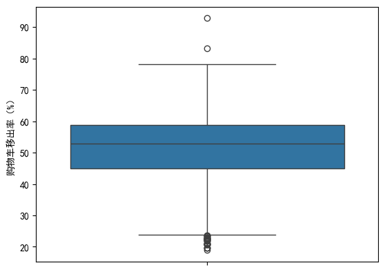

|  | 产品ID | 加入购物车行为次数 | 移出购物车行为次数 | 购物车移出率（%） |
| --- | --- | --- | --- | --- |
| 1833 | 5819245 | 153 | 142 | 92.810458 |
| 2479 | 5858483 | 178 | 148 | 83.146067 |
| 578 | 5688124 | 6407 | 1513 | 23.614796 |
| 13 | 36406 | 1430 | 337 | 23.566434 |
| 685 | 5700074 | 1191 | 279 | 23.425693 |
| 2641 | 5868467 | 549 | 128 | 23.315118 |
| 2428 | 5854881 | 2268 | 520 | 22.927690 |
| 318 | 5587782 | 594 | 136 | 22.895623 |
| 669 | 5700035 | 9735 | 2214 | 22.742681 |
| 2256 | 5843836 | 10019 | 2274 | 22.696876 |
| 1477 | 5802432 | 24244 | 5464 | 22.537535 |
| 1596 | 5809824 | 1248 | 281 | 22.516026 |
| 102 | 5240 | 521 | 117 | 22.456814 |
| 561 | 5686081 | 2073 | 464 | 22.383020 |
| 671 | 5700037 | 25052 | 5583 | 22.285646 |
| 668 | 5700032 | 1030 | 228 | 22.135922 |
| 674 | 5700042 | 1513 | 334 | 22.075347 |
| 672 | 5700038 | 3034 | 665 | 21.918260 |
| 2616 | 5866421 | 638 | 139 | 21.786834 |
| 678 | 5700047 | 5368 | 1137 | 21.181073 |
| 2098 | 5836529 | 1158 | 244 | 21.070812 |
| 562 | 5686099 | 469 | 98 | 20.895522 |
| 295 | 5585632 | 2008 | 418 | 20.816733 |
| 670 | 5700036 | 2599 | 539 | 20.738746 |
| 676 | 5700045 | 1281 | 265 | 20.686963 |
| 558 | 5685798 | 4942 | 1021 | 20.659652 |
| 677 | 5700046 | 12022 | 2364 | 19.663949 |
| 2096 | 5836522 | 10722 | 2100 | 19.585898 |
| 2837 | 5881449 | 720 | 141 | 19.583333 |
| 667 | 5700031 | 1722 | 326 | 18.931475 |

```python
"""正常决策产品的购物车移出率"""
# 统计每个正常决策产品的“加入购物车”行为次数【product_abnormal_cart_event：异常产品所有加入购物车行为】
abnormal_class_2_cart_event = product_abnormal_cart_event[product_abnormal_cart_event["产品ID"].isin(product_abnormal_class_2)]  # 正常决策产品的所有“加入购物车”行为数据
abnormal_class_2_cart_count = abnormal_class_2_cart_event.groupby("产品ID")["行为分类"].count()  # 每个正常决策产品的“加入购物车”行为次数
abnormal_class_2_cart_count = abnormal_class_2_cart_count.reset_index()  # 重置索引，拿到产品ID
abnormal_class_2_cart_count = abnormal_class_2_cart_count.rename(columns={"行为分类":"加入购物车行为次数"})  # 更正列名
# 统计每个正常决策产品的“移出购物车”行为次数【product_abnormal_remove_from_cart_event：异常产品所有移出购物车行为】
abnormal_class_2_remove_from_cart_event = product_abnormal_remove_from_cart_event[product_abnormal_remove_from_cart_event["产品ID"].isin(product_abnormal_class_2)]  # 正常决策产品的所有“移出购物车”行为数据
abnormal_class_2_remove_from_cart_count = abnormal_class_2_remove_from_cart_event.groupby("产品ID")["行为分类"].count()  # 每个正常决策产品的“移出购物车”行为次数
abnormal_class_2_remove_from_cart_count = abnormal_class_2_remove_from_cart_count.reset_index()  # 重置索引，拿到产品ID
abnormal_class_2_remove_from_cart_count = abnormal_class_2_remove_from_cart_count.rename(columns={"行为分类":"移出购物车行为次数"})  # 更正列名
# 购物车移出率 = 移出购物车行为次数 / 加入购物车行为次数 * 100%
abnormal_class_2_cart_removal_rate = pd.merge(abnormal_class_2_cart_count, abnormal_class_2_remove_from_cart_count, how="left", on="产品ID")  # 合并产品的“加入购物车”次数和“移出购物车”次数
abnormal_class_2_cart_removal_rate["购物车移出率（%）"] = abnormal_class_2_cart_removal_rate["移出购物车行为次数"] / abnormal_class_2_cart_removal_rate["加入购物车行为次数"] * 100
abnormal_class_2_cart_removal_rate = abnormal_class_2_cart_removal_rate.sort_values(by="购物车移出率（%）", ascending=False)  # 根据购物车移除率从高到低排序
"""绘制箱形图"""
sns.boxplot(abnormal_class_2_cart_removal_rate["购物车移出率（%）"])
plt.show()
"""筛选异常数据"""
# 统计信息汇总
abnormal_class_2_cart_removal_rate_describe = abnormal_class_2_cart_removal_rate["购物车移出率（%）"].describe()  # 购物车移出率统计信息
# 计算上界
abnormal_class_2_cart_removal_rate_upper = abnormal_class_2_cart_removal_rate_describe["75%"] + 1.5 * (abnormal_class_2_cart_removal_rate_describe["75%"] -abnormal_class_2_cart_removal_rate_describe["25%"])
# 计算下界
abnormal_class_2_cart_removal_rate_lower = abnormal_class_2_cart_removal_rate_describe["25%"] - 1.5 * (abnormal_class_2_cart_removal_rate_describe["75%"] -abnormal_class_2_cart_removal_rate_describe["25%"])
# 异常数据筛选
abnormal_class_2_cart_removal_rate[(abnormal_class_2_cart_removal_rate["购物车移出率（%）"] >= abnormal_class_2_cart_removal_rate_upper) | (abnormal_class_2_cart_removal_rate["购物车移出率（%）"] <= abnormal_class_2_cart_removal_rate_lower)]
```

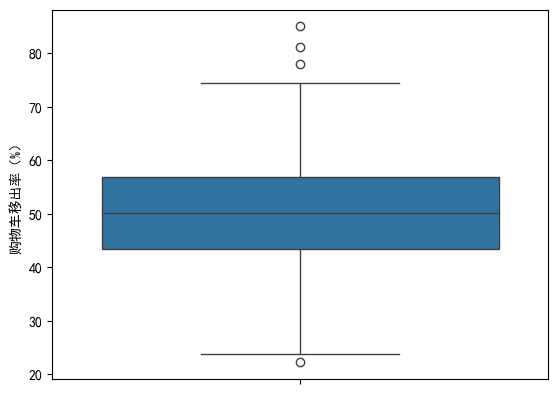

|  | 产品ID | 加入购物车行为次数 | 移出购物车行为次数 | 购物车移出率（%） |
| --- | --- | --- | --- | --- |
| 973 | 5858496 | 120 | 102 | 85.000000 |
| 604 | 5819249 | 249 | 202 | 81.124498 |
| 715 | 5832425 | 136 | 106 | 77.941176 |
| 677 | 5825595 | 473 | 105 | 22.198732 |

```python
"""慢决策产品的购物车移出率"""
# 统计每个慢决策产品的“加入购物车”行为次数【product_abnormal_cart_event：异常产品所有加入购物车行为】
abnormal_class_3_cart_event = product_abnormal_cart_event[product_abnormal_cart_event["产品ID"].isin(product_abnormal_class_3)]  # 慢决策产品的所有“加入购物车”行为数据
abnormal_class_3_cart_count = abnormal_class_3_cart_event.groupby("产品ID")["行为分类"].count()  # 每个慢决策产品的“加入购物车”行为次数
abnormal_class_3_cart_count = abnormal_class_3_cart_count.reset_index()  # 重置索引，拿到产品ID
abnormal_class_3_cart_count = abnormal_class_3_cart_count.rename(columns={"行为分类":"加入购物车行为次数"})  # 更正列名
# 统计每个慢决策产品的“移出购物车”行为次数【product_abnormal_remove_from_cart_event：异常产品所有移出购物车行为】
abnormal_class_3_remove_from_cart_event = product_abnormal_remove_from_cart_event[product_abnormal_remove_from_cart_event["产品ID"].isin(product_abnormal_class_3)]  # 慢决策产品的所有“移出购物车”行为数据
abnormal_class_3_remove_from_cart_count = abnormal_class_3_remove_from_cart_event.groupby("产品ID")["行为分类"].count()  # 每个慢决策产品的“移出购物车”行为次数
abnormal_class_3_remove_from_cart_count = abnormal_class_3_remove_from_cart_count.reset_index()  # 重置索引，拿到产品ID
abnormal_class_3_remove_from_cart_count = abnormal_class_3_remove_from_cart_count.rename(columns={"行为分类":"移出购物车行为次数"})  # 更正列名
# 购物车移出率 = 移出购物车行为次数 / 加入购物车行为次数 * 100%
abnormal_class_3_cart_removal_rate = pd.merge(abnormal_class_3_cart_count, abnormal_class_3_remove_from_cart_count, how="left", on="产品ID")  # 合并产品的“加入购物车”次数和“移出购物车”次数
abnormal_class_3_cart_removal_rate["购物车移出率（%）"] = abnormal_class_3_cart_removal_rate["移出购物车行为次数"] / abnormal_class_3_cart_removal_rate["加入购物车行为次数"] * 100
abnormal_class_3_cart_removal_rate = abnormal_class_3_cart_removal_rate.sort_values(by="购物车移出率（%）", ascending=False)  # 根据购物车移除率从高到低排序
"""绘制箱形图"""
sns.boxplot(abnormal_class_3_cart_removal_rate["购物车移出率（%）"])
plt.show()
"""筛选异常数据"""
# 统计信息汇总
abnormal_class_3_cart_removal_rate_describe = abnormal_class_3_cart_removal_rate["购物车移出率（%）"].describe()  # 购物车移出率统计信息
# 计算上界
abnormal_class_3_cart_removal_rate_upper = abnormal_class_3_cart_removal_rate_describe["75%"] + 1.5 * (abnormal_class_3_cart_removal_rate_describe["75%"] -abnormal_class_3_cart_removal_rate_describe["25%"])
# 计算下界
abnormal_class_3_cart_removal_rate_lower = abnormal_class_3_cart_removal_rate_describe["25%"] - 1.5 * (abnormal_class_3_cart_removal_rate_describe["75%"] -abnormal_class_3_cart_removal_rate_describe["25%"])
# 异常数据筛选
abnormal_class_3_cart_removal_rate[(abnormal_class_3_cart_removal_rate["购物车移出率（%）"] >= abnormal_class_3_cart_removal_rate_upper) | (abnormal_class_3_cart_removal_rate["购物车移出率（%）"] <= abnormal_class_3_cart_removal_rate_lower)]
```

#### **7.4.8 小结**

1. 各分群产品移出率四分位数均集中在40%-60%区间，整体加购-移除比1.89:1（移出率约52.9%），说明高移出率是全店普遍现象，非个别产品导致
2. 移出率异常偏高的产品（大于上界），其加购量普遍较低（最大仅249），而移出率异常偏低的产品（小于下界），其加购量普遍较高（最小达469），说明产品转化符合用户正常决策逻辑，无异常产品出现

### **7.5 探索购物车移出率偏高的原因**

#### **7.5.1 每个用户每次“移出购物车”前的行为**

```python
"""根据“用户ID+行为时间”分组，得到每个用户及其行为序列【从小到大排序】"""
users_event_sort = data_analysis.sort_values(by=["用户ID","行为时间"])  # 根据“用户ID+行为时间”联合分组，将每个用户的所有行为归类到一起【从小到大排序】
users_event_sort = users_event_sort.reset_index()  # 重置索引，方便后续用索引取值
users_event_sort = users_event_sort.drop("index", axis=1)  # 将多出来的列去除
users_event_sort.head()
```

|  | 行为时间 | 行为分类 | 产品ID | 产品类别ID | 品牌 | 产品价格 | 用户ID | 会话ID | 年 | 月 | 日 | 周 |
| --- | --- | --- | --- | --- | --- | --- | --- | --- | --- | --- | --- | --- |
| 0 | 2019-10-10 14:11:28+00:00 | 浏览 | 5776130 | 1487580013472514244 | art-visage | 1.98 | 100015010 | 852f0890-41c4-4870-92c3-3d13e7ea22bc | 2019 | 10 | 10 | 41 |
| 1 | 2019-10-28 11:40:48+00:00 | 浏览 | 5776129 | 1487580013472514244 | art-visage | 2.70 | 100015010 | c39a7ce1-cea7-4da8-bf8e-13d1d26ace6f | 2019 | 10 | 28 | 44 |
| 2 | 2019-10-28 11:42:47+00:00 | 浏览 | 5698279 | 1977575787259232875 | art-visage | 1.98 | 100015010 | c39a7ce1-cea7-4da8-bf8e-13d1d26ace6f | 2019 | 10 | 28 | 44 |
| 3 | 2019-10-28 11:44:26+00:00 | 浏览 | 5776129 | 1487580013472514244 | art-visage | 2.70 | 100015010 | 49e717f6-d1c5-4a87-88ec-20c2cc9c3637 | 2019 | 10 | 28 | 44 |
| 4 | 2019-11-22 11:44:46+00:00 | 加入购物车 | 5816668 | 1487580005553668971 | unknown | 6.71 | 100032619 | 532d31f6-8f96-48cd-8e0b-c2024c2adc8e | 2019 | 11 | 22 | 47 |

```python
"""每一个用户的所有“移出购物车”行为与其前一个行为的数据"""
# 获取所有“移出购物车”行为在原表中的行索引
remove_from_cart_index = users_event_sort[users_event_sort["行为分类"]=="移出购物车"].index
# 获取所有“移出购物车”行为的前一个行为在原表中的行索引
remove_from_cart_before_1_index = users_event_sort[users_event_sort["行为分类"]=="移出购物车"].index - 1
# 获取所有“移出购物车”行为
remove_from_cart_event_all = users_event_sort[users_event_sort.index.isin(remove_from_cart_index)]  # 所有“移出购物车”行为
remove_from_cart_event_all = remove_from_cart_event_all.reset_index()  # 重置索引，得到每个行为在原表中的行索引
remove_from_cart_event_all = remove_from_cart_event_all.rename(columns={"index":"行为在原表中的索引"})  # 更正列名
# 获取所有“移出购物车”行为的前一个行为
remove_from_cart_before_1_event_all = users_event_sort[users_event_sort.index.isin(remove_from_cart_before_1_index)]  # 所有“移出购物车”行为的前一个行为
remove_from_cart_before_1_event_all = remove_from_cart_before_1_event_all.reset_index()  # 重置索引，得到每个行为在原表中的行索引
remove_from_cart_before_1_event_all = remove_from_cart_before_1_event_all.rename(columns={"index":"行为在原表中的索引"})  # 更正列名
# 将“前一个行为所属用户的用户ID”追加到 remove_from_cart_event_all 中
remove_from_cart_event_all["前一个行为所属用户ID"] = remove_from_cart_before_1_event_all["用户ID"]
# 剔除掉“无其他操作，直接将产品移出购物车”的异常移出行为，得到：每一个用户的所有“移出购物车”行为
remove_from_cart_event = remove_from_cart_event_all[remove_from_cart_event_all["用户ID"] == remove_from_cart_event_all["前一个行为所属用户ID"]]
# 剔除掉“无其他操作，直接将产品移出购物车”的异常移出行为的前一个行为，得到：每一个用户的所有“移出购物车”行为的前一个行为
remove_from_cart_before_1_event = remove_from_cart_before_1_event_all[remove_from_cart_before_1_event_all.index.isin(remove_from_cart_event_all.index)]
```

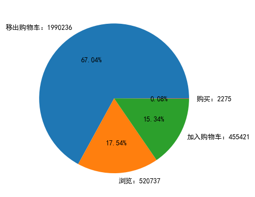

```python
"""查看“每一个用户的所有‘移出购物车’行为的前一个行为”的“行为类别”总量占比，确定用户“购物车移出率偏高”的核心原因"""
remove_from_cart_before_1_event_count = remove_from_cart_before_1_event["行为分类"].value_counts()
"""绘制饼图，直观展示不同行为类别占比"""
plt.pie([
    remove_from_cart_before_1_event_count["移出购物车"] / sum(remove_from_cart_before_1_event_count) * 100,
    remove_from_cart_before_1_event_count["浏览"] / sum(remove_from_cart_before_1_event_count) * 100,
    remove_from_cart_before_1_event_count["加入购物车"] / sum(remove_from_cart_before_1_event_count) * 100,
    remove_from_cart_before_1_event_count["购买"] / sum(remove_from_cart_before_1_event_count) * 100,
], labels=[
    f"移出购物车：{remove_from_cart_before_1_event_count["移出购物车"]}",
    f"浏览：{remove_from_cart_before_1_event_count["浏览"]}",
    f"加入购物车：{remove_from_cart_before_1_event_count["加入购物车"]}",
    f"购买：{remove_from_cart_before_1_event_count["购买"]}"
], autopct="%.2f%%")

plt.show()
```

**小结**：

1. 移出购物车前，“移出购物车”行为占了67.04%，说明用户可能存在连续将多个产品移出购物车的情况，需结合“会话”验证用户“移出购物车”行为是否为批量决策行为
2. 移出购物车前，“浏览”行为占比17.54%，“加入购物车”行为占比15.34%，说明用户可能受其他产品影响而放弃另一件产品，需结合“产品ID”验证“移出购物车”行为是否受其他产品影响
3. 移出购物车前，“购买”行为仅占0.08%，说明用户完成购买后较少继续对购物车中的商品进行移除操作，即：“购买”行为对“购物车移出”行为影响极弱

#### **7.5.2 “移出购物车”行为总量占比**

```python
"""根据“会话”分组，统计每个有“移出购物车”行为的会话内的“移出购物车”行为总数"""
# 【remove_from_cart_event_all：所有“移出购物车”行为】
remove_from_cart_session_count = remove_from_cart_event_all.groupby("会话ID")["行为分类"].count().rename('移出购物车行为次数')  # 每个会话内的“移出购物车”行为总数
remove_from_cart_session_count
```

```
会话ID
000013d6-68a4-40cf-9452-6577dbfab515     8
00002b0e-d7f7-454e-8386-431c4021a9f6     8
00004a32-6d8e-d767-9e96-4bae83be8d4b     9
00008836-6d96-4580-8527-173d4e1b2889     9
0000d04d-3516-42ea-bdb9-584e92ce619e    11
                                        ..
ffff093c-72f9-4495-945e-494cbed24282     4
ffff4402-79bc-43b5-8e94-9b015f3aed0f     1
ffff7b96-9751-4eaa-806e-fe979cc00dc8     1
ffff8529-58c1-4ec8-933e-77f535718061     1
ffffeed4-b0dd-499c-ba8c-213a1ab9f50d     8
Name: 移出购物车行为次数, Length: 483376, dtype: int64
```

```python
"""“批量清除购物车”的会话占总会话的比例"""
# 单个会话“移出购物车”行为总数达到4个以上，视为“批量清除购物车”
# 计算“批量清除购物车”会话数占总会话数的比例
print(f"“批量清除购物车”会话数占总会话数的比例：{len(remove_from_cart_session_count[remove_from_cart_session_count > 4]) / len(remove_from_cart_session_count) * 100:.2f}%")
```

```
“批量清除购物车”会话数占总会话数的比例：35.57%
```

```python
"""“批量清除购物车”的会话的“购物车移出”行为总数占“购物车移出”行为总数的比例"""
# 单个会话“移出购物车”行为总数达到4个以上，视为“批量清除购物车”
# 计算“批量清除购物车”会话数占总会话数的比例
print(f"“批量清除购物车”会话的“购物车移出”行为总数占“购物车移出”行为总数的比例：{remove_from_cart_session_count[remove_from_cart_session_count > 4].sum() / remove_from_cart_session_count.sum() * 100:.2f}%")
```

```
“批量清除购物车”会话的“购物车移出”行为总数占“购物车移出”行为总数的比例：79.32%
```

**小结**：“批量清除购物车”会话数占总会话数的比例为35.57%，但其中“购物车移出”行为总数却占“购物车移出”行为总数的79.32%，说明“移出购物车”行为出现的“移出购物车”行为大部分是由于用户批量清理购物车造成的

#### **7.5.3 “移出购物车”行为是否受其他产品影响**

```python
"""筛选出“移出购物车”行为的前一个行为是“浏览”的所有行为，还有这些行为对应的“移出购物车”行为"""
# 【remove_from_cart_before_1_event_all：所有“移出购物车”行为的前一个行为】
# “移出购物车”行为的前一个行为是“浏览”的所有行为
remove_from_cart_before_1_view = remove_from_cart_before_1_event_all[remove_from_cart_before_1_event_all["行为分类"] == "浏览"]
# 【remove_from_cart_event_all：所有“移出购物车”行为】
# remove_from_cart_before_1_view 对应的所有“移出购物车”行为
remove_from_cart_view = remove_from_cart_event_all[remove_from_cart_event_all["行为在原表中的索引"].isin(remove_from_cart_before_1_view["行为在原表中的索引"]+1)]
"""把 remove_from_cart_view 的“产品ID”追加到 remove_from_cart_before_1_view 中"""
remove_from_cart_before_1_view["“移出购物车”行为对应产品ID"] = remove_from_cart_view["产品ID"]
remove_from_cart_before_1_view
"""同一产品先“浏览”后“移除”的行为占总浏览和加购行为的比例"""
print(f"同一产品先浏览后移除的行为占总“浏览后移除”行为的比例：{len(remove_from_cart_before_1_view[remove_from_cart_before_1_view["产品ID"] == remove_from_cart_before_1_view["“移出购物车”行为对应产品ID"]]) / len(remove_from_cart_before_1_view) * 100:.2f}%")
print(f"先浏览一个产品后移除购物车中的另一个产品的行为占总“浏览后移除”行为的比例：{100 - len(remove_from_cart_before_1_view[remove_from_cart_before_1_view["产品ID"] == remove_from_cart_before_1_view["“移出购物车”行为对应产品ID"]]) / len(remove_from_cart_before_1_view) * 100:.2f}%")
```

```
同一产品先浏览后移除的行为占总“浏览后移除”行为的比例：37.39%
先浏览一个产品后移除购物车中的另一个产品的行为占总“浏览后移除”行为的比例：62.61%
```

```python
"""筛选出“移出购物车”行为的前一个行为是“加入购物车”的所有行为，还有这些行为对应的“移出购物车”行为"""
# 【remove_from_cart_before_1_event_all：所有“移出购物车”行为的前一个行为】
# “移出购物车”行为的前一个行为是“加入购物车”的所有行为
remove_from_cart_before_1_cart = remove_from_cart_before_1_event_all[remove_from_cart_before_1_event_all["行为分类"] == "加入购物车"]
# 【remove_from_cart_event_all：所有“移出购物车”行为】
# remove_from_cart_before_1_cart 对应的所有“移出购物车”行为
remove_from_cart_cart = remove_from_cart_event_all[remove_from_cart_event_all["行为在原表中的索引"].isin(remove_from_cart_before_1_cart["行为在原表中的索引"]+1)]
"""把 remove_from_cart_cart 的“产品ID”追加到 remove_from_cart_before_1_cart 中"""
remove_from_cart_before_1_cart["“移出购物车”行为对应产品ID"] = remove_from_cart_cart["产品ID"]
remove_from_cart_before_1_cart
"""同一产品先“加入购物车”后“移除”的行为占总浏览和加购行为的比例"""
print(f"同一产品先加入购物车后移除的行为占总“加入购物车后移除”行为的比例：{len(remove_from_cart_before_1_cart[remove_from_cart_before_1_cart["产品ID"] == remove_from_cart_before_1_cart["“移出购物车”行为对应产品ID"]]) / len(remove_from_cart_before_1_cart) * 100:.2f}%")
print(f"先将一个产品加入购物车后移除购物车中的另一个产品的行为占总“加入购物车后移除”行为的比例：{100 - len(remove_from_cart_before_1_cart[remove_from_cart_before_1_cart["产品ID"] == remove_from_cart_before_1_cart["“移出购物车”行为对应产品ID"]]) / len(remove_from_cart_before_1_cart) * 100:.2f}%")
```

```
同一产品先加入购物车后移除的行为占总“加入购物车后移除”行为的比例：25.59%
先将一个产品加入购物车后移除购物车中的另一个产品的行为占总“加入购物车后移除”行为的比例：74.41%
```

**小结**：先浏览一个产品后移除购物车中的另一个产品的行为占总“浏览后移除”行为的62.61%，先将一个产品加入购物车后移除购物车中的另一个产品的行为占总“加入购物车后移除”行为的74.41%，说明用户容易受其他替代产品影响而放弃原商品

## **8 购买转化**

### **8.1 用户分群**

#### **8.1.1 有‘购买’行为的用户最近一次消费时间间隔（R）**

```python
"""筛选所有“购买”行为数据"""
purchase_event = data_analysis[data_analysis["行为分类"]=="购买"]
```

```python
"""用户最后一次消费时间"""
last_purchase = purchase_event.groupby("用户ID")["行为时间"].max()  # 按‘用户ID’分组，取每个有‘购买’行为的用户的最晚消费时间【purchase_event：所有‘购买’事件】
last_purchase
```

```
用户ID
100557945   2020-02-21 08:54:41+00:00
100787781   2019-11-15 19:33:34+00:00
10079204    2019-11-06 10:43:30+00:00
101025416   2019-12-18 14:56:58+00:00
101281763   2019-11-30 10:48:31+00:00
                       ...
99293243    2020-02-25 11:10:35+00:00
99499363    2020-02-21 06:35:15+00:00
99666343    2019-12-17 18:27:15+00:00
99678913    2019-10-14 10:58:45+00:00
99848331    2020-01-19 12:10:44+00:00
Name: 行为时间, Length: 110518, dtype: datetime64[us, UTC]
```

```python
"""有‘购买’行为的用户的最近消费间隔 = 2020年3月1日 - 最后一次消费时间"""
R = last_purchase.reset_index()  # 把 last_purchase 构造成 DataFrame
time_2020_3_1 = pd.to_datetime('2020-3-1', utc=True)  # 构造时间戳，指定时间为2020年3月1日
R["R值"] = time_2020_3_1 - R['行为时间']  # 计算‘最近消费’时间间隔
R = R.sort_values('R值')  # 根据‘R值’，从小到大排序
R.head()
```

|  | 用户ID | 行为时间 | R值 |
| --- | --- | --- | --- |
| 45512 | 548866558 | 2020-02-29 23:54:44+00:00 | 0 days 00:05:16 |
| 109746 | 620865261 | 2020-02-29 23:46:01+00:00 | 0 days 00:13:59 |
| 70791 | 573069575 | 2020-02-29 23:34:13+00:00 | 0 days 00:25:47 |
| 6475 | 359752159 | 2020-02-29 23:30:29+00:00 | 0 days 00:29:31 |
| 103122 | 610361057 | 2020-02-29 23:26:42+00:00 | 0 days 00:33:18 |

```python
"""根据‘最近消费间隔’，将用户分成5组，并为每组进行赋分【1~5】"""
R['R值划分'] = pd.qcut(R['R值'], q=5)  # 根据R值大小，将所有用户分为5类，此列展示划分依据
R['R值评分'] = pd.qcut(R['R值'], q=5, labels=[5,4,3,2,1])  # 根据R值大小，将所有用户分为5类，此列展示具体评分
R.sample(n=5)
```

|  | 用户ID | 行为时间 | R值 | R值划分 | R值评分 |
| --- | --- | --- | --- | --- | --- |
| 104144 | 611610614 | 2020-02-07 11:25:55+00:00 | 22 days 12:34:05 | (0 days 00:05:15.999999, 24 days 14:16:19] | 5 |
| 110185 | 621573297 | 2020-02-28 20:14:39+00:00 | 1 days 03:45:21 | (0 days 00:05:15.999999, 24 days 14:16:19] | 5 |
| 78332 | 581096855 | 2020-01-10 16:56:17+00:00 | 50 days 07:03:43 | (24 days 14:16:19, 50 days 12:27:51.200000] | 4 |
| 48930 | 554573933 | 2020-02-03 19:49:42+00:00 | 26 days 04:10:18 | (24 days 14:16:19, 50 days 12:27:51.200000] | 4 |
| 52499 | 557744974 | 2019-10-07 14:30:59+00:00 | 145 days 09:29:01 | (114 days 04:57:46.400000, 151 days 23:49:30] | 1 |

#### **8.1.2 每个用户在统计时段内的消费次数（F）**

```python
"""统计每个用户的消费次数"""
purchase_count = purchase_event.groupby("用户ID")["行为分类"].count()  # 根据‘用户ID’进行分组，统计每个用户的消费次数【purchase_event：所有‘购买’事件】
purchase_count
```

```
用户ID
100557945     5
100787781    10
10079204      2
101025416    11
101281763     4
             ..
99293243     25
99499363     18
99666343      1
99678913      3
99848331     15
Name: 行为分类, Length: 110518, dtype: int64
```

```python
"""F值：统计周期内有‘购买’行为的用户的消费次数"""
F = purchase_count.reset_index()  # 把 purchase_count 构造成 DataFrame
F = F.rename(columns={"行为分类":"F值"})  # 重命名列索引
F = F.sort_values('F值', ascending=False)  # 根据‘F值’，从大到小进行排序
F.head()
```

|  | 用户ID | F值 |
| --- | --- | --- |
| 24417 | 480463194 | 713 |
| 21368 | 469299888 | 602 |
| 51047 | 556579890 | 506 |
| 8141 | 381816972 | 500 |
| 95016 | 601469771 | 461 |

```python
"""根据‘消费次数’，将用户分成5组，并为每组进行赋分【1~5】"""
F['F值划分'] = pd.qcut(F['F值'], q=5)  # 根据F值大小，将所有用户分为5类，此列展示划分依据
F['F值评分'] = pd.qcut(F['F值'], q=5, labels=[1,2,3,4,5])  # 根据F值大小，将所有用户分为5类，此列展示具体评分
F.sample(n=5)
```

|  | 用户ID | F值 | F值划分 | F值评分 |
| --- | --- | --- | --- | --- |
| 90626 | 596801721 | 29 | (16.0, 713.0] | 5 |
| 72128 | 574362728 | 1 | (0.999, 2.0] | 1 |
| 54642 | 559419025 | 2 | (0.999, 2.0] | 1 |
| 108794 | 619090186 | 6 | (5.0, 8.0] | 3 |
| 17179 | 447856131 | 1 | (0.999, 2.0] | 1 |

#### **8.1.3 每个用户在统计时段内的总消费金额（M）**

```python
"""统计每个用户的消费金额"""
purchase_sum = purchase_event.groupby("用户ID")["产品价格"].sum()  # 根据‘用户ID’进行分组，统计每个用户的总消费金额【purchase_event：所有‘购买’事件】
purchase_sum
```

```
用户ID
100557945     18.99
100787781     43.86
10079204      25.81
101025416     62.10
101281763     39.90
              ...
99293243     185.84
99499363      94.54
99666343       4.00
99678913       9.36
99848331      81.43
Name: 产品价格, Length: 110518, dtype: float64
```

```python
"""M值：统计周期内有‘购买’行为的用户的总消费金额"""
M = purchase_sum.reset_index()  # 把 purchase_sum 构造成 DataFrame
M = M.rename(columns={"产品价格":"M值"})  # 重命名列索引
M = M.sort_values('M值', ascending=False)  # 根据‘M值’，从大到小进行排序
M.head()
```

|  | 用户ID | M值 |
| --- | --- | --- |
| 137 | 150318419 | 3769.49 |
| 37716 | 531900924 | 3446.90 |
| 57992 | 562167663 | 2952.15 |
| 21797 | 471197852 | 2938.91 |
| 21368 | 469299888 | 2931.13 |

```python
"""根据‘消费金额’，将用户分成5组，并为每组进行赋分【1~5】"""
M['M值划分'] = pd.qcut(M['M值'], q=5)  # 根据M值大小，将所有用户分为5类，此列展示划分依据
M['M值评分'] = pd.qcut(M['M值'], q=5, labels=[1,2,3,4,5])  # 根据M值大小，将所有用户分为5类，此列展示具体评分
M.head()
```

|  | 用户ID | M值 | M值划分 | M值评分 |
| --- | --- | --- | --- | --- |
| 137 | 150318419 | 3769.49 | (74.38, 3769.49] | 5 |
| 37716 | 531900924 | 3446.90 | (74.38, 3769.49] | 5 |
| 57992 | 562167663 | 2952.15 | (74.38, 3769.49] | 5 |
| 21797 | 471197852 | 2938.91 | (74.38, 3769.49] | 5 |
| 21368 | 469299888 | 2931.13 | (74.38, 3769.49] | 5 |

#### **8.1.4 RFM模型**

1. 一般挽留客户：R低，F低，M低
2. 重要挽留客户：R低，F低，M高
3. 一般保持客户：R低，F高，M低
4. 重要保持客户：R低，F高，M高
5. 一般发展客户：R高，F低，M低
6. 重要发展客户：R高，F低，M高
7. 一般价值客户：R高，F高，M低
8. 重要价值客户：R高，F高，M高

```python
"""计算 R、F、M 的平均评分，作为划分依据，高于平均值为‘高’，低于平均值为‘低’"""
R_mean = R['R值评分'].astype('int').mean()  # R值划分依据
F_mean = F['F值评分'].astype('int').mean()  # F值划分依据
M_mean = M['M值评分'].astype('int').mean()  # M值划分依据
print(f"R值平均值：{R_mean}\nF值平均值：{F_mean}\nM值平均值：{M_mean}")
```

```
R值平均值：3.0
F值平均值：2.8959264554190267
M值平均值：2.9998914204021063
```

```python
"""构造DataFrame，直观展示R、F、M"""
R['R值分类'] = R['R值评分'].apply(lambda x:'高' if x >= R_mean else '低')  # 构造 R 值评分分类
F['F值分类'] = F['F值评分'].apply(lambda x:'高' if x >= F_mean else '低')  # 构造 F 值评分分类
M['M值分类'] = M['M值评分'].apply(lambda x:'高' if x >= M_mean else '低')  # 构造 M 值评分分类
# 构造 DataFrame，整合 R、F、M
R_F_M = pd.DataFrame({"用户ID":R['用户ID'],
                      "R值评分":R['R值评分'],
                      "F值评分":F['F值评分'],
                      "M值评分":M['M值评分'],
                      "R值分类":R['R值分类'],
                      "F值分类":F['F值分类'],
                      "M值分类":M['M值分类'],
                     })
R_F_M.head()
```

|  | 用户ID | R值评分 | F值评分 | M值评分 | R值分类 | F值分类 | M值分类 |
| --- | --- | --- | --- | --- | --- | --- | --- |
| 0 | 100557945 | 5 | 2 | 2 | 高 | 低 | 低 |
| 1 | 100787781 | 2 | 4 | 4 | 低 | 高 | 高 |
| 2 | 10079204 | 1 | 1 | 3 | 低 | 低 | 高 |
| 3 | 101025416 | 3 | 4 | 4 | 高 | 高 | 高 |
| 4 | 101281763 | 2 | 2 | 3 | 低 | 低 | 高 |

```python
"""统计不同群体的用户数"""
R_F_M_group = R_F_M.groupby(["R值分类","F值分类","M值分类"])["用户ID"].count()  # 依据R、F、M的分类进行分组，统计每组的用户个数，得到不同群体用户的数量
R_F_M_group_df = R_F_M_group.reset_index()  # 重构索引，拆出R、F、M对应的分类
R_F_M_group_df = R_F_M_group_df.rename(columns={"用户ID":"用户数量"})  #更正列名
R_F_M_group_df['R_F_M'] = R_F_M_group_df["R值分类"].str.cat(R_F_M_group_df[["F值分类", "M值分类"]])  # 合并三个分类
# 判断不同类别用户，并返回其类名
def user_class(R_F_M):
    if R_F_M == '高高高':
        return '重要价值客户'
    if R_F_M == '高高低':
        return '一般价值客户'
    if R_F_M == '高低高':
        return '重要发展客户'
    if R_F_M == '高低低':
        return '一般发展客户'
    if R_F_M == '低高高':
        return '重要保持客户'
    if R_F_M == '低高低':
        return '一般保持客户'
    if R_F_M == '低低高':
        return '重要挽留客户'
    if R_F_M == '低低低':
        return '一般挽留客户'
R_F_M_group_df['用户分群'] = R_F_M_group_df['R_F_M'].apply(user_class)  # 构造新列，判断不同类别用户
R_F_M_group_df
```

|  | R值分类 | F值分类 | M值分类 | 用户数量 | R_F_M | 用户分群 |
| --- | --- | --- | --- | --- | --- | --- |
| 0 | 低 | 低 | 低 | 15173 | 低低低 | 一般挽留客户 |
| 1 | 低 | 低 | 高 | 6857 | 低低高 | 重要挽留客户 |
| 2 | 低 | 高 | 低 | 4043 | 低高低 | 一般保持客户 |
| 3 | 低 | 高 | 高 | 18134 | 低高高 | 重要保持客户 |
| 4 | 高 | 低 | 低 | 20009 | 高低低 | 一般发展客户 |
| 5 | 高 | 低 | 高 | 9309 | 高低高 | 重要发展客户 |
| 6 | 高 | 高 | 低 | 4983 | 高高低 | 一般价值客户 |
| 7 | 高 | 高 | 高 | 32010 | 高高高 | 重要价值客户 |

```python
"""计算每个群体的用户占比"""
user_sum = R_F_M_group_df["用户数量"].sum()  # 总用户数
R_F_M_group_df["用户占比（%）"] = (R_F_M_group_df["用户数量"] / user_sum * 100).round(2)
R_F_M_group_df
```

|  | R值分类 | F值分类 | M值分类 | 用户数量 | R_F_M | 用户分群 | 用户占比（%） |
| --- | --- | --- | --- | --- | --- | --- | --- |
| 0 | 低 | 低 | 低 | 15173 | 低低低 | 一般挽留客户 | 13.73 |
| 1 | 低 | 低 | 高 | 6857 | 低低高 | 重要挽留客户 | 6.20 |
| 2 | 低 | 高 | 低 | 4043 | 低高低 | 一般保持客户 | 3.66 |
| 3 | 低 | 高 | 高 | 18134 | 低高高 | 重要保持客户 | 16.41 |
| 4 | 高 | 低 | 低 | 20009 | 高低低 | 一般发展客户 | 18.10 |
| 5 | 高 | 低 | 高 | 9309 | 高低高 | 重要发展客户 | 8.42 |
| 6 | 高 | 高 | 低 | 4983 | 高高低 | 一般价值客户 | 4.51 |
| 7 | 高 | 高 | 高 | 32010 | 高高高 | 重要价值客户 | 28.96 |

#### **8.1.5 筛选出不同用户群体的行为数据**

```python
"""重要价值客户的行为数据"""
# 【R_F_M：每个用户的 R、F、M 三个值数值与分类】
# 【data_analysis：所有用户行为数据】
high_value_users = R_F_M[(R_F_M['R值分类'] == '高') & (R_F_M['F值分类'] == '高') & (R_F_M['M值分类'] == '高')]['用户ID'].unique()  # 筛选出所有重要价值客户
high_value_users_event = data_analysis[data_analysis["用户ID"].isin(high_value_users)]  # 重要价值客户的行为数据
high_value_users_event.head()
```

|  | 行为时间 | 行为分类 | 产品ID | 产品类别ID | 品牌 | 产品价格 | 用户ID | 会话ID | 年 | 月 | 日 | 周 |
| --- | --- | --- | --- | --- | --- | --- | --- | --- | --- | --- | --- | --- |
| 163 | 2019-10-01 00:05:03+00:00 | 浏览 | 5847339 | 1982860244379763042 | unknown | 7.14 | 465606085 | b3803973-587f-45bf-b21f-22b5bf4a6d87 | 2019 | 10 | 1 | 40 |
| 169 | 2019-10-01 00:05:26+00:00 | 浏览 | 5822266 | 1487580005595612013 | unknown | 3.00 | 465606085 | b3803973-587f-45bf-b21f-22b5bf4a6d87 | 2019 | 10 | 1 | 40 |
| 179 | 2019-10-01 00:05:38+00:00 | 浏览 | 5883344 | 1487580005671109489 | masura | 4.75 | 465606085 | b3803973-587f-45bf-b21f-22b5bf4a6d87 | 2019 | 10 | 1 | 40 |
| 183 | 2019-10-01 00:05:56+00:00 | 浏览 | 5867954 | 1487580009445982239 | unknown | 1.51 | 555431033 | 89edf0dc-e74d-4c40-820e-9c0060d28954 | 2019 | 10 | 1 | 40 |
| 194 | 2019-10-01 00:06:11+00:00 | 加入购物车 | 5883344 | 1487580005671109489 | masura | 4.75 | 465606085 | b3803973-587f-45bf-b21f-22b5bf4a6d87 | 2019 | 10 | 1 | 40 |

```python
"""一般价值客户的行为数据"""
# 【R_F_M：每个用户的 R、F、M 三个值数值与分类】
# 【data_analysis：所有用户行为数据】
average_value_users = R_F_M[(R_F_M['R值分类'] == '高') & (R_F_M['F值分类'] == '高') & (R_F_M['M值分类'] == '低')]['用户ID'].unique()  # 筛选出所有一般价值客户
average_value_users_event = data_analysis[data_analysis["用户ID"].isin(average_value_users)]  # 一般价值客户的行为数据
average_value_users_event.head()
```

|  | 行为时间 | 行为分类 | 产品ID | 产品类别ID | 品牌 | 产品价格 | 用户ID | 会话ID | 年 | 月 | 日 | 周 |
| --- | --- | --- | --- | --- | --- | --- | --- | --- | --- | --- | --- | --- |
| 8 | 2019-10-01 00:00:25+00:00 | 加入购物车 | 5698989 | 1487580006317032337 | unknown | 1.27 | 385985999 | d30965e8-1101-44ab-b45d-cc1bb9fae694 | 2019 | 10 | 1 | 40 |
| 57 | 2019-10-01 00:01:29+00:00 | 加入购物车 | 5842144 | 1487580006317032337 | unknown | 1.59 | 385985999 | d30965e8-1101-44ab-b45d-cc1bb9fae694 | 2019 | 10 | 1 | 40 |
| 59 | 2019-10-01 00:01:32+00:00 | 加入购物车 | 5820713 | 1487580006317032337 | unknown | 2.22 | 385985999 | d30965e8-1101-44ab-b45d-cc1bb9fae694 | 2019 | 10 | 1 | 40 |
| 60 | 2019-10-01 00:01:33+00:00 | 加入购物车 | 5820713 | 1487580006317032337 | unknown | 2.22 | 385985999 | d30965e8-1101-44ab-b45d-cc1bb9fae694 | 2019 | 10 | 1 | 40 |
| 76 | 2019-10-01 00:02:13+00:00 | 移出购物车 | 5820713 | 1487580006317032337 | unknown | 2.22 | 385985999 | d30965e8-1101-44ab-b45d-cc1bb9fae694 | 2019 | 10 | 1 | 40 |

```python
"""重要发展客户的行为数据"""
# 【R_F_M：每个用户的 R、F、M 三个值数值与分类】
# 【data_analysis：所有用户行为数据】
high_potential_users = R_F_M[(R_F_M['R值分类'] == '高') & (R_F_M['F值分类'] == '低') & (R_F_M['M值分类'] == '高')]['用户ID'].unique()  # 筛选出所有重要发展客户
high_potential_users_event = data_analysis[data_analysis["用户ID"].isin(high_potential_users)]  # 重要发展客户的行为数据
high_potential_users_event.head()
```

|  | 行为时间 | 行为分类 | 产品ID | 产品类别ID | 品牌 | 产品价格 | 用户ID | 会话ID | 年 | 月 | 日 | 周 |
| --- | --- | --- | --- | --- | --- | --- | --- | --- | --- | --- | --- | --- |
| 7408 | 2019-10-01 05:01:53+00:00 | 浏览 | 5826600 | 1487580008313521133 | unknown | 11.27 | 509215482 | 50e19c49-2926-4c8e-83dd-66119de8035b | 2019 | 10 | 1 | 40 |
| 7436 | 2019-10-01 05:02:19+00:00 | 浏览 | 5790563 | 1487580008263189483 | unknown | 7.14 | 509215482 | 50e19c49-2926-4c8e-83dd-66119de8035b | 2019 | 10 | 1 | 40 |
| 7626 | 2019-10-01 05:05:25+00:00 | 浏览 | 5826600 | 1487580008313521133 | unknown | 11.27 | 509215482 | 50e19c49-2926-4c8e-83dd-66119de8035b | 2019 | 10 | 1 | 40 |
| 7864 | 2019-10-01 05:09:25+00:00 | 浏览 | 5739118 | 1487580009143992338 | kapous | 6.51 | 509215482 | 50e19c49-2926-4c8e-83dd-66119de8035b | 2019 | 10 | 1 | 40 |
| 7909 | 2019-10-01 05:10:06+00:00 | 浏览 | 5739118 | 1487580009143992338 | kapous | 6.51 | 509215482 | 50e19c49-2926-4c8e-83dd-66119de8035b | 2019 | 10 | 1 | 40 |

```python
"""一般发展客户的行为数据"""
# 【R_F_M：每个用户的 R、F、M 三个值数值与分类】
# 【data_analysis：所有用户行为数据】
average_potential_users = R_F_M[(R_F_M['R值分类'] == '高') & (R_F_M['F值分类'] == '低') & (R_F_M['M值分类'] == '低')]['用户ID'].unique()  # 筛选出所有一般发展客户
average_potential_users_event = data_analysis[data_analysis["用户ID"].isin(average_potential_users)]  # 一般发展客户的行为数据
average_potential_users_event.head()
```

|  | 行为时间 | 行为分类 | 产品ID | 产品类别ID | 品牌 | 产品价格 | 用户ID | 会话ID | 年 | 月 | 日 | 周 |
| --- | --- | --- | --- | --- | --- | --- | --- | --- | --- | --- | --- | --- |
| 3115 | 2019-10-01 02:51:43+00:00 | 浏览 | 5868425 | 1783999072332415142 | unknown | 16.92 | 518075728 | cefeb167-f49d-4e22-9f77-9173b61200a8 | 2019 | 10 | 1 | 40 |
| 5374 | 2019-10-01 04:16:30+00:00 | 浏览 | 5885597 | 1487580006350586771 | polarus | 102.38 | 546411706 | 43847a2b-ec51-4bd8-8e1f-bca34a5a8ed8 | 2019 | 10 | 1 | 40 |
| 6781 | 2019-10-01 04:49:01+00:00 | 浏览 | 5886064 | 1487580013950664926 | unknown | 15.71 | 282327544 | b8c664c0-f92d-4e4d-9ace-8976e2fd10e2 | 2019 | 10 | 1 | 40 |
| 8423 | 2019-10-01 05:18:10+00:00 | 加入购物车 | 5849033 | 1487580005092295511 | uno | 10.32 | 552499225 | 6f2845aa-5fe5-46bc-91c0-800329bc3e17 | 2019 | 10 | 1 | 40 |
| 8431 | 2019-10-01 05:18:18+00:00 | 移出购物车 | 5751383 | 1487580005092295511 | uno | 10.32 | 552499225 | 6f2845aa-5fe5-46bc-91c0-800329bc3e17 | 2019 | 10 | 1 | 40 |

```python
"""重要保持客户的行为数据"""
# 【R_F_M：每个用户的 R、F、M 三个值数值与分类】
# 【data_analysis：所有用户行为数据】
high_retention_users = R_F_M[(R_F_M['R值分类'] == '低') & (R_F_M['F值分类'] == '高') & (R_F_M['M值分类'] == '高')]['用户ID'].unique()  # 筛选出所有重要保持客户
high_retention_users_event = data_analysis[data_analysis["用户ID"].isin(high_retention_users)]  # 重要保持客户的行为数据
high_retention_users_event.head()
```

|  | 行为时间 | 行为分类 | 产品ID | 产品类别ID | 品牌 | 产品价格 | 用户ID | 会话ID | 年 | 月 | 日 | 周 |
| --- | --- | --- | --- | --- | --- | --- | --- | --- | --- | --- | --- | --- |
| 0 | 2019-10-01 00:00:00+00:00 | 加入购物车 | 5773203 | 1487580005134238553 | runail | 2.62 | 463240011 | 26dd6e6e-4dac-4778-8d2c-92e149dab885 | 2019 | 10 | 1 | 40 |
| 1 | 2019-10-01 00:00:03+00:00 | 加入购物车 | 5773353 | 1487580005134238553 | runail | 2.62 | 463240011 | 26dd6e6e-4dac-4778-8d2c-92e149dab885 | 2019 | 10 | 1 | 40 |
| 2 | 2019-10-01 00:00:07+00:00 | 加入购物车 | 5881589 | 2151191071051219817 | lovely | 13.48 | 429681830 | 49e8d843-adf3-428b-a2c3-fe8bc6a307c9 | 2019 | 10 | 1 | 40 |
| 3 | 2019-10-01 00:00:07+00:00 | 加入购物车 | 5723490 | 1487580005134238553 | runail | 2.62 | 463240011 | 26dd6e6e-4dac-4778-8d2c-92e149dab885 | 2019 | 10 | 1 | 40 |
| 4 | 2019-10-01 00:00:15+00:00 | 加入购物车 | 5881449 | 1487580013522845895 | lovely | 0.56 | 429681830 | 49e8d843-adf3-428b-a2c3-fe8bc6a307c9 | 2019 | 10 | 1 | 40 |

```python
"""一般保持客户的行为数据"""
# 【R_F_M：每个用户的 R、F、M 三个值数值与分类】
# 【data_analysis：所有用户行为数据】
average_retention_users = R_F_M[(R_F_M['R值分类'] == '低') & (R_F_M['F值分类'] == '高') & (R_F_M['M值分类'] == '低')]['用户ID'].unique()  # 筛选出所有一般保持客户
average_retention_users_event = data_analysis[data_analysis["用户ID"].isin(average_retention_users)]  # 一般保持客户的行为数据
average_retention_users_event.head()
```

|  | 行为时间 | 行为分类 | 产品ID | 产品类别ID | 品牌 | 产品价格 | 用户ID | 会话ID | 年 | 月 | 日 | 周 |
| --- | --- | --- | --- | --- | --- | --- | --- | --- | --- | --- | --- | --- |
| 982 | 2019-10-01 00:34:54+00:00 | 浏览 | 5882773 | 1487580005134238553 | runail | 3.17 | 512321151 | 4a821b26-be03-4dac-8056-c42abe5221c7 | 2019 | 10 | 1 | 40 |
| 998 | 2019-10-01 00:35:54+00:00 | 加入购物车 | 5882773 | 1487580005134238553 | runail | 3.17 | 512321151 | 4a821b26-be03-4dac-8056-c42abe5221c7 | 2019 | 10 | 1 | 40 |
| 1045 | 2019-10-01 00:38:42+00:00 | 浏览 | 5723512 | 1487580005134238553 | runail | 2.62 | 512321151 | 4a821b26-be03-4dac-8056-c42abe5221c7 | 2019 | 10 | 1 | 40 |
| 1066 | 2019-10-01 00:40:23+00:00 | 浏览 | 5882773 | 1487580005134238553 | runail | 3.17 | 512321151 | 4a821b26-be03-4dac-8056-c42abe5221c7 | 2019 | 10 | 1 | 40 |
| 1703 | 2019-10-01 01:21:09+00:00 | 浏览 | 5646693 | 1487580007986365405 | unknown | 16.51 | 549325651 | 2b9b9e26-51b0-485e-b585-a33d8ccb0f79 | 2019 | 10 | 1 | 40 |

```python
"""重要挽留客户的行为数据"""
# 【R_F_M：每个用户的 R、F、M 三个值数值与分类】
# 【data_analysis：所有用户行为数据】
high_retain_users = R_F_M[(R_F_M['R值分类'] == '低') & (R_F_M['F值分类'] == '低') & (R_F_M['M值分类'] == '高')]['用户ID'].unique()  # 筛选出所有重要挽留客户
high_retain_users_event = data_analysis[data_analysis["用户ID"].isin(high_retain_users)]  # 重要挽留客户的行为数据
high_retain_users_event.head()
```

|  | 行为时间 | 行为分类 | 产品ID | 产品类别ID | 品牌 | 产品价格 | 用户ID | 会话ID | 年 | 月 | 日 | 周 |
| --- | --- | --- | --- | --- | --- | --- | --- | --- | --- | --- | --- | --- |
| 152 | 2019-10-01 00:04:42+00:00 | 浏览 | 5550686 | 1487580008145748965 | unknown | 1.11 | 485644718 | 4afc450a-3459-46db-89c0-84b73aa0fd64 | 2019 | 10 | 1 | 40 |
| 529 | 2019-10-01 00:14:32+00:00 | 加入购物车 | 5864474 | 1487580011652186237 | unknown | 27.30 | 550021912 | 7698b35e-e2dc-486a-8f6e-4b148dbbbb15 | 2019 | 10 | 1 | 40 |
| 532 | 2019-10-01 00:14:39+00:00 | 加入购物车 | 5864474 | 1487580011652186237 | unknown | 27.30 | 550021912 | 7698b35e-e2dc-486a-8f6e-4b148dbbbb15 | 2019 | 10 | 1 | 40 |
| 535 | 2019-10-01 00:14:46+00:00 | 加入购物车 | 5864471 | 1597770225539875791 | unknown | 24.13 | 550021912 | 7698b35e-e2dc-486a-8f6e-4b148dbbbb15 | 2019 | 10 | 1 | 40 |
| 547 | 2019-10-01 00:15:13+00:00 | 移出购物车 | 5864474 | 1487580011652186237 | unknown | 27.30 | 550021912 | 7698b35e-e2dc-486a-8f6e-4b148dbbbb15 | 2019 | 10 | 1 | 40 |

```python
"""一般挽留客户的行为数据"""
# 【R_F_M：每个用户的 R、F、M 三个值数值与分类】
# 【data_analysis：所有用户行为数据】
average_retain_users = R_F_M[(R_F_M['R值分类'] == '低') & (R_F_M['F值分类'] == '低') & (R_F_M['M值分类'] == '低')]['用户ID'].unique()  # 筛选出所有一般挽留客户
average_retain_users_event = data_analysis[data_analysis["用户ID"].isin(average_retain_users)]  # 一般挽留客户的行为数据
average_retain_users_event.head()
```

|  | 行为时间 | 行为分类 | 产品ID | 产品类别ID | 品牌 | 产品价格 | 用户ID | 会话ID | 年 | 月 | 日 | 周 |
| --- | --- | --- | --- | --- | --- | --- | --- | --- | --- | --- | --- | --- |
| 92 | 2019-10-01 00:02:44+00:00 | 加入购物车 | 5838751 | 1487580012096782476 | unknown | 3.02 | 431488805 | 1645aa31-ac43-4ae8-9269-00b873099f4f | 2019 | 10 | 1 | 40 |
| 203 | 2019-10-01 00:06:35+00:00 | 浏览 | 5800917 | 1487580011652186237 | unknown | 28.57 | 555448260 | b81dcb7e-f632-42b5-a71a-f4632fe49b45 | 2019 | 10 | 1 | 40 |
| 233 | 2019-10-01 00:07:02+00:00 | 加入购物车 | 5809803 | 1487580012096782476 | milv | 1.27 | 431488805 | 1645aa31-ac43-4ae8-9269-00b873099f4f | 2019 | 10 | 1 | 40 |
| 241 | 2019-10-01 00:07:30+00:00 | 加入购物车 | 5809795 | 1487580012096782476 | milv | 2.86 | 431488805 | 1645aa31-ac43-4ae8-9269-00b873099f4f | 2019 | 10 | 1 | 40 |
| 294 | 2019-10-01 00:08:55+00:00 | 加入购物车 | 5836832 | 1487580012096782476 | unknown | 4.29 | 431488805 | 1645aa31-ac43-4ae8-9269-00b873099f4f | 2019 | 10 | 1 | 40 |

#### **8.1.6 用户价值群体结构饼图**

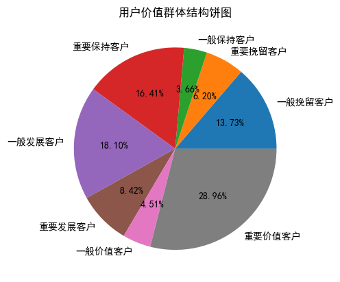

```python
"""用饼图展示用户占比"""
plt.pie(R_F_M_group_df['用户占比（%）'], autopct="%.2f%%", labels=["一般挽留客户","重要挽留客户","一般保持客户","重要保持客户","一般发展客户","重要发展客户","一般价值客户","重要价值客户"])
plt.title("用户价值群体结构饼图")
plt.show()
```

#### **8.1.7 小结**

1. 网店已积累坚实的核心用户基础：重要价值客户占比28.96%，一般价值客户占比4.51%
2. 高价值客户活跃度呈现衰退趋势：重要保持客户高达16.41%
3. 客户出现流失风险：重要保持客户（16.41%）与重要挽留客户（6.20%）总占比达22.61%，一般保持客户（3.66%）与一般挽留客户（13.73%）总占比达17.39%

### **8.2 产品精准推荐（Top5）**

#### **8.2.1 产品热度统计**

```python
"""总体产品热度"""
# 筛选出用户的所有“浏览、加购、购买”行为
total_view_cart_purchase_event = data_analysis[data_analysis["行为分类"].isin(["浏览","加入购物车","购买"])]
# 热度 = 浏览量 + 加购量 + 购买量
total_product_heat = total_view_cart_purchase_event.groupby("产品ID")["行为分类"].count().rename("总体产品热度")  # 根据“产品ID”进行分组，统计每组行为总数
total_product_heat
```

```
产品ID
10073    710
10075     82
10077    244
10078    184
10085      5
        ...
9813      69
9818      33
9822     187
9823     387
9825     723
Name: 总体产品热度, Length: 53675, dtype: int64
```

```python
"""重要价值客户产品热度"""
# 筛选出重要价值客户的所有“浏览、加购、购买”行为
high_value_view_cart_purchase_event = high_value_users_event[high_value_users_event["行为分类"].isin(["浏览","加入购物车","购买"])]
# 热度 = 浏览量 + 加购量 + 购买量
high_value_product_heat = high_value_view_cart_purchase_event.groupby("产品ID")["行为分类"].count().rename("重要价值客户产品热度")  # 根据“产品ID”进行分组，统计每组行为总数
high_value_product_heat
```

```
产品ID
10073    101
10075     18
10077     55
10078     64
10085      1
        ...
9813      10
9818       6
9822      34
9823      73
9825     130
Name: 重要价值客户产品热度, Length: 47600, dtype: int64
```

```python
"""一般价值客户产品热度"""
# 筛选出一般价值客户的所有“浏览、加购、购买”行为
average_value_view_cart_purchase_event = average_value_users_event[average_value_users_event["行为分类"].isin(["浏览","加入购物车","购买"])]
# 热度 = 浏览量 + 加购量 + 购买量
average_value_product_heat = average_value_view_cart_purchase_event.groupby("产品ID")["行为分类"].count().rename("一般价值客户产品热度")  # 根据“产品ID”进行分组，统计每组行为总数
average_value_product_heat
```

```
产品ID
10073    16
10077     9
10078     8
10090     3
10091     5
         ..
9209      3
9217      3
9813      2
9823     16
9825     22
Name: 一般价值客户产品热度, Length: 26888, dtype: int64
```

```python
"""重要发展客户产品热度"""
# 筛选出重要发展客户的所有“浏览、加购、购买”行为
high_potential_view_cart_purchase_event = high_potential_users_event[high_potential_users_event["行为分类"].isin(["浏览","加入购物车","购买"])]
# 热度 = 浏览量 + 加购量 + 购买量
high_potential_product_heat = high_potential_view_cart_purchase_event.groupby("产品ID")["行为分类"].count().rename("重要发展客户产品热度")  # 根据“产品ID”进行分组，统计每组行为总数
high_potential_product_heat
```

```
产品ID
10073    10
10075     2
10077     7
10078     1
10090     1
         ..
9219      2
9743     14
9813      2
9823      4
9825      9
Name: 重要发展客户产品热度, Length: 26548, dtype: int64
```

```python
"""一般发展客户产品热度"""
# 筛选出一般发展客户的所有“浏览、加购、购买”行为
average_potential_view_cart_purchase_event = average_potential_users_event[average_potential_users_event["行为分类"].isin(["浏览","加入购物车","购买"])]
# 热度 = 浏览量 + 加购量 + 购买量
average_potential_product_heat = average_potential_view_cart_purchase_event.groupby("产品ID")["行为分类"].count().rename("一般发展客户产品热度")  # 根据“产品ID”进行分组，统计每组行为总数
average_potential_product_heat
```

```
产品ID
10073    13
10077     6
10078     9
10090     4
10091     6
         ..
9743      1
9748      1
9822      1
9823     26
9825     16
Name: 一般发展客户产品热度, Length: 33162, dtype: int64
```

```python
"""重要保持客户产品热度"""
# 筛选出重要保持客户的所有“浏览、加购、购买”行为
high_retention_view_cart_purchase_event = high_retention_users_event[high_retention_users_event["行为分类"].isin(["浏览","加入购物车","购买"])]
# 热度 = 浏览量 + 加购量 + 购买量
high_retention_product_heat = high_retention_view_cart_purchase_event.groupby("产品ID")["行为分类"].count().rename("重要保持客户产品热度")  # 根据“产品ID”进行分组，统计每组行为总数
high_retention_product_heat
```

```
产品ID
10073     24
10075      7
10077     17
10078     11
10087      1
        ...
9813       2
9818       4
9822      44
9823      30
9825     120
Name: 重要保持客户产品热度, Length: 41670, dtype: int64
```

```python
"""一般保持客户产品热度"""
# 筛选出一般保持客户的所有“浏览、加购、购买”行为
average_retention_view_cart_purchase_event = average_retention_users_event[average_retention_users_event["行为分类"].isin(["浏览","加入购物车","购买"])]
# 热度 = 浏览量 + 加购量 + 购买量
average_retention_product_heat = average_retention_view_cart_purchase_event.groupby("产品ID")["行为分类"].count().rename("一般保持客户产品热度")  # 根据“产品ID”进行分组，统计每组行为总数
average_retention_product_heat
```

```
产品ID
10073    20
10075     3
10077     2
10087     6
10091     2
         ..
9812      3
9818      1
9822     11
9823      9
9825     58
Name: 一般保持客户产品热度, Length: 24072, dtype: int64
```

```python
"""重要挽留客户产品热度"""
# 筛选出重要挽留客户的所有“浏览、加购、购买”行为
high_retain_view_cart_purchase_event = high_retain_users_event[high_retain_users_event["行为分类"].isin(["浏览","加入购物车","购买"])]
# 热度 = 浏览量 + 加购量 + 购买量
high_retain_product_heat = high_retain_view_cart_purchase_event.groupby("产品ID")["行为分类"].count().rename("重要挽留客户产品热度")  # 根据“产品ID”进行分组，统计每组行为总数
high_retain_product_heat
```

```
产品ID
10073    1
10078    1
10090    1
10097    1
10106    6
        ..
9813     2
9818     3
9822     2
9823     4
9825     4
Name: 重要挽留客户产品热度, Length: 22725, dtype: int64
```

```python
"""一般挽留客户产品热度"""
# 筛选出一般挽留客户的所有“浏览、加购、购买”行为
average_retain_view_cart_purchase_event = average_retain_users_event[average_retain_users_event["行为分类"].isin(["浏览","加入购物车","购买"])]
# 热度 = 浏览量 + 加购量 + 购买量
average_retain_product_heat = average_retain_view_cart_purchase_event.groupby("产品ID")["行为分类"].count().rename("一般挽留客户产品热度")  # 根据“产品ID”进行分组，统计每组行为总数
average_retain_product_heat
```

```
产品ID
10073    11
10077     2
10078     3
10087     3
10090     2
         ..
9812      1
9813      1
9822      3
9823     13
9825     15
Name: 一般挽留客户产品热度, Length: 30518, dtype: int64
```

#### **8.2.2 熵权法计算函数**

```python
def entropy_weight_method(input_data, column_name, normalization=False):
    """
    输入参数：
        input_data：要计算权重的DataFrame对象【列名与 column_name 对应】
        column_name：要计算权重的列的列名【格式：["第一列列名,"第二列列名",...]】
        normalization：是否只进行归一化处理【是：True，否：False】【要用熵权法进行‘加权评分’时，需对原数据进行归一化】
    输出参数：
        weight_df：每一列的权重【是一个DataFrame对象】
    """
    '''数据归一化，消除量纲影响'''
    normalization_list = []  # 存放所有列的归一化结果数据
    # 循环处理 input_data 中的每一个列
    for i in column_name:
        column_data = input_data[i]  # 取到当前列数据
        min_data = column_data.min()  # 最小值
        max_data = column_data.max()  # 最大值
        if max_data == min_data:  # 如果最大值与最小值相等，会出现分母为0的情况
            normalization_data = pd.Series([0]*len(column_data)).rename(i)  # 把当前列全部变成 0，这样能使权重接近 0，不会报错
        else:  # 如果最大值与最小值不相等，可以正常计算归一化
            normalization_data = (column_data - min_data) / (max_data - min_data)  # 计算归一化值
        normalization_list.append(normalization_data)  # 将归一化结果放入汇总列表
    # 构建归一化数据表
    normalization_df = pd.DataFrame(normalization_list).T
    '''如果指定只进行归一化，则在此处结束函数返回归一化表格'''
    if normalization:  # 如果 normalization 设置为 True
        return normalization_df  # 直接返回归一化结果表格
    '''计算比重矩阵（概率）'''
    proportion_list = []  # 存放所有列的比重结果数据
    # 循环处理 normalization_df 中的每一个列
    for i in column_name:
        data_sum = normalization_df[i].sum()  # 数据总和
        data_p = normalization_df[i] / data_sum  # 数据比重 = 单个数据 / 全部数据的总和
        proportion_list.append(data_p)  # 将比重结果放入汇总列表
    # 构建比重矩阵
    proportion_df = pd.DataFrame(proportion_list).T
    '''计算熵值（信息熵）'''
    entropy_list = []  # 存放所有列的熵值计算结果数据
    # 循环处理 proportion_df 中的每一个列
    for i in column_name:
        data_len = len(proportion_df[i])  # 数据个数
        data_k = 1 / np.log(data_len)  # 熵值计算公式中的常数项【k = 1/log(data_len)】
        p = proportion_df[i].replace(0, 1e-12)  # 把所有的 0 替换成一个极小值 1e-12，避免 log(0) 出错
        data_e = -1 * data_k * (p * np.log(p)).sum()  # 计算信息熵
        entropy_list.append(data_e)  # 将熵值计算结果放入汇总列表
    # 构建熵值数据表
    entropy_df = pd.DataFrame(entropy_list).T
    '''计算权重'''
    weight_list = []  # 存放所有列的熵值计算结果数据
    # 循环处理 entropy_df 中的每一个列
    for i in range(len(column_name)):
        data_w = (1-entropy_df[i][0]) / (1-entropy_df).sum(axis=1).iloc[0]  # 计算权重
        weight_list.append(data_w)  # 将权重计算结果放入汇总列表
    # 构建权重数据表
    weight_df = pd.DataFrame(weight_list).T
    '''返回每列的权重'''
    return weight_df
```

#### **8.2.3 加权评分，筛选出最适合推荐的前5个产品**

##### **8.2.3.1 总体产品评分Top5**

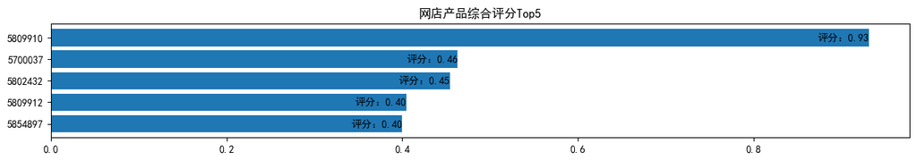

```python
"""计算产品评分"""
# 组合所有产品热度数据
store_product_heat = pd.DataFrame({
    "总体产品热度":total_product_heat,
    "重要价值客户产品热度":high_value_product_heat,
    "一般价值客户产品热度":average_value_product_heat,
    "重要发展客户产品热度":high_potential_product_heat,
    "一般发展客户产品热度":average_potential_product_heat,
    "重要保持客户产品热度":high_retention_product_heat,
    "一般保持客户产品热度":average_retention_product_heat,
    "重要挽留客户产品热度":high_retain_product_heat,
    "一般挽留客户产品热度":average_retain_product_heat
})
store_product_score = store_product_heat.fillna(0)  # 缺失值自动补0
# 计算权重
store_product_weight = entropy_weight_method(store_product_heat, ["总体产品热度","重要价值客户产品热度","一般价值客户产品热度","重要发展客户产品热度","一般发展客户产品热度","重要保持客户产品热度","一般保持客户产品热度","重要挽留客户产品热度","一般挽留客户产品热度"])
# 对原数据进行归一化处理
store_product_score_normalization = entropy_weight_method(store_product_score, ["总体产品热度","重要价值客户产品热度","一般价值客户产品热度","重要发展客户产品热度","一般发展客户产品热度","重要保持客户产品热度","一般保持客户产品热度","重要挽留客户产品热度","一般挽留客户产品热度"], normalization=True)
# 用归一化后的数据计算加权评分
store_product_score["产品评分"] = store_product_score_normalization["总体产品热度"] * store_product_weight[0][0]\
                                + store_product_score_normalization["重要价值客户产品热度"] * store_product_weight[1][0]\
                                + store_product_score_normalization["一般价值客户产品热度"] * store_product_weight[2][0]\
                                + store_product_score_normalization["重要发展客户产品热度"] * store_product_weight[3][0]\
                                + store_product_score_normalization["一般发展客户产品热度"] * store_product_weight[4][0]\
                                + store_product_score_normalization["重要保持客户产品热度"] * store_product_weight[5][0]\
                                + store_product_score_normalization["一般保持客户产品热度"] * store_product_weight[6][0]\
                                + store_product_score_normalization["重要挽留客户产品热度"] * store_product_weight[7][0]\
                                + store_product_score_normalization["一般挽留客户产品热度"] * store_product_weight[8][0]
store_product_score = store_product_score.sort_values(by="产品评分", ascending=False)  # 根据加权评分对产品进行排序
store_product_score = store_product_score.reset_index()  # 重置索引，得到产品ID
"""绘制横线条形图，直观展示产品评分"""
fig, axes = plt.subplots(1,1, figsize=(15,2))  # 子图图框
axes.barh(store_product_score["产品ID"][:5][::-1], store_product_score["产品评分"][:5][::-1])  # 横向条形图
axes.set_title("网店产品综合评分Top5")
for i,j in zip(store_product_score["产品ID"][:5][::-1], store_product_score["产品评分"][:5][::-1]):
    axes.text(j,i,f"评分：{j:.2f}", va="center", ha="right")  # 绘制具体数值
```

##### **8.2.3.2 重要价值客户产品评分Top5**

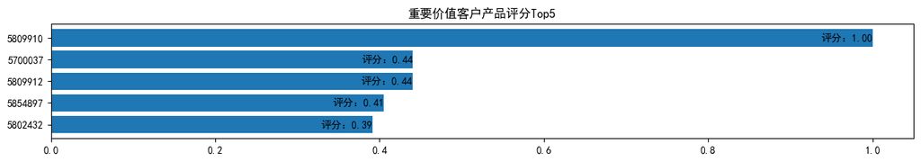

```python
"""计算产品评分"""
# 组合“总体产品热度”与“重要价值客户产品热度”数据【product_heat_all：总体产品热度】【high_value_product_heat：重要价值客户产品热度】
high_value_product_score = pd.merge(total_product_heat, high_value_product_heat, how='inner', on="产品ID")
# 计算权重
high_value_product_weight = entropy_weight_method(high_value_product_score, ["总体产品热度","重要价值客户产品热度"])
# 计算产品评分
high_value_product_score_normalization = entropy_weight_method(high_value_product_score, ["总体产品热度","重要价值客户产品热度"], normalization=True)  # 对原数据进行归一化处理
high_value_product_score["产品评分"] = high_value_product_score_normalization["总体产品热度"] * high_value_product_weight[0][0] + high_value_product_score_normalization["重要价值客户产品热度"] * high_value_product_weight[1][0]  # 用归一化后的数据计算加权评分
high_value_product_score = high_value_product_score.sort_values(by="产品评分", ascending=False)  # 根据加权评分对产品进行排序
high_value_product_score = high_value_product_score.reset_index()  # 重置索引，得到产品ID
"""绘制横线条形图，直观展示产品评分"""
fig, axes = plt.subplots(1,1, figsize=(15,2))  # 子图图框
axes.barh(high_value_product_score["产品ID"][:5][::-1], high_value_product_score["产品评分"][:5][::-1])  # 横向条形图
axes.set_title("重要价值客户产品评分Top5")
for i,j in zip(high_value_product_score["产品ID"][:5][::-1], high_value_product_score["产品评分"][:5][::-1]):
    axes.text(j,i,f"评分：{j:.2f}", va="center", ha="right")  # 绘制具体数值
```

##### **8.2.3.3 一般价值客户产品评分Top5**

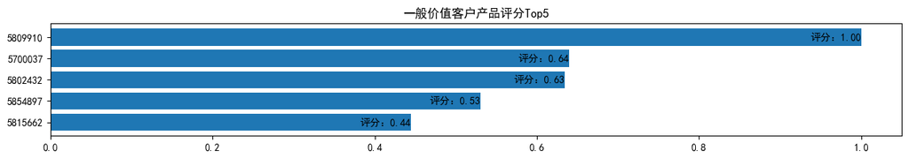

```python
"""计算产品评分"""
# 组合“总体产品热度”与“一般价值客户产品热度”数据【product_heat_all：总体产品热度】【average_value_product_heat：一般价值客户产品热度】
average_value_product_score = pd.merge(total_product_heat, average_value_product_heat, how='inner', on="产品ID")
# 计算权重
average_value_product_weight = entropy_weight_method(average_value_product_score, ["总体产品热度","一般价值客户产品热度"])
# 计算产品评分
average_value_product_score_normalization = entropy_weight_method(average_value_product_score, ["总体产品热度","一般价值客户产品热度"], normalization=True)  # 对原数据进行归一化处理
average_value_product_score["产品评分"] = average_value_product_score_normalization["总体产品热度"] * average_value_product_weight[0][0] + average_value_product_score_normalization["一般价值客户产品热度"] * average_value_product_weight[1][0]  # 用归一化后的数据计算加权评分
average_value_product_score = average_value_product_score.sort_values(by="产品评分", ascending=False)  # 根据加权评分对产品进行排序
average_value_product_score = average_value_product_score.reset_index()  # 重置索引，得到产品ID
"""绘制横线条形图，直观展示产品评分"""
fig, axes = plt.subplots(1,1, figsize=(15,2))  # 子图图框
axes.barh(average_value_product_score["产品ID"][:5][::-1], average_value_product_score["产品评分"][:5][::-1])  # 横向条形图
axes.set_title("一般价值客户产品评分Top5")
for i,j in zip(average_value_product_score["产品ID"][:5][::-1], average_value_product_score["产品评分"][:5][::-1]):
    axes.text(j,i,f"评分：{j:.2f}", va="center", ha="right")  # 绘制具体数值
```

##### **8.2.3.4 重要发展客户产品评分Top5**

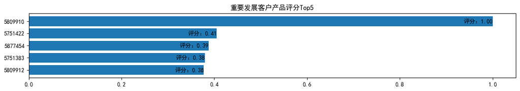

```python
"""计算产品评分"""
# 组合“总体产品热度”与“重要发展客户产品热度”数据【product_heat_all：总体产品热度】【high_potential_product_heat：重要发展客户产品热度】
high_potential_product_score = pd.merge(total_product_heat, high_potential_product_heat, how='inner', on="产品ID")
# 计算权重
high_potential_product_weight = entropy_weight_method(high_potential_product_score, ["总体产品热度","重要发展客户产品热度"])
# 计算产品评分
high_potential_product_score_normalization = entropy_weight_method(high_potential_product_score, ["总体产品热度","重要发展客户产品热度"], normalization=True)  # 对原数据进行归一化处理
high_potential_product_score["产品评分"] = high_potential_product_score_normalization["总体产品热度"] * high_potential_product_weight[0][0] + high_potential_product_score_normalization["重要发展客户产品热度"] * high_potential_product_weight[1][0]  # 用归一化后的数据计算加权评分
high_potential_product_score = high_potential_product_score.sort_values(by="产品评分", ascending=False)  # 根据加权评分对产品进行排序
high_potential_product_score = high_potential_product_score.reset_index()  # 重置索引，得到产品ID
"""绘制横线条形图，直观展示产品评分"""
fig, axes = plt.subplots(1,1, figsize=(15,2))  # 子图图框
axes.barh(high_potential_product_score["产品ID"][:5][::-1], high_potential_product_score["产品评分"][:5][::-1])  # 横向条形图
axes.set_title("重要发展客户产品评分Top5")
for i,j in zip(high_potential_product_score["产品ID"][:5][::-1], high_potential_product_score["产品评分"][:5][::-1]):
    axes.text(j,i,f"评分：{j:.2f}", va="center", ha="right")  # 绘制具体数值
```

##### **8.2.3.5 一般发展客户产品评分Top5**

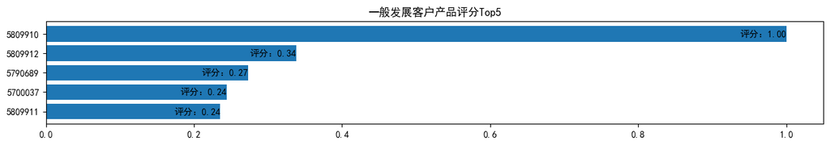

```python
"""计算产品评分"""
# 组合“总体产品热度”与“一般发展客户产品热度”数据【product_heat_all：总体产品热度】【average_potential_product_heat：一般发展客户产品热度】
average_potential_product_score = pd.merge(total_product_heat, average_potential_product_heat, how='inner', on="产品ID")
# 计算权重
average_potential_product_weight = entropy_weight_method(average_potential_product_score, ["总体产品热度","一般发展客户产品热度"])
# 计算产品评分
average_potential_product_score_normalization = entropy_weight_method(average_potential_product_score, ["总体产品热度","一般发展客户产品热度"], normalization=True)  # 对原数据进行归一化处理
average_potential_product_score["产品评分"] = average_potential_product_score_normalization["总体产品热度"] * average_potential_product_weight[0][0] + average_potential_product_score_normalization["一般发展客户产品热度"] * average_potential_product_weight[1][0]  # 用归一化后的数据计算加权评分
average_potential_product_score = average_potential_product_score.sort_values(by="产品评分", ascending=False)  # 根据加权评分对产品进行排序
average_potential_product_score = average_potential_product_score.reset_index()  # 重置索引，得到产品ID
"""绘制横线条形图，直观展示产品评分"""
fig, axes = plt.subplots(1,1, figsize=(15,2))  # 子图图框
axes.barh(average_potential_product_score["产品ID"][:5][::-1], average_potential_product_score["产品评分"][:5][::-1])  # 横向条形图
axes.set_title("一般发展客户产品评分Top5")
for i,j in zip(average_potential_product_score["产品ID"][:5][::-1], average_potential_product_score["产品评分"][:5][::-1]):
    axes.text(j,i,f"评分：{j:.2f}", va="center", ha="right")  # 绘制具体数值
```

##### **8.2.3.6 重要保持客户产品评分Top5**

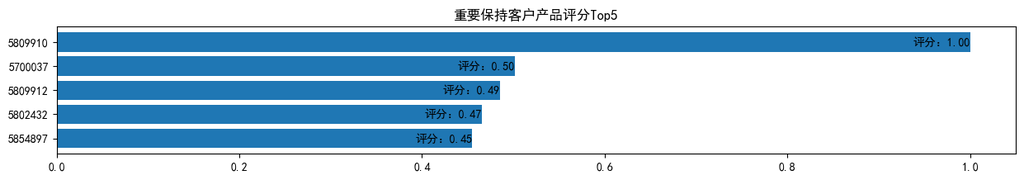

```python
"""计算产品评分"""
# 组合“总体产品热度”与“重要保持客户产品热度”数据【product_heat_all：总体产品热度】【high_retention_product_heat：重要保持客户产品热度】
high_retention_product_score = pd.merge(total_product_heat, high_retention_product_heat, how='inner', on="产品ID")
# 计算权重
high_retention_product_weight = entropy_weight_method(high_retention_product_score, ["总体产品热度","重要保持客户产品热度"])
# 计算产品评分
high_retention_product_score_normalization = entropy_weight_method(high_retention_product_score, ["总体产品热度","重要保持客户产品热度"], normalization=True)  # 对原数据进行归一化处理
high_retention_product_score["产品评分"] = high_retention_product_score_normalization["总体产品热度"] * high_retention_product_weight[0][0] + high_retention_product_score_normalization["重要保持客户产品热度"] * high_retention_product_weight[1][0]  # 用归一化后的数据计算加权评分
high_retention_product_score = high_retention_product_score.sort_values(by="产品评分", ascending=False)  # 根据加权评分对产品进行排序
high_retention_product_score = high_retention_product_score.reset_index()  # 重置索引，得到产品ID
"""绘制横线条形图，直观展示产品评分"""
fig, axes = plt.subplots(1,1, figsize=(15,2))  # 子图图框
axes.barh(high_retention_product_score["产品ID"][:5][::-1], high_retention_product_score["产品评分"][:5][::-1])  # 横向条形图
axes.set_title("重要保持客户产品评分Top5")
for i,j in zip(high_retention_product_score["产品ID"][:5][::-1], high_retention_product_score["产品评分"][:5][::-1]):
    axes.text(j,i,f"评分：{j:.2f}", va="center", ha="right")  # 绘制具体数值
```

##### **8.2.3.7 一般保持客户产品评分Top5**

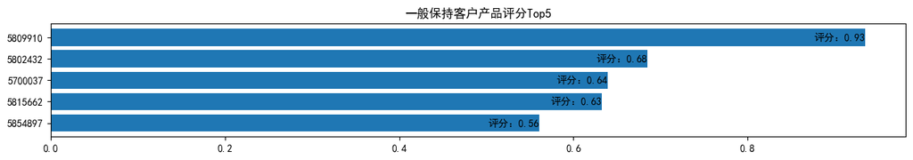

```python
"""计算产品评分"""
# 组合“总体产品热度”与“一般保持客户产品热度”数据【product_heat_all：总体产品热度】【average_retention_product_heat：一般保持客户产品热度】
average_retention_product_score = pd.merge(total_product_heat, average_retention_product_heat, how='inner', on="产品ID")
# 计算权重
average_retention_product_weight = entropy_weight_method(average_retention_product_score, ["总体产品热度","一般保持客户产品热度"])
# 计算产品评分
average_retention_product_score_normalization = entropy_weight_method(average_retention_product_score, ["总体产品热度","一般保持客户产品热度"], normalization=True)  # 对原数据进行归一化处理
average_retention_product_score["产品评分"] = average_retention_product_score_normalization["总体产品热度"] * average_retention_product_weight[0][0] + average_retention_product_score_normalization["一般保持客户产品热度"] * average_retention_product_weight[1][0]  # 用归一化后的数据计算加权评分
average_retention_product_score = average_retention_product_score.sort_values(by="产品评分", ascending=False)  # 根据加权评分对产品进行排序
average_retention_product_score = average_retention_product_score.reset_index()  # 重置索引，得到产品ID
"""绘制横线条形图，直观展示产品评分"""
fig, axes = plt.subplots(1,1, figsize=(15,2))  # 子图图框
axes.barh(average_retention_product_score["产品ID"][:5][::-1], average_retention_product_score["产品评分"][:5][::-1])  # 横向条形图
axes.set_title("一般保持客户产品评分Top5")
for i,j in zip(average_retention_product_score["产品ID"][:5][::-1], average_retention_product_score["产品评分"][:5][::-1]):
    axes.text(j,i,f"评分：{j:.2f}", va="center", ha="right")  # 绘制具体数值
```

##### **8.2.3.8 重要挽留客户产品评分Top5**

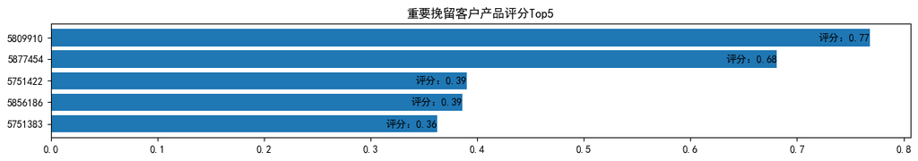

```python
"""计算产品评分"""
# 组合“总体产品热度”与“重要挽留客户产品热度”数据【product_heat_all：总体产品热度】【high_retain_product_heat：重要挽留客户产品热度】
high_retain_product_score = pd.merge(total_product_heat, high_retain_product_heat, how='inner', on="产品ID")
# 计算权重
high_retain_product_weight = entropy_weight_method(high_retain_product_score, ["总体产品热度","重要挽留客户产品热度"])
# 计算产品评分
high_retain_product_score_normalization = entropy_weight_method(high_retain_product_score, ["总体产品热度","重要挽留客户产品热度"], normalization=True)  # 对原数据进行归一化处理
high_retain_product_score["产品评分"] = high_retain_product_score_normalization["总体产品热度"] * high_retain_product_weight[0][0] + high_retain_product_score_normalization["重要挽留客户产品热度"] * high_retain_product_weight[1][0]  # 用归一化后的数据计算加权评分
high_retain_product_score = high_retain_product_score.sort_values(by="产品评分", ascending=False)  # 根据加权评分对产品进行排序
high_retain_product_score = high_retain_product_score.reset_index()  # 重置索引，得到产品ID
"""绘制横线条形图，直观展示产品评分"""
fig, axes = plt.subplots(1,1, figsize=(15,2))  # 子图图框
axes.barh(high_retain_product_score["产品ID"][:5][::-1], high_retain_product_score["产品评分"][:5][::-1])  # 横向条形图
axes.set_title("重要挽留客户产品评分Top5")
for i,j in zip(high_retain_product_score["产品ID"][:5][::-1], high_retain_product_score["产品评分"][:5][::-1]):
    axes.text(j,i,f"评分：{j:.2f}", va="center", ha="right")  # 绘制具体数值
```

##### **8.2.3.9 一般挽留客户产品评分Top5**

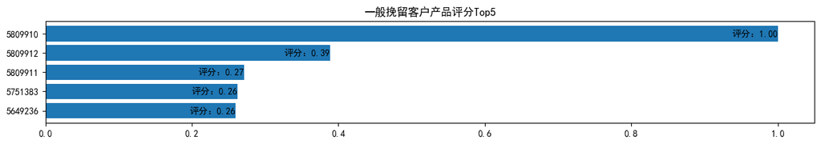

```python
"""计算产品评分"""
# 组合“总体产品热度”与“一般挽留客户产品热度”数据【product_heat_all：总体产品热度】【average_retain_product_heat：一般挽留客户产品热度】
average_retain_product_score = pd.merge(total_product_heat, average_retain_product_heat, how='inner', on="产品ID")
# 计算权重
average_retain_product_weight = entropy_weight_method(average_retain_product_score, ["总体产品热度","一般挽留客户产品热度"])
# 计算产品评分
average_retain_product_score_normalization = entropy_weight_method(average_retain_product_score, ["总体产品热度","一般挽留客户产品热度"], normalization=True)  # 对原数据进行归一化处理
average_retain_product_score["产品评分"] = average_retain_product_score_normalization["总体产品热度"] * average_retain_product_weight[0][0] + average_retain_product_score_normalization["一般挽留客户产品热度"] * average_retain_product_weight[1][0]  # 用归一化后的数据计算加权评分
average_retain_product_score = average_retain_product_score.sort_values(by="产品评分", ascending=False)  # 根据加权评分对产品进行排序
average_retain_product_score = average_retain_product_score.reset_index()  # 重置索引，得到产品ID
"""绘制横线条形图，直观展示产品评分"""
fig, axes = plt.subplots(1,1, figsize=(15,2))  # 子图图框
axes.barh(average_retain_product_score["产品ID"][:5][::-1], average_retain_product_score["产品评分"][:5][::-1])  # 横向条形图
axes.set_title("一般挽留客户产品评分Top5")
for i,j in zip(average_retain_product_score["产品ID"][:5][::-1], average_retain_product_score["产品评分"][:5][::-1]):
    axes.text(j,i,f"评分：{j:.2f}", va="center", ha="right")  # 绘制具体数值
```

#### **8.2.4 小结**

1. 全网店综合评分Top5产品：5809910、5700037、5802432、5809912、5854897
2. 重要价值客户综合评分Top5产品：5809910、5700037、5809912、5854897、5802432
3. 一般价值客户综合评分Top5产品：5809910、5700037、5802432、5854897、5815662
4. 重要发展客户综合评分Top5产品：5809910、5751422、5877454、5751383、5809912
5. 一般发展客户综合评分Top5产品：5809910、5809912、5790689、5700037、5809911
6. 重要保持客户综合评分Top5产品：5809910、5700037、5809912、5802432、5854897
7. 一般保持客户综合评分Top5产品：5809910、5802432、5700037、5815662、5854897
8. 重要挽留客户综合评分Top5产品：5809910、5877454、5751422、5856186、5751383
9. 一般挽留客户综合评分Top5产品：5809910、5809912、5809911、5751383、5649236

## **9 总结与建议**

1. 用户倾向于关注14.61美元以内的低价产品，整体产品最高价格达到327.78美元，但价格分布上界仅14.61美元，建议网店将核心资源与运营精力聚焦于14.61美元以下的产品，以精准匹配用户需求，并将低价产品与相关的中、高价产品捆绑推荐，引导用户关注更高价格产品，从而提升客单价
2. 产品类别及品牌均表现出显著的头部集聚效应，产品类别受关注度与品牌受关注度均呈“三级阶梯+平滑长尾”的分布形态，上架新产品时建议优先上架头部品牌与头部类别产品
   1. 头部类别：1487580007675986893、1487580005092295511、1487580005595612013、1487580005671109489、1602943681873052386、1487580006317032337
   2. 头部品牌：runail、irisk、grattol、masura
3. 跨年前后一周用户行为总量跌入谷底，建议降低该时段推广投入以避免预算浪费，同时利用低峰期完成产品页面维护与更新，从而减少正常运营时段的维护成本
4. 大型活动开启前一个月适合开展预热活动，“2019年10月1日-12日”的加购行为能显著促进用户在“2019年11月20日-12月1日”的购买转化（2019年感恩节为11月28日、黑色星期五为11月29日）
5. 网店产品购物车移出率普遍偏高，主要归因于“用户批量清除购物车”与“受竞品影响放弃原产品”两大核心因素。针对前者，建议增加“批量删除”的二次确认或撤销功能，以降低误操作风险；针对后者，建议在用户加购时，智能展示产品的核心卖点或推送限时优惠，通过强化产品优势来增强用户快速购买意愿
6. 鉴于不同用户群体的关注点与需求存在显著差异，为精准触达用户并有效提升购买转化率，建议针对各类客户群体推荐最优产品。建议推荐清单如下：
   1. 没有过购买行为的客户：5809910、5700037、5802432、5809912、5854897
   2. 重要价值客户：5809910、5700037、5809912、5854897、5802432
   3. 一般价值客户：5809910、5700037、5802432、5854897、5815662
   4. 重要发展客户：5809910、5751422、5877454、5751383、5809912
   5. 一般发展客户：5809910、5809912、5790689、5700037、5809911
   6. 重要保持客户：5809910、5700037、5809912、5802432、5854897
   7. 一般保持客户：5809910、5802432、5700037、5815662、5854897
   8. 重要挽留客户：5809910、5877454、5751422、5856186、5751383
   9. 一般挽留客户：5809910、5809912、5809911、5751383、5649236